# Ficha de Información Metropolitana

Universidad Autónoma Metropolitnana

Lic. Martínez Rodriguez, Alvaro[^1]

Lic. Pérez Victorino, Leonardo[^2]

La ficha de información metropolitana es una herramienta valiosa para la planificación territorial en zonas metropolitanas (ZM). Proporciona información censal en diferentes formatos, como gráficos, tablas y mapas, tanto de los Censos de Población y Vivienda, 2020 (CPV2020) como de los Censos Económicos de 1999, 2004, 2009, 2014 y 2019. Ambos publicados por el Instituto Nacional de Estadística y Geografía (INEGI).

## Información general de la Zona Metropolitana de Xalapa

Según (Sedatu 2018), la zona metropolitana se define como un área urbana que consta de una ciudad principal y su zona conurbada. Las zonas metropolitanas se caracterizan por tener una alta densidad de población y estar interconectadas por vías de transporte y comunicación. La zona metropolitana de Xalapa, se localiza en Veracruz de Ignacio de la Llave. y esta compuesta por 9 municipios, que se muestran a continuación:

| Nombre | Clave |
| --- | --- |
| Banderilla | 30026 |
| Coacoatzintla | 30036 |
| Coatepec | 30038 |
| Emiliano Zapata | 30065 |
| Xalapa | 30087 |
| Xico | 30092 |
| Jilotepec | 30093 |
| Rafael Lucio | 30136 |
| Tlalnelhuayocan | 30182 |

Municipios de la zona metropolitana

Además, se presenta un mapa de la zona metropolitana:

[interactive chart not shown]

A continuación se presentan algunos datos generales sobre esta zona:

- Zona Metropolitana:Xalapa
- Número de municipios: 9
- Población total: 789,157
- Superficie de la ZM: 1,083.53 [m^2]
- Densidad poblacional: 728.32 [1/m^2] Hab/Km^2.
- Grado promedio de escolaridad: 9.0866667

## Información sociodemográfica

La estructura de población de la zona metropolitana de Xalapa se presenta en la una piramide poblacional ya que permite obtener una visión general de la distribución de la población por género y edad:

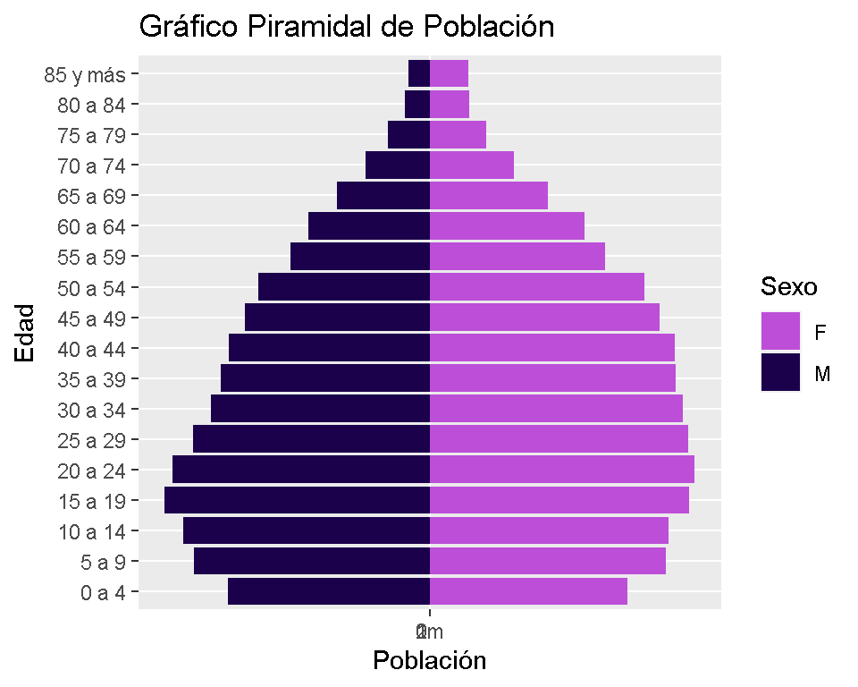

En el siguiente mapa se observa como se distribuye la población sobre la región:

[interactive chart not shown]

### Vivienda

El CPV 2020 también proporciona información sobre la vivienda en la zona metropolitana, a continuación se presentan los principales resultados:

- Número de viviendas habitadas: 238419
- Porcentaje de viviendas desocupadas:17%
- Promedio de ocupantes por vivienda: 3.594
- Promedio de ocupantes por cuarto:0.9855556
- Porcentaje de viviendas con servicios básicos:97%
- Porcentaje de viviendas sin bienes2: 1%
- Porcentaje de ocupantes en viviendas particulares que disponen de energía eléctrica, agua entubada y drenaje: 1%

### Socioeconómicos

La población en terminos de la poblacioón economicamente activa esta descrita por:

- Porcentaje de población de 12 años y más económicamente activa: 52%
- Porcentaje de población de 12 años y más no económicamente activa: 31% `

### Educación

La educación de la zona metropolitana esta caracterizada por los siguientes estadísticos:

- Porcentaje de población de 15 años y más sin escolaridad:3%
- Porcentaje de población de 15 años y más con al menos un grado aprobado en primaria: 69%
- Porcentaje de población de 15 años y más con educación básica completa: 14%
- Porcentaje de población de 15 años y más con secundaria o equivalente incompleta:2%
- Porcentaje de población de 18 años y más con al menos un grado aprobado en educación media superior: 41%

### Salud

La situación de la afiliación a algún servico de salud es la siguiente:

- Porcentaje de población afiliada a servicios de salud: 72%
- Población sin afiliación a servicios de salud:221418

### Indicadores de desarrollo

Finalmente se presentan tres indicadores de desarrollo; los índices son: índice de Desarrollo Humano (IDH), Índice de Marginación (IM) e Índice de Rezago Social (IRS).

IDH es un indicador elaborado por el Programa de Naciones Unidas para el Desarrollo (PNUD), este busca medir la calidad de vida, así como el progreso socioeconómico de cada entidad y municipio; El cálculo del Índice de Desarrollo Humano se realiza a partir de las tres variables: esperanza de vida, educación e ingreso per cápita.

- Muy Alto - IDH mayor de 1.
- Alto - IDH entre 0.80 a 1.
- Medio - IDH entre 0.50 y 0.80.
- Bajo - IDH entre 0 y 0.50
- Muy Bajo - IDH menores a 0.
- El promedio del IDH en 2020 para la zona metropolitana es de 0.738 según datos del PNUD.

El IM es un índice construido por el consejo Nacional de Población (CONAPO). Este índice considera 4 dimensiones estructurales para su construcción: vivienda, ingreso, educación y distribución de la población. El indice se puede ubicar en 5 estratos designados por la ténica de estratificación de Dalenius-Hodges..

- Muy bajo (-1.52944, -1.15143)
- Bajo (-1.15143, -0.39539)
- Medio (-0.39539, -0.01738)
- Alto (-0.01738, 0.73866)
- Muy alto (0.738660, 2.25073)
- El promedio del IM en 2020 para la zona metropolitana es de 56.5 según datos del CONAPO.

Por último, el IRS es construido por el Consejo Nacional de Evaluación de la Política de Desarrollo Social, CONEVAL, este índice incorpora indicadores de educación, de acceso a servicios de salud, de servicios básicos y tiene como finalidad ordenar los municipios según sus carencias sociales. Este índice, al igual que el IM, se clasifica en cinco estratos.

## Datos económicos.

Con base en la información de los subsectores de los 21 sectores principales de la clasificación del SCIAN, extraída de los Censos Económicos del INEGI durante el periodo de 1998-2018, se ha llevado a cabo la agrupación de los datos de cada municipio que pertenece a una zona metropolitana en cinco grandes sectores: Primarios, Construcción, Manufactura, Comercio y Servicios. Esta clasificación se basa en la metodología proporcionada por el INEGI. Se utilizaron las siguientes variables:

- Unidades económicas (UE) [número de unidades]
- Activiso fijos totales (AF) [miles de pesos a precios corrientes]
- Formación bruta de capital fijo (FB) [miles de pesos a precios corrientes]
- Producción bruta total (PB) [miles de pesos a precios corrientes]
- Personal ocupado total (PO) [número de personas]
- Total de remuneraciones (RE) [miles de pesos a precios corrientes]
- Valor agregado censal bruto (VA) [miles de pesos a precios corrientes]

Posteriormente, se replica la metodología utilizada por García y Carranco (2008) para estimar los coeficientes de participación relativa (PR), de localización de la actividad económica (QL), Hirschman-Herfindahl (HH) e Inverso de Hirschman-Herfindahl (IHH).

$PR_ij$=$X_ij/X_in$

$QL_ij$=$(X_ij⁄X_j )/(X_in⁄X_n)$

$HH_ij$=$X_ij/X_in - X_j/X_n$

$IHH_ij$=$1/(X_ij/X_in - X_j/X_n)$

Donde:

- $X_ij$= Variable económica del sector i en el municipio j
- $X_j$= Variable económica del total de los sectores en el municipio j
- $X_in$= Variable económica del sector i de la Zona Metropolitana del municipio j
- $X_n$= Variable económica del total de los sectores de la Zona Metropolitana del municipio j

### Cifras brutas

#### 1999

##### UE

| Clave | Municipio | Primarios | Construcción | Manufactura | Comercio | Servicios |
| --- | --- | --- | --- | --- | --- | --- |
| 30026 | Banderilla | 0 | 0 | 54 | 197 | 150 |
| 30036 | Coacoatzintla | 0 | 0 | 11 | 58 | 0 |
| 30038 | Coatepec | 0 | 0 | 352 | 1,151 | 779 |
| 30065 | Emiliano Zapata | 0 | 0 | 87 | 243 | 99 |
| 30087 | Xalapa | 0 | 97 | 1,636 | 6,793 | 6,370 |
| 30092 | Xico | 0 | 0 | 112 | 321 | 59 |
| 30093 | Jilotepec | 0 | 0 | 12 | 63 | 37 |
| 30136 | Rafael Lucio | 0 | 0 | 15 | 0 | 0 |
| 30182 | Tlalnelhuayocan | 0 | 0 | 7 | 0 | 0 |

##### AF

| Clave | Municipio | Primarios | Construcción | Manufactura | Comercio | Servicios |
| --- | --- | --- | --- | --- | --- | --- |
| 30026 | Banderilla | 647 | 1,815 | 87,556 | 21,682 | 18,259 |
| 30036 | Coacoatzintla | 0 | 0 | 1,083 | 4,070 | 3,302 |
| 30038 | Coatepec | 1,935 | 22,399 | 602,140 | 43,469 | 97,746 |
| 30065 | Emiliano Zapata | 5 | 0 | 14,416 | 16,317 | 24,139 |
| 30087 | Xalapa | 2,534 | 101,383 | 244,030 | 679,816 | 73,830,864 |
| 30092 | Xico | 0 | 0 | 13,742 | 8,290 | 14,865 |
| 30093 | Jilotepec | 0 | 0 | 30,913 | 1,469 | 2,866 |
| 30136 | Rafael Lucio | 0 | 0 | 735 | 1,647 | 2,664 |
| 30182 | Tlalnelhuayocan | 0 | 0 | 383 | 1,226 | 2,050 |

##### FB

| Clave | Municipio | Primarios | Construcción | Manufactura | Comercio | Servicios |
| --- | --- | --- | --- | --- | --- | --- |
| 30026 | Banderilla | 0 | 76 | 2,026 | 624 | 896 |
| 30036 | Coacoatzintla | 0 | 0 | 0 | 7 | 1,003 |
| 30038 | Coatepec | 0 | 7 | 32,617 | 1,442 | 3,676 |
| 30065 | Emiliano Zapata | 2 | 0 | -6,057 | 523 | 1,911 |
| 30087 | Xalapa | 58 | 22,207 | 16,407 | 49,559 | 1,293,417 |
| 30092 | Xico | 0 | 0 | 2,837 | 311 | 1,444 |
| 30093 | Jilotepec | 0 | 0 | 3,388 | 4 | 172 |
| 30136 | Rafael Lucio | 0 | 0 | 41 | 10 | -4 |
| 30182 | Tlalnelhuayocan | 0 | 0 | 16 | 17 | 547 |

##### PB

| Clave | Municipio | Primarios | Construcción | Manufactura | Comercio | Servicios |
| --- | --- | --- | --- | --- | --- | --- |
| 30026 | Banderilla | 180 | 1,994 | 39,994 | 30,536 | 16,683 |
| 30036 | Coacoatzintla | 0 | 0 | 2,171 | 6,409 | 705 |
| 30038 | Coatepec | 13,233 | 684,784 | 2,415,155 | 131,241 | 105,745 |
| 30065 | Emiliano Zapata | 38 | 0 | 224,445 | 30,926 | 14,661 |
| 30087 | Xalapa | 3,269 | 444,445 | 1,153,107 | 1,744,542 | 9,917,211 |
| 30092 | Xico | 0 | 0 | 224,175 | 10,362 | 15,580 |
| 30093 | Jilotepec | 0 | 0 | 125,828 | 2,054 | 1,702 |
| 30136 | Rafael Lucio | 0 | 0 | 2,156 | 603 | 194 |
| 30182 | Tlalnelhuayocan | 0 | 0 | 966 | 1,439 | 9,018 |

##### PO

| Clave | Municipio | Primarios | Construcción | Manufactura | Comercio | Servicios |
| --- | --- | --- | --- | --- | --- | --- |
| 30026 | Banderilla | 4 | 23 | 182 | 584 | 415 |
| 30036 | Coacoatzintla | 0 | 0 | 48 | 97 | 30 |
| 30038 | Coatepec | 20 | 73 | 2,377 | 2,146 | 2,261 |
| 30065 | Emiliano Zapata | 2 | 0 | 668 | 454 | 403 |
| 30087 | Xalapa | 26 | 4,597 | 6,080 | 18,348 | 31,112 |
| 30092 | Xico | 0 | 0 | 270 | 547 | 376 |
| 30093 | Jilotepec | 0 | 0 | 345 | 99 | 81 |
| 30136 | Rafael Lucio | 0 | 0 | 43 | 52 | 27 |
| 30182 | Tlalnelhuayocan | 0 | 0 | 22 | 112 | 139 |

##### RE

| Clave | Municipio | Primarios | Construcción | Manufactura | Comercio | Servicios |
| --- | --- | --- | --- | --- | --- | --- |
| 30026 | Banderilla | 22 | 158 | 3,790 | 8,011 | 2,614 |
| 30036 | Coacoatzintla | 0 | 0 | 121 | 554 | 81 |
| 30038 | Coatepec | 276 | 1,228 | 125,533 | 14,693 | 18,149 |
| 30065 | Emiliano Zapata | 0 | 0 | 7,822 | 2,444 | 1,581 |
| 30087 | Xalapa | 709 | 56,178 | 74,365 | 274,101 | 1,803,159 |
| 30092 | Xico | 0 | 0 | 1,478 | 680 | 1,761 |
| 30093 | Jilotepec | 0 | 0 | 21,834 | 124 | 507 |
| 30136 | Rafael Lucio | 0 | 0 | 53 | 0 | 31 |
| 30182 | Tlalnelhuayocan | 0 | 0 | 70 | 78 | 5,194 |

##### VA

| Clave | Municipio | Primarios | Construcción | Manufactura | Comercio | Servicios |
| --- | --- | --- | --- | --- | --- | --- |
| 30026 | Banderilla | 43 | 223 | 14,601 | 18,048 | 6,674 |
| 30036 | Coacoatzintla | 0 | 0 | 503 | 5,603 | -876 |
| 30038 | Coatepec | 3,513 | 209,747 | 849,365 | 106,820 | 50,347 |
| 30065 | Emiliano Zapata | 33 | 0 | 56,753 | 24,719 | 6,607 |
| 30087 | Xalapa | 1,878 | 107,607 | 222,689 | 1,285,675 | 4,984,166 |
| 30092 | Xico | 0 | 0 | 6,293 | 8,739 | 2,306 |
| 30093 | Jilotepec | 0 | 0 | 33,058 | 1,705 | 585 |
| 30136 | Rafael Lucio | 0 | 0 | 756 | 535 | -893 |
| 30182 | Tlalnelhuayocan | 0 | 0 | 269 | 1,048 | 87 |

#### 2004

##### UE

| Clave | Municipio | Primarios | Construcción | Manufactura | Comercio | Servicios |
| --- | --- | --- | --- | --- | --- | --- |
| 30026 | Banderilla | 0 | 0 | 52 | 297 | 135 |
| 30036 | Coacoatzintla | 0 | 0 | 35 | 94 | 39 |
| 30038 | Coatepec | 0 | 0 | 267 | 1,348 | 737 |
| 30065 | Emiliano Zapata | 0 | 0 | 44 | 283 | 84 |
| 30087 | Xalapa | 0 | 85 | 1,515 | 7,530 | 6,511 |
| 30092 | Xico | 0 | 0 | 128 | 454 | 102 |
| 30093 | Jilotepec | 0 | 0 | 25 | 71 | 52 |
| 30136 | Rafael Lucio | 0 | 0 | 14 | 38 | 0 |
| 30182 | Tlalnelhuayocan | 0 | 0 | 8 | 44 | 4 |

##### AF

| Clave | Municipio | Primarios | Construcción | Manufactura | Comercio | Servicios |
| --- | --- | --- | --- | --- | --- | --- |
| 30026 | Banderilla | 0 | 41,276 | 47,017 | 60,389 | 121,633 |
| 30036 | Coacoatzintla | 0 | 0 | 2,487 | 4,901 | 14,054 |
| 30038 | Coatepec | 0 | 9,132 | 1,755,619 | 131,044 | 230,307 |
| 30065 | Emiliano Zapata | 7 | 3,431 | 36,918 | 89,911 | 29,036 |
| 30087 | Xalapa | 6,039 | 191,332 | 424,433 | 1,287,392 | 4,434,038 |
| 30092 | Xico | 0 | 15 | 19,105 | 17,197 | 34,858 |
| 30093 | Jilotepec | 0 | 0 | 1,971 | 3,004 | 5,716 |
| 30136 | Rafael Lucio | 0 | 0 | 2,005 | 4,467 | 3,849 |
| 30182 | Tlalnelhuayocan | 0 | 0 | 662 | 1,097 | 7,778 |

##### FB

| Clave | Municipio | Primarios | Construcción | Manufactura | Comercio | Servicios |
| --- | --- | --- | --- | --- | --- | --- |
| 30026 | Banderilla | 0 | 4 | 3,559 | 1,739 | 1,779 |
| 30036 | Coacoatzintla | 0 | 0 | 146 | 108 | 760 |
| 30038 | Coatepec | 0 | 2,477 | 97,561 | 8,570 | 18,469 |
| 30065 | Emiliano Zapata | 0 | 3,431 | 3,504 | 27,328 | 1,054 |
| 30087 | Xalapa | 0 | 23,942 | 20,004 | 84,610 | 175,934 |
| 30092 | Xico | 0 | 15 | 1,271 | 541 | 5,289 |
| 30093 | Jilotepec | 0 | 0 | 16 | 122 | 192 |
| 30136 | Rafael Lucio | 0 | 0 | 94 | 8 | 1 |
| 30182 | Tlalnelhuayocan | 0 | 0 | 25 | 75 | 1,063 |

##### PB

| Clave | Municipio | Primarios | Construcción | Manufactura | Comercio | Servicios |
| --- | --- | --- | --- | --- | --- | --- |
| 30026 | Banderilla | 0 | 51,522 | 64,408 | 301,660 | 96,012 |
| 30036 | Coacoatzintla | 0 | 0 | 5,280 | 6,815 | 3,676 |
| 30038 | Coatepec | 0 | 27,868 | 5,240,931 | 218,972 | 356,872 |
| 30065 | Emiliano Zapata | 92 | 2,131 | 223,646 | 207,746 | 33,990 |
| 30087 | Xalapa | 3,941 | 821,561 | 1,512,840 | 3,347,558 | 4,827,803 |
| 30092 | Xico | 0 | 94 | 64,204 | 21,837 | 33,070 |
| 30093 | Jilotepec | 0 | 0 | 4,757 | 3,917 | 6,465 |
| 30136 | Rafael Lucio | 0 | 0 | 2,137 | 1,462 | 1,574 |
| 30182 | Tlalnelhuayocan | 0 | 0 | 1,360 | 3,405 | 20,484 |

##### PO

| Clave | Municipio | Primarios | Construcción | Manufactura | Comercio | Servicios |
| --- | --- | --- | --- | --- | --- | --- |
| 30026 | Banderilla | 0 | 179 | 246 | 1,170 | 787 |
| 30036 | Coacoatzintla | 0 | 0 | 76 | 198 | 110 |
| 30038 | Coatepec | 0 | 306 | 2,534 | 3,240 | 2,866 |
| 30065 | Emiliano Zapata | 7 | 9 | 460 | 1,086 | 701 |
| 30087 | Xalapa | 26 | 3,894 | 5,680 | 27,162 | 33,903 |
| 30092 | Xico | 0 | 1 | 352 | 624 | 621 |
| 30093 | Jilotepec | 0 | 0 | 65 | 157 | 144 |
| 30136 | Rafael Lucio | 0 | 0 | 50 | 85 | 83 |
| 30182 | Tlalnelhuayocan | 0 | 0 | 27 | 85 | 184 |

##### RE

| Clave | Municipio | Primarios | Construcción | Manufactura | Comercio | Servicios |
| --- | --- | --- | --- | --- | --- | --- |
| 30026 | Banderilla | 0 | 4,303 | 9,582 | 52,739 | 16,214 |
| 30036 | Coacoatzintla | 0 | 0 | 403 | 1,279 | 396 |
| 30038 | Coatepec | 0 | 4,797 | 147,532 | 31,479 | 54,687 |
| 30065 | Emiliano Zapata | 0 | 103 | 5,583 | 56,178 | 11,035 |
| 30087 | Xalapa | 904 | 85,154 | 120,523 | 609,174 | 1,201,058 |
| 30092 | Xico | 0 | 0 | 2,529 | 1,780 | 7,865 |
| 30093 | Jilotepec | 0 | 0 | 823 | 402 | 1,687 |
| 30136 | Rafael Lucio | 0 | 0 | 161 | 214 | 86 |
| 30182 | Tlalnelhuayocan | 0 | 0 | 104 | 174 | 12,307 |

##### VA

| Clave | Municipio | Primarios | Construcción | Manufactura | Comercio | Servicios |
| --- | --- | --- | --- | --- | --- | --- |
| 30026 | Banderilla | 0 | 12,617 | 24,630 | 207,090 | 40,969 |
| 30036 | Coacoatzintla | 0 | 0 | 1,790 | 4,574 | 1,749 |
| 30038 | Coatepec | 0 | 8,138 | 2,327,671 | 148,320 | 217,821 |
| 30065 | Emiliano Zapata | 85 | 494 | 29,340 | 176,082 | 17,555 |
| 30087 | Xalapa | 1,631 | 227,176 | 298,206 | 2,151,406 | 2,898,262 |
| 30092 | Xico | 0 | 23 | 10,300 | 18,406 | 17,187 |
| 30093 | Jilotepec | 0 | 0 | 2,105 | 3,228 | 1,029 |
| 30136 | Rafael Lucio | 0 | 0 | 606 | 1,161 | 539 |
| 30182 | Tlalnelhuayocan | 0 | 0 | 656 | 3,068 | 17,242 |

#### 2009

##### UE

| Clave | Municipio | Primarios | Construcción | Manufactura | Comercio | Servicios |
| --- | --- | --- | --- | --- | --- | --- |
| 30026 | Banderilla | 0 | 0 | 54 | 338 | 232 |
| 30036 | Coacoatzintla | 0 | 0 | 33 | 159 | 66 |
| 30038 | Coatepec | 0 | 8 | 334 | 1,438 | 932 |
| 30065 | Emiliano Zapata | 0 | 0 | 102 | 405 | 307 |
| 30087 | Xalapa | 0 | 191 | 1,811 | 8,490 | 9,081 |
| 30092 | Xico | 0 | 0 | 184 | 447 | 275 |
| 30093 | Jilotepec | 0 | 0 | 34 | 130 | 91 |
| 30136 | Rafael Lucio | 0 | 0 | 29 | 76 | 25 |
| 30182 | Tlalnelhuayocan | 4 | 0 | 12 | 78 | 0 |

##### AF

| Clave | Municipio | Primarios | Construcción | Manufactura | Comercio | Servicios |
| --- | --- | --- | --- | --- | --- | --- |
| 30026 | Banderilla | 0 | 163,720 | 58,260 | 67,499 | 153,483 |
| 30036 | Coacoatzintla | 0 | 0 | 2,962 | 13,316 | 5,027 |
| 30038 | Coatepec | 0 | 77,279 | 3,109,408 | 199,925 | 504,448 |
| 30065 | Emiliano Zapata | 1,768 | 11,326 | 13,298 | 83,073 | 143,609 |
| 30087 | Xalapa | 4,111 | 639,617 | 412,332 | 2,608,042 | 10,517,895 |
| 30092 | Xico | 654 | 4,030 | 30,754 | 33,424 | 48,597 |
| 30093 | Jilotepec | 0 | 0 | 25,942 | 17,167 | 11,582 |
| 30136 | Rafael Lucio | 0 | 0 | 1,511 | 12,679 | 1,194 |
| 30182 | Tlalnelhuayocan | 1,775 | 1,450 | 2,005 | 11,498 | 10,776 |

##### FB

| Clave | Municipio | Primarios | Construcción | Manufactura | Comercio | Servicios |
| --- | --- | --- | --- | --- | --- | --- |
| 30026 | Banderilla | 0 | 7,855 | 927 | 6,745 | 1,462 |
| 30036 | Coacoatzintla | 0 | 0 | 290 | 985 | 358 |
| 30038 | Coatepec | 0 | 19,036 | 651,872 | 4,308 | 4,801 |
| 30065 | Emiliano Zapata | 254 | 167 | 5 | 8,799 | 379 |
| 30087 | Xalapa | 0 | 71,565 | 13,027 | 191,981 | 849,209 |
| 30092 | Xico | 0 | 0 | 2,235 | 132 | 102 |
| 30093 | Jilotepec | 0 | 0 | 45 | 99 | 150 |
| 30136 | Rafael Lucio | 0 | 0 | 0 | 15 | 5 |
| 30182 | Tlalnelhuayocan | 115 | 0 | 68 | 120 | 165 |

##### PB

| Clave | Municipio | Primarios | Construcción | Manufactura | Comercio | Servicios |
| --- | --- | --- | --- | --- | --- | --- |
| 30026 | Banderilla | 0 | 218,541 | 96,896 | 612,017 | 85,620 |
| 30036 | Coacoatzintla | 0 | 0 | 6,268 | 18,287 | 9,207 |
| 30038 | Coatepec | 0 | 136,193 | 5,408,949 | 275,757 | 420,798 |
| 30065 | Emiliano Zapata | 609 | 31,227 | 56,974 | 570,239 | 253,731 |
| 30087 | Xalapa | 4,130 | 2,248,485 | 1,469,785 | 4,961,860 | 12,948,419 |
| 30092 | Xico | 640 | 4,865 | 140,785 | 32,130 | 38,549 |
| 30093 | Jilotepec | 0 | 0 | 74,442 | 5,771 | 12,142 |
| 30136 | Rafael Lucio | 0 | 0 | 2,230 | 11,266 | 2,760 |
| 30182 | Tlalnelhuayocan | 1,010 | 2,501 | 4,664 | 5,528 | 9,391 |

##### PO

| Clave | Municipio | Primarios | Construcción | Manufactura | Comercio | Servicios |
| --- | --- | --- | --- | --- | --- | --- |
| 30026 | Banderilla | 0 | 726 | 206 | 1,620 | 925 |
| 30036 | Coacoatzintla | 0 | 0 | 88 | 305 | 168 |
| 30038 | Coatepec | 0 | 598 | 3,422 | 3,895 | 3,959 |
| 30065 | Emiliano Zapata | 25 | 105 | 449 | 1,569 | 883 |
| 30087 | Xalapa | 20 | 6,159 | 6,317 | 32,888 | 46,242 |
| 30092 | Xico | 13 | 25 | 592 | 1,068 | 899 |
| 30093 | Jilotepec | 0 | 0 | 319 | 284 | 225 |
| 30136 | Rafael Lucio | 0 | 0 | 70 | 219 | 101 |
| 30182 | Tlalnelhuayocan | 10 | 36 | 46 | 166 | 85 |

##### RE

| Clave | Municipio | Primarios | Construcción | Manufactura | Comercio | Servicios |
| --- | --- | --- | --- | --- | --- | --- |
| 30026 | Banderilla | 0 | 34,642 | 9,843 | 76,404 | 17,452 |
| 30036 | Coacoatzintla | 0 | 0 | 386 | 1,570 | 1,168 |
| 30038 | Coatepec | 0 | 15,109 | 235,991 | 46,563 | 104,289 |
| 30065 | Emiliano Zapata | 29 | 4,523 | 7,785 | 78,440 | 20,112 |
| 30087 | Xalapa | 1,174 | 256,716 | 149,860 | 746,815 | 2,809,436 |
| 30092 | Xico | 0 | 1,147 | 5,027 | 4,612 | 7,441 |
| 30093 | Jilotepec | 0 | 0 | 11,816 | 851 | 1,428 |
| 30136 | Rafael Lucio | 0 | 0 | 96 | 1,477 | 698 |
| 30182 | Tlalnelhuayocan | 59 | 1,645 | 432 | 1,064 | 664 |

##### VA

| Clave | Municipio | Primarios | Construcción | Manufactura | Comercio | Servicios |
| --- | --- | --- | --- | --- | --- | --- |
| 30026 | Banderilla | 0 | 63,969 | 20,145 | 411,046 | 44,639 |
| 30036 | Coacoatzintla | 0 | 0 | 1,958 | 15,383 | 4,294 |
| 30038 | Coatepec | 0 | 39,625 | 2,654,084 | 181,500 | 241,961 |
| 30065 | Emiliano Zapata | 278 | 13,230 | 17,324 | 331,238 | 214,219 |
| 30087 | Xalapa | 2,358 | 928,122 | 466,089 | 3,001,798 | 6,899,327 |
| 30092 | Xico | 426 | 2,316 | 27,898 | 24,015 | 17,218 |
| 30093 | Jilotepec | 0 | 0 | 13,720 | 1,903 | 8,318 |
| 30136 | Rafael Lucio | 0 | 0 | 809 | 8,988 | 1,758 |
| 30182 | Tlalnelhuayocan | 655 | 1,634 | 2,079 | 3,924 | 7,227 |

#### 2014

##### UE

| Clave | Municipio | Primarios | Construcción | Manufactura | Comercio | Servicios |
| --- | --- | --- | --- | --- | --- | --- |
| 30026 | Banderilla | 0 | 0 | 73 | 385 | 309 |
| 30036 | Coacoatzintla | 0 | 0 | 47 | 188 | 111 |
| 30038 | Coatepec | 0 | 16 | 413 | 1,544 | 1,343 |
| 30065 | Emiliano Zapata | 3 | 0 | 122 | 473 | 436 |
| 30087 | Xalapa | 0 | 169 | 1,755 | 8,526 | 8,697 |
| 30092 | Xico | 4 | 0 | 210 | 523 | 317 |
| 30093 | Jilotepec | 0 | 0 | 42 | 150 | 111 |
| 30136 | Rafael Lucio | 0 | 0 | 22 | 75 | 27 |
| 30182 | Tlalnelhuayocan | 4 | 0 | 19 | 111 | 26 |

##### AF

| Clave | Municipio | Primarios | Construcción | Manufactura | Comercio | Servicios |
| --- | --- | --- | --- | --- | --- | --- |
| 30026 | Banderilla | 0 | 0 | 26,850 | 173,802 | 54,916 |
| 30036 | Coacoatzintla | 0 | 0 | 9,416 | 13,699 | 4,260 |
| 30038 | Coatepec | 0 | 28,980 | 2,020,988 | 288,163 | 317,101 |
| 30065 | Emiliano Zapata | 5,260 | 0 | 3,597,907 | 79,602 | 88,959 |
| 30087 | Xalapa | 0 | 554,992 | 581,357 | 3,619,006 | 3,748,668 |
| 30092 | Xico | 111 | 0 | 27,740 | 33,145 | 58,231 |
| 30093 | Jilotepec | 0 | 0 | 2,956 | 7,660 | 16,778 |
| 30136 | Rafael Lucio | 0 | 0 | 840 | 1,491 | 624 |
| 30182 | Tlalnelhuayocan | 165 | 0 | 862 | 3,842 | 742 |

##### FB

| Clave | Municipio | Primarios | Construcción | Manufactura | Comercio | Servicios |
| --- | --- | --- | --- | --- | --- | --- |
| 30026 | Banderilla | 0 | 0 | 143 | 37,712 | 1,942 |
| 30036 | Coacoatzintla | 0 | 0 | 27 | 17 | 94 |
| 30038 | Coatepec | 0 | 478 | 146,287 | 7,204 | 6,792 |
| 30065 | Emiliano Zapata | 21 | 0 | 5,371 | 4,685 | 817 |
| 30087 | Xalapa | 0 | 16,148 | 30,407 | 214,441 | 230,848 |
| 30092 | Xico | 0 | 0 | 2,830 | 1,383 | 834 |
| 30093 | Jilotepec | 0 | 0 | 38 | 68 | 89 |
| 30136 | Rafael Lucio | 0 | 0 | 7 | 16 | 0 |
| 30182 | Tlalnelhuayocan | 7 | 0 | 20 | 3 | 0 |

##### PB

| Clave | Municipio | Primarios | Construcción | Manufactura | Comercio | Servicios |
| --- | --- | --- | --- | --- | --- | --- |
| 30026 | Banderilla | 0 | 0 | 39,478 | 840,270 | 83,380 |
| 30036 | Coacoatzintla | 0 | 0 | 22,354 | 10,727 | 10,335 |
| 30038 | Coatepec | 0 | 117,759 | 7,082,570 | 478,154 | 326,335 |
| 30065 | Emiliano Zapata | 1,520 | 0 | 1,361,935 | 129,031 | 117,540 |
| 30087 | Xalapa | 0 | 2,202,571 | 2,212,399 | 6,615,035 | 6,256,241 |
| 30092 | Xico | 295 | 0 | 37,344 | 61,161 | 40,384 |
| 30093 | Jilotepec | 0 | 0 | 12,883 | 10,618 | 9,339 |
| 30136 | Rafael Lucio | 0 | 0 | 2,427 | 2,531 | 1,397 |
| 30182 | Tlalnelhuayocan | 1,864 | 0 | 2,945 | 10,307 | 1,547 |

##### PO

| Clave | Municipio | Primarios | Construcción | Manufactura | Comercio | Servicios |
| --- | --- | --- | --- | --- | --- | --- |
| 30026 | Banderilla | 0 | 0 | 244 | 2,020 | 924 |
| 30036 | Coacoatzintla | 0 | 0 | 93 | 324 | 191 |
| 30038 | Coatepec | 0 | 198 | 2,895 | 3,625 | 3,811 |
| 30065 | Emiliano Zapata | 13 | 0 | 486 | 1,163 | 1,190 |
| 30087 | Xalapa | 0 | 5,453 | 5,669 | 31,976 | 36,788 |
| 30092 | Xico | 12 | 0 | 421 | 921 | 688 |
| 30093 | Jilotepec | 0 | 0 | 79 | 225 | 196 |
| 30136 | Rafael Lucio | 0 | 0 | 38 | 121 | 43 |
| 30182 | Tlalnelhuayocan | 18 | 0 | 34 | 189 | 52 |

##### RE

| Clave | Municipio | Primarios | Construcción | Manufactura | Comercio | Servicios |
| --- | --- | --- | --- | --- | --- | --- |
| 30026 | Banderilla | 0 | 0 | 5,973 | 148,083 | 12,623 |
| 30036 | Coacoatzintla | 0 | 0 | 1,106 | 1,447 | 958 |
| 30038 | Coatepec | 0 | 9,307 | 254,202 | 56,248 | 91,197 |
| 30065 | Emiliano Zapata | 185 | 0 | 3,018 | 14,767 | 42,409 |
| 30087 | Xalapa | 0 | 272,774 | 215,881 | 954,223 | 1,143,582 |
| 30092 | Xico | 0 | 0 | 4,360 | 6,013 | 5,759 |
| 30093 | Jilotepec | 0 | 0 | 1,302 | 916 | 837 |
| 30136 | Rafael Lucio | 0 | 0 | 0 | 86 | 0 |
| 30182 | Tlalnelhuayocan | 198 | 0 | 175 | 1,066 | 197 |

##### VA

| Clave | Municipio | Primarios | Construcción | Manufactura | Comercio | Servicios |
| --- | --- | --- | --- | --- | --- | --- |
| 30026 | Banderilla | 0 | 0 | 21,136 | 637,935 | 35,017 |
| 30036 | Coacoatzintla | 0 | 0 | 9,539 | 6,841 | 3,829 |
| 30038 | Coatepec | 0 | 46,893 | 3,128,568 | 287,160 | 177,348 |
| 30065 | Emiliano Zapata | 498 | 0 | -168,988 | 50,217 | 80,899 |
| 30087 | Xalapa | 0 | 783,401 | 516,522 | 4,197,000 | 2,923,247 |
| 30092 | Xico | -604 | 0 | 18,954 | 45,695 | 20,308 |
| 30093 | Jilotepec | 0 | 0 | 6,104 | 8,013 | 4,850 |
| 30136 | Rafael Lucio | 0 | 0 | 1,039 | 2,004 | 578 |
| 30182 | Tlalnelhuayocan | 669 | 0 | 1,024 | 8,786 | 787 |

#### 2019

##### UE

| Clave | Municipio | Primarios | Construcción | Manufactura | Comercio | Servicios |
| --- | --- | --- | --- | --- | --- | --- |
| 30026 | Banderilla | 0 | 8 | 137 | 490 | 537 |
| 30036 | Coacoatzintla | 1 | 0 | 59 | 251 | 134 |
| 30038 | Coatepec | 8 | 13 | 479 | 1,827 | 1,756 |
| 30065 | Emiliano Zapata | 3 | 7 | 221 | 1,222 | 857 |
| 30087 | Xalapa | 2 | 139 | 2,298 | 9,827 | 12,451 |
| 30092 | Xico | 40 | 1 | 263 | 708 | 530 |
| 30093 | Jilotepec | 1 | 0 | 56 | 190 | 122 |
| 30136 | Rafael Lucio | 0 | 0 | 42 | 139 | 71 |
| 30182 | Tlalnelhuayocan | 24 | 0 | 35 | 128 | 106 |

##### AF

| Clave | Municipio | Primarios | Construcción | Manufactura | Comercio | Servicios |
| --- | --- | --- | --- | --- | --- | --- |
| 30026 | Banderilla | 0 | 0 | 48,725 | 767,293 | 177,898 |
| 30036 | Coacoatzintla | 0 | 0 | 8,063 | 134,041 | 4,109 |
| 30038 | Coatepec | 0 | 100,917 | 1,524,035 | 335,051 | 818,744 |
| 30065 | Emiliano Zapata | 0 | 0 | 564,293 | 661,660 | 336,416 |
| 30087 | Xalapa | 0 | 1,006,941 | 1,117,870 | 4,146,730 | 7,231,381 |
| 30092 | Xico | 17,573 | 0 | 64,359 | 81,185 | 219,367 |
| 30093 | Jilotepec | 0 | 0 | 6,188 | 14,800 | 9,164 |
| 30136 | Rafael Lucio | 0 | 0 | 4,505 | 14,244 | 6,486 |
| 30182 | Tlalnelhuayocan | 18,423 | 0 | 6,363 | 12,588 | 3,752 |

##### FB

| Clave | Municipio | Primarios | Construcción | Manufactura | Comercio | Servicios |
| --- | --- | --- | --- | --- | --- | --- |
| 30026 | Banderilla | 0 | 0 | 2,746 | 205,275 | 5,863 |
| 30036 | Coacoatzintla | 0 | 0 | 830 | 745 | 446 |
| 30038 | Coatepec | 0 | 35 | 49,639 | 13,582 | 3,839 |
| 30065 | Emiliano Zapata | 0 | 0 | 78,077 | 21,710 | 21,981 |
| 30087 | Xalapa | 0 | 30,222 | 13,299 | 103,618 | 226,944 |
| 30092 | Xico | 0 | 0 | 959 | 1,113 | 784 |
| 30093 | Jilotepec | 0 | 0 | 72 | 89 | 13 |
| 30136 | Rafael Lucio | 0 | 0 | 0 | 0 | 0 |
| 30182 | Tlalnelhuayocan | 0 | 0 | 150 | 101 | 52 |

##### PB

| Clave | Municipio | Primarios | Construcción | Manufactura | Comercio | Servicios |
| --- | --- | --- | --- | --- | --- | --- |
| 30026 | Banderilla | 0 | 0 | 123,056 | 946,944 | 241,632 |
| 30036 | Coacoatzintla | 0 | 0 | 19,494 | 36,718 | 14,982 |
| 30038 | Coatepec | 0 | 255,019 | 8,727,316 | 1,005,467 | 611,267 |
| 30065 | Emiliano Zapata | 0 | 0 | 343,830 | 1,235,557 | 385,688 |
| 30087 | Xalapa | 0 | 3,717,788 | 3,009,018 | 8,606,157 | 11,634,241 |
| 30092 | Xico | 6,930 | 0 | 105,294 | 398,529 | 120,572 |
| 30093 | Jilotepec | 0 | 0 | 7,643 | 15,676 | 13,782 |
| 30136 | Rafael Lucio | 0 | 0 | 6,290 | 108,031 | 4,483 |
| 30182 | Tlalnelhuayocan | 5,828 | 0 | 8,274 | 12,145 | 3,191 |

##### PO

| Clave | Municipio | Primarios | Construcción | Manufactura | Comercio | Servicios |
| --- | --- | --- | --- | --- | --- | --- |
| 30026 | Banderilla | 0 | 0 | 402 | 2,131 | 1,605 |
| 30036 | Coacoatzintla | 0 | 0 | 99 | 429 | 153 |
| 30038 | Coatepec | 0 | 437 | 3,157 | 4,497 | 5,028 |
| 30065 | Emiliano Zapata | 0 | 0 | 803 | 4,729 | 2,614 |
| 30087 | Xalapa | 0 | 6,335 | 7,116 | 28,247 | 55,097 |
| 30092 | Xico | 174 | 0 | 600 | 1,328 | 1,212 |
| 30093 | Jilotepec | 0 | 0 | 87 | 286 | 208 |
| 30136 | Rafael Lucio | 0 | 0 | 63 | 290 | 124 |
| 30182 | Tlalnelhuayocan | 113 | 0 | 72 | 223 | 67 |

##### RE

| Clave | Municipio | Primarios | Construcción | Manufactura | Comercio | Servicios |
| --- | --- | --- | --- | --- | --- | --- |
| 30026 | Banderilla | 0 | 0 | 17,375 | 137,562 | 36,918 |
| 30036 | Coacoatzintla | 0 | 0 | 2,307 | 6,250 | 1,804 |
| 30038 | Coatepec | 0 | 27,176 | 342,136 | 104,132 | 139,322 |
| 30065 | Emiliano Zapata | 0 | 0 | 35,316 | 226,652 | 80,403 |
| 30087 | Xalapa | 0 | 376,310 | 300,590 | 1,095,322 | 2,480,312 |
| 30092 | Xico | 0 | 0 | 8,030 | 12,659 | 17,992 |
| 30093 | Jilotepec | 0 | 0 | 861 | 2,107 | 1,036 |
| 30136 | Rafael Lucio | 0 | 0 | 279 | 14,891 | 180 |
| 30182 | Tlalnelhuayocan | 367 | 0 | 1,044 | 879 | 158 |

##### VA

| Clave | Municipio | Primarios | Construcción | Manufactura | Comercio | Servicios |
| --- | --- | --- | --- | --- | --- | --- |
| 30026 | Banderilla | 0 | 0 | 36,511 | 796,355 | 112,284 |
| 30036 | Coacoatzintla | 0 | 0 | 8,355 | 29,019 | 6,562 |
| 30038 | Coatepec | 0 | 101,162 | 1,498,919 | 777,539 | 282,160 |
| 30065 | Emiliano Zapata | 0 | 0 | 133,240 | 881,264 | 182,992 |
| 30087 | Xalapa | 0 | 1,229,105 | 647,592 | 6,054,434 | 5,991,996 |
| 30092 | Xico | 2,205 | 0 | 39,785 | 343,642 | 55,004 |
| 30093 | Jilotepec | 0 | 0 | 4,150 | 13,389 | 7,642 |
| 30136 | Rafael Lucio | 0 | 0 | 2,843 | 84,635 | 2,016 |
| 30182 | Tlalnelhuayocan | 2,089 | 0 | 4,178 | 9,757 | 1,721 |

### Coeficientes de localización (QL)

#### 1999

##### UE

| Clave | Municipio | Primarios | Construcción | Manufactura | Comercio | Servicios |
| --- | --- | --- | --- | --- | --- | --- |
| 30026 | Banderilla | 0.0000 | 0.0000 | 1.2137 | 0.9311 | 1.0602 |
| 30036 | Coacoatzintla | 0.0000 | 0.0000 | 1.4368 | 1.5932 | 0.0000 |
| 30038 | Coatepec | 0.0000 | 0.0000 | 1.3902 | 0.9560 | 0.9675 |
| 30065 | Emiliano Zapata | 0.0000 | 0.0000 | 1.8277 | 1.0736 | 0.6541 |
| 30087 | Xalapa | 0.0000 | 1.0950 | 0.9898 | 0.8643 | 1.2120 |
| 30092 | Xico | 0.0000 | 0.0000 | 2.0517 | 1.2366 | 0.3399 |
| 30093 | Jilotepec | 0.0000 | 0.0000 | 0.9656 | 1.0661 | 0.9363 |
| 30136 | Rafael Lucio | 0.0000 | 0.0000 | 9.0127 | 0.0000 | 0.0000 |
| 30182 | Tlalnelhuayocan | 0.0000 | 0.0000 | 9.0127 | 0.0000 | 0.0000 |

##### AF

| Clave | Municipio | Primarios | Construcción | Manufactura | Comercio | Servicios |
| --- | --- | --- | --- | --- | --- | --- |
| 30026 | Banderilla | 0.2046 | 0.9173 | 1.9801 | 2.1967 | 0.2582 |
| 30036 | Coacoatzintla | 0.0000 | 0.0000 | 0.3765 | 6.3381 | 0.7176 |
| 30038 | Coatepec | 0.1036 | 1.9163 | 2.3052 | 0.7455 | 0.2340 |
| 30065 | Emiliano Zapata | 0.0037 | 0.0000 | 0.7721 | 3.9149 | 0.8082 |
| 30087 | Xalapa | 0.0014 | 0.0890 | 0.0096 | 0.1196 | 1.8122 |
| 30092 | Xico | 0.0000 | 0.0000 | 1.0946 | 2.9583 | 0.7403 |
| 30093 | Jilotepec | 0.0000 | 0.0000 | 2.5776 | 0.5487 | 0.1494 |
| 30136 | Rafael Lucio | 0.0000 | 0.0000 | 0.4281 | 4.2976 | 0.9701 |
| 30182 | Tlalnelhuayocan | 0.0000 | 0.0000 | 0.3076 | 4.4117 | 1.0294 |

##### FB

[output not shown]

##### PB

| Clave | Municipio | Primarios | Construcción | Manufactura | Comercio | Servicios |
| --- | --- | --- | --- | --- | --- | --- |
| 30026 | Banderilla | 0.2018 | 0.6182 | 0.9042 | 2.4447 | 0.5844 |
| 30036 | Coacoatzintla | 0.0000 | 0.0000 | 0.4725 | 4.9397 | 0.2377 |
| 30038 | Coatepec | 0.3958 | 5.6647 | 1.4569 | 0.2804 | 0.0988 |
| 30065 | Emiliano Zapata | 0.0141 | 0.0000 | 1.6795 | 0.8195 | 0.1700 |
| 30087 | Xalapa | 0.0247 | 0.9287 | 0.1757 | 0.9413 | 2.3413 |
| 30092 | Xico | 0.0000 | 0.0000 | 1.8113 | 0.2965 | 0.1950 |
| 30093 | Jilotepec | 0.0000 | 0.0000 | 1.9624 | 0.1134 | 0.0411 |
| 30136 | Rafael Lucio | 0.0000 | 0.0000 | 1.4755 | 1.4613 | 0.2057 |
| 30182 | Tlalnelhuayocan | 0.0000 | 0.0000 | 0.1709 | 0.9015 | 2.4718 |

##### PO

| Clave | Municipio | Primarios | Construcción | Manufactura | Comercio | Servicios |
| --- | --- | --- | --- | --- | --- | --- |
| 30026 | Banderilla | 0.3733 | 0.3546 | 0.4881 | 1.8632 | 0.9303 |
| 30036 | Coacoatzintla | 0.0000 | 0.0000 | 0.8886 | 2.1362 | 0.4642 |
| 30038 | Coatepec | 0.3279 | 0.1977 | 1.1197 | 1.2027 | 0.8903 |
| 30065 | Emiliano Zapata | 0.1477 | 0.0000 | 1.4172 | 1.1459 | 0.7147 |
| 30087 | Xalapa | 0.0487 | 1.4229 | 0.3274 | 1.1754 | 1.4004 |
| 30092 | Xico | 0.0000 | 0.0000 | 0.7332 | 1.7671 | 0.8535 |
| 30093 | Jilotepec | 0.0000 | 0.0000 | 2.1288 | 0.7268 | 0.4178 |
| 30136 | Rafael Lucio | 0.0000 | 0.0000 | 1.1418 | 1.6427 | 0.5993 |
| 30182 | Tlalnelhuayocan | 0.0000 | 0.0000 | 0.2611 | 1.5811 | 1.3788 |

##### RE

| Clave | Municipio | Primarios | Construcción | Manufactura | Comercio | Servicios |
| --- | --- | --- | --- | --- | --- | --- |
| 30026 | Banderilla | 0.1329 | 0.4213 | 0.7023 | 3.8653 | 0.3969 |
| 30036 | Coacoatzintla | 0.0000 | 0.0000 | 0.4329 | 5.1605 | 0.2375 |
| 30038 | Coatepec | 0.1522 | 0.2989 | 2.1236 | 0.6472 | 0.2516 |
| 30065 | Emiliano Zapata | 0.0000 | 0.0000 | 1.7857 | 1.4528 | 0.2958 |
| 30087 | Xalapa | 0.0283 | 0.9898 | 0.0911 | 0.8740 | 1.8095 |
| 30092 | Xico | 0.0000 | 0.0000 | 1.0200 | 1.2219 | 0.9959 |
| 30093 | Jilotepec | 0.0000 | 0.0000 | 2.6286 | 0.0389 | 0.0500 |
| 30136 | Rafael Lucio | 0.0000 | 0.0000 | 1.7065 | 0.0000 | 0.8179 |
| 30182 | Tlalnelhuayocan | 0.0000 | 0.0000 | 0.0354 | 0.1028 | 2.1548 |

##### VA

| Clave | Municipio | Primarios | Construcción | Manufactura | Comercio | Servicios |
| --- | --- | --- | --- | --- | --- | --- |
| 30026 | Banderilla | 0.0924 | 0.2534 | 1.0010 | 2.0467 | 0.4498 |
| 30036 | Coacoatzintla | 0.0000 | 0.0000 | 0.2610 | 4.8097 | -0.4469 |
| 30038 | Coatepec | 0.2449 | 7.7345 | 1.8899 | 0.3932 | 0.1101 |
| 30065 | Emiliano Zapata | 0.0319 | 0.0000 | 1.7481 | 1.2595 | 0.2001 |
| 30087 | Xalapa | 0.0242 | 0.7331 | 0.0915 | 0.8743 | 2.0142 |
| 30092 | Xico | 0.0000 | 0.0000 | 0.9851 | 2.2629 | 0.3548 |
| 30093 | Jilotepec | 0.0000 | 0.0000 | 2.5382 | 0.2166 | 0.0442 |
| 30136 | Rafael Lucio | 0.0000 | 0.0000 | 5.1553 | 6.0349 | -5.9862 |
| 30182 | Tlalnelhuayocan | 0.0000 | 0.0000 | 0.5200 | 3.3511 | 0.1653 |

#### 2004

##### UE

| Clave | Municipio | Primarios | Construcción | Manufactura | Comercio | Servicios |
| --- | --- | --- | --- | --- | --- | --- |
| 30026 | Banderilla | 0.0000 | 0.0000 | 1.0992 | 1.1365 | 0.7844 |
| 30036 | Coacoatzintla | 0.0000 | 0.0000 | 2.1314 | 1.0363 | 0.6529 |
| 30038 | Coatepec | 0.0000 | 0.0000 | 1.1614 | 1.0615 | 0.8813 |
| 30065 | Emiliano Zapata | 0.0000 | 0.0000 | 1.0953 | 1.2753 | 0.5748 |
| 30087 | Xalapa | 0.0000 | 1.0982 | 0.9910 | 0.8916 | 1.1707 |
| 30092 | Xico | 0.0000 | 0.0000 | 1.9145 | 1.2293 | 0.4194 |
| 30093 | Jilotepec | 0.0000 | 0.0000 | 1.7282 | 0.8885 | 0.9881 |
| 30136 | Rafael Lucio | 0.0000 | 0.0000 | 2.7544 | 1.3534 | 0.0000 |
| 30182 | Tlalnelhuayocan | 0.0000 | 0.0000 | 1.4615 | 1.4552 | 0.2009 |

##### AF

| Clave | Municipio | Primarios | Construcción | Manufactura | Comercio | Servicios |
| --- | --- | --- | --- | --- | --- | --- |
| 30026 | Banderilla | 0.0000 | 13.8982 | 0.4748 | 2.4840 | 0.8719 |
| 30036 | Coacoatzintla | 0.0000 | 0.0000 | 0.3166 | 2.5415 | 1.2700 |
| 30038 | Coatepec | 0.0000 | 0.3909 | 2.2540 | 0.6853 | 0.2099 |
| 30065 | Emiliano Zapata | 0.0026 | 1.9603 | 0.6326 | 6.2756 | 0.3532 |
| 30087 | Xalapa | 0.0572 | 2.7454 | 0.1826 | 2.2567 | 1.3544 |
| 30092 | Xico | 0.0000 | 0.0192 | 0.7327 | 2.6865 | 0.9490 |
| 30093 | Jilotepec | 0.0000 | 0.0000 | 0.5032 | 3.1243 | 1.0360 |
| 30136 | Rafael Lucio | 0.0000 | 0.0000 | 0.5303 | 4.8124 | 0.7226 |
| 30182 | Tlalnelhuayocan | 0.0000 | 0.0000 | 0.1895 | 1.2790 | 1.5803 |

##### FB

[output not shown]

##### PB

| Clave | Municipio | Primarios | Construcción | Manufactura | Comercio | Servicios |
| --- | --- | --- | --- | --- | --- | --- |
| 30026 | Banderilla | 0.0000 | 3.1693 | 0.2715 | 4.2760 | 0.5209 |
| 30036 | Coacoatzintla | 0.0000 | 0.0000 | 0.7248 | 3.1460 | 0.6495 |
| 30038 | Coatepec | 0.0000 | 0.1506 | 1.9414 | 0.2728 | 0.1701 |
| 30065 | Emiliano Zapata | 0.0193 | 0.1440 | 1.0355 | 3.2345 | 0.2025 |
| 30087 | Xalapa | 0.0367 | 2.4688 | 0.3115 | 2.3181 | 1.2795 |
| 30092 | Xico | 0.0000 | 0.0249 | 1.1661 | 1.3337 | 0.7730 |
| 30093 | Jilotepec | 0.0000 | 0.0000 | 0.6803 | 1.8837 | 1.1899 |
| 30136 | Rafael Lucio | 0.0000 | 0.0000 | 0.8944 | 2.0576 | 0.8478 |
| 30182 | Tlalnelhuayocan | 0.0000 | 0.0000 | 0.1166 | 0.9818 | 2.2606 |

##### PO

| Clave | Municipio | Primarios | Construcción | Manufactura | Comercio | Servicios |
| --- | --- | --- | --- | --- | --- | --- |
| 30026 | Banderilla | 0.0000 | 1.6246 | 0.3920 | 1.6801 | 0.8480 |
| 30036 | Coacoatzintla | 0.0000 | 0.0000 | 0.7512 | 1.7637 | 0.7352 |
| 30038 | Coatepec | 0.0000 | 0.7395 | 1.0751 | 1.2388 | 0.8222 |
| 30065 | Emiliano Zapata | 0.3742 | 0.0860 | 0.7715 | 1.6414 | 0.7950 |
| 30087 | Xalapa | 0.0445 | 1.1913 | 0.3051 | 1.3147 | 1.2313 |
| 30092 | Xico | 0.0000 | 0.0135 | 0.8360 | 1.3356 | 0.9974 |
| 30093 | Jilotepec | 0.0000 | 0.0000 | 0.6740 | 1.4672 | 1.0098 |
| 30136 | Rafael Lucio | 0.0000 | 0.0000 | 0.8705 | 1.3337 | 0.9772 |
| 30182 | Tlalnelhuayocan | 0.0000 | 0.0000 | 0.3462 | 0.9822 | 1.5954 |

##### RE

| Clave | Municipio | Primarios | Construcción | Manufactura | Comercio | Servicios |
| --- | --- | --- | --- | --- | --- | --- |
| 30026 | Banderilla | 0.0000 | 1.9893 | 0.3298 | 4.0723 | 0.4280 |
| 30036 | Coacoatzintla | 0.0000 | 0.0000 | 0.5530 | 3.9369 | 0.4167 |
| 30038 | Coatepec | 0.0000 | 0.7703 | 1.7638 | 0.8443 | 0.5014 |
| 30065 | Emiliano Zapata | 0.0000 | 0.0541 | 0.2184 | 4.9292 | 0.3310 |
| 30087 | Xalapa | 0.0471 | 1.6169 | 0.1704 | 1.9320 | 1.3022 |
| 30092 | Xico | 0.0000 | 0.0000 | 0.5923 | 0.9352 | 1.4127 |
| 30093 | Jilotepec | 0.0000 | 0.0000 | 0.8059 | 0.8830 | 1.2668 |
| 30136 | Rafael Lucio | 0.0000 | 0.0000 | 0.9958 | 2.9692 | 0.4079 |
| 30182 | Tlalnelhuayocan | 0.0000 | 0.0000 | 0.0236 | 0.0884 | 2.1384 |

##### VA

| Clave | Municipio | Primarios | Construcción | Manufactura | Comercio | Servicios |
| --- | --- | --- | --- | --- | --- | --- |
| 30026 | Banderilla | 0.0000 | 1.9790 | 0.2656 | 3.6845 | 0.3267 |
| 30036 | Coacoatzintla | 0.0000 | 0.0000 | 0.6788 | 2.8618 | 0.4905 |
| 30038 | Coatepec | 0.0000 | 0.1348 | 2.6505 | 0.2786 | 0.1834 |
| 30065 | Emiliano Zapata | 0.0236 | 0.0989 | 0.4038 | 3.9981 | 0.1787 |
| 30087 | Xalapa | 0.0182 | 1.8230 | 0.1645 | 1.9583 | 1.1825 |
| 30092 | Xico | 0.0000 | 0.0224 | 0.6902 | 2.0348 | 0.8517 |
| 30093 | Jilotepec | 0.0000 | 0.0000 | 1.0180 | 2.5755 | 0.3680 |
| 30136 | Rafael Lucio | 0.0000 | 0.0000 | 0.8085 | 2.5556 | 0.5318 |
| 30182 | Tlalnelhuayocan | 0.0000 | 0.0000 | 0.0963 | 0.7428 | 1.8711 |

#### 2009

##### UE

| Clave | Municipio | Primarios | Construcción | Manufactura | Comercio | Servicios |
| --- | --- | --- | --- | --- | --- | --- |
| 30026 | Banderilla | 0.0000 | 0.0000 | 0.8402 | 1.0653 | 0.9755 |
| 30036 | Coacoatzintla | 0.0000 | 0.0000 | 1.2418 | 1.2120 | 0.6712 |
| 30038 | Coatepec | 0.0000 | 0.4957 | 1.1957 | 1.0428 | 0.9017 |
| 30065 | Emiliano Zapata | 0.0000 | 0.0000 | 1.2166 | 0.9785 | 0.9896 |
| 30087 | Xalapa | 0.0000 | 1.6397 | 0.8983 | 0.8531 | 1.2174 |
| 30092 | Xico | 0.0000 | 0.0000 | 1.9718 | 0.9703 | 0.7964 |
| 30093 | Jilotepec | 0.0000 | 0.0000 | 1.2945 | 1.0026 | 0.9364 |
| 30136 | Rafael Lucio | 0.0000 | 0.0000 | 2.1658 | 1.1498 | 0.5046 |
| 30182 | Tlalnelhuayocan | 29.0887 | 0.0000 | 1.2394 | 1.6319 | 0.0000 |

##### AF

| Clave | Municipio | Primarios | Construcción | Manufactura | Comercio | Servicios |
| --- | --- | --- | --- | --- | --- | --- |
| 30026 | Banderilla | 0.0000 | 23.2756 | 0.4918 | 1.6205 | 0.5740 |
| 30036 | Coacoatzintla | 0.0000 | 0.0000 | 0.5198 | 6.6466 | 0.3909 |
| 30038 | Coatepec | 0.0000 | 1.2507 | 2.9878 | 0.5464 | 0.2148 |
| 30065 | Emiliano Zapata | 0.3686 | 2.8183 | 0.1965 | 3.4908 | 0.9400 |
| 30087 | Xalapa | 0.0153 | 2.8402 | 0.1087 | 1.9556 | 1.2285 |
| 30092 | Xico | 0.2938 | 2.1607 | 0.9789 | 3.0261 | 0.6854 |
| 30093 | Jilotepec | 0.0000 | 0.0000 | 1.7735 | 3.3380 | 0.3508 |
| 30136 | Rafael Lucio | 0.0000 | 0.0000 | 0.3672 | 8.7644 | 0.1286 |
| 30182 | Tlalnelhuayocan | 3.4048 | 3.3200 | 0.2726 | 4.4456 | 0.6490 |

##### FB

[output not shown]

##### PB

| Clave | Municipio | Primarios | Construcción | Manufactura | Comercio | Servicios |
| --- | --- | --- | --- | --- | --- | --- |
| 30026 | Banderilla | 0.0000 | 5.1029 | 0.1971 | 5.7743 | 0.2417 |
| 30036 | Coacoatzintla | 0.0000 | 0.0000 | 0.3826 | 5.1771 | 0.7798 |
| 30038 | Coatepec | 0.0000 | 0.5161 | 1.7857 | 0.4223 | 0.1928 |
| 30065 | Emiliano Zapata | 0.0368 | 0.8093 | 0.1286 | 5.9713 | 0.7949 |
| 30087 | Xalapa | 0.0105 | 2.4587 | 0.1400 | 2.1923 | 1.7117 |
| 30092 | Xico | 0.1629 | 0.5304 | 1.3370 | 1.4154 | 0.5081 |
| 30093 | Jilotepec | 0.0000 | 0.0000 | 1.6609 | 0.5973 | 0.3760 |
| 30136 | Rafael Lucio | 0.0000 | 0.0000 | 0.2827 | 6.6242 | 0.4855 |
| 30182 | Tlalnelhuayocan | 2.4149 | 2.5618 | 0.4161 | 2.2879 | 1.1629 |

##### PO

| Clave | Municipio | Primarios | Construcción | Manufactura | Comercio | Servicios |
| --- | --- | --- | --- | --- | --- | --- |
| 30026 | Banderilla | 0.0000 | 5.2537 | 0.2492 | 1.6387 | 0.6172 |
| 30036 | Coacoatzintla | 0.0000 | 0.0000 | 0.6598 | 1.9121 | 0.6948 |
| 30038 | Coatepec | 0.0000 | 1.2672 | 1.2121 | 1.1537 | 0.7735 |
| 30065 | Emiliano Zapata | 1.1553 | 0.8716 | 0.6231 | 1.8206 | 0.6759 |
| 30087 | Xalapa | 0.0306 | 1.6913 | 0.2900 | 1.2624 | 1.1709 |
| 30092 | Xico | 0.7012 | 0.2422 | 0.9588 | 1.4464 | 0.8031 |
| 30093 | Jilotepec | 0.0000 | 0.0000 | 1.6204 | 1.2063 | 0.6304 |
| 30136 | Rafael Lucio | 0.0000 | 0.0000 | 0.7549 | 1.9750 | 0.6008 |
| 30182 | Tlalnelhuayocan | 4.0838 | 2.6408 | 0.5641 | 1.7021 | 0.5749 |

##### RE

| Clave | Municipio | Primarios | Construcción | Manufactura | Comercio | Servicios |
| --- | --- | --- | --- | --- | --- | --- |
| 30026 | Banderilla | 0.0000 | 6.6868 | 0.2158 | 4.3326 | 0.2565 |
| 30036 | Coacoatzintla | 0.0000 | 0.0000 | 0.3748 | 3.9425 | 0.7602 |
| 30038 | Coatepec | 0.0000 | 1.0038 | 1.7808 | 0.9088 | 0.5275 |
| 30065 | Emiliano Zapata | 0.0193 | 1.0892 | 0.2129 | 5.5492 | 0.3688 |
| 30087 | Xalapa | 0.0219 | 1.7294 | 0.1147 | 1.4780 | 1.4410 |
| 30092 | Xico | 0.0000 | 1.6804 | 0.8365 | 1.9850 | 0.8300 |
| 30093 | Jilotepec | 0.0000 | 0.0000 | 2.5427 | 0.4736 | 0.2060 |
| 30136 | Rafael Lucio | 0.0000 | 0.0000 | 0.1282 | 5.1021 | 0.6249 |
| 30182 | Tlalnelhuayocan | 1.1269 | 11.3682 | 0.3391 | 2.1602 | 0.3494 |

##### VA

| Clave | Municipio | Primarios | Construcción | Manufactura | Comercio | Servicios |
| --- | --- | --- | --- | --- | --- | --- |
| 30026 | Banderilla | 0.0000 | 4.0033 | 0.1053 | 5.2793 | 0.1865 |
| 30036 | Coacoatzintla | 0.0000 | 0.0000 | 0.2553 | 4.9295 | 0.4477 |
| 30038 | Coatepec | 0.0000 | 0.4294 | 2.4023 | 0.4037 | 0.1751 |
| 30065 | Emiliano Zapata | 0.0170 | 0.7755 | 0.0848 | 3.9849 | 0.8384 |
| 30087 | Xalapa | 0.0074 | 2.7752 | 0.1164 | 1.8421 | 1.3774 |
| 30092 | Xico | 0.2089 | 1.0886 | 1.0952 | 2.3165 | 0.5403 |
| 30093 | Jilotepec | 0.0000 | 0.0000 | 1.6169 | 0.5511 | 0.7836 |
| 30136 | Rafael Lucio | 0.0000 | 0.0000 | 0.1975 | 5.3928 | 0.3432 |
| 30182 | Tlalnelhuayocan | 1.4875 | 3.5569 | 0.3780 | 1.7530 | 1.0503 |

#### 2014

##### UE

| Clave | Municipio | Primarios | Construcción | Manufactura | Comercio | Servicios |
| --- | --- | --- | --- | --- | --- | --- |
| 30026 | Banderilla | 0.0000 | 0.0000 | 0.9691 | 1.0283 | 0.9899 |
| 30036 | Coacoatzintla | 0.0000 | 0.0000 | 1.3831 | 1.1132 | 0.7883 |
| 30038 | Coatepec | 0.0000 | 0.9668 | 1.2682 | 0.9539 | 0.9951 |
| 30065 | Emiliano Zapata | 1.7171 | 0.0000 | 1.2014 | 0.9372 | 1.0361 |
| 30087 | Xalapa | 0.0000 | 1.7686 | 0.9333 | 0.9123 | 1.1161 |
| 30092 | Xico | 2.2460 | 0.0000 | 2.0287 | 1.0166 | 0.7390 |
| 30093 | Jilotepec | 0.0000 | 0.0000 | 1.4114 | 1.0142 | 0.9001 |
| 30136 | Rafael Lucio | 0.0000 | 0.0000 | 1.8065 | 1.2391 | 0.5350 |
| 30182 | Tlalnelhuayocan | 14.7954 | 0.0000 | 1.2091 | 1.4213 | 0.3993 |

##### AF

| Clave | Municipio | Primarios | Construcción | Manufactura | Comercio | Servicios |
| --- | --- | --- | --- | --- | --- | --- |
| 30026 | Banderilla | 0.0000 | 0.0000 | 0.3842 | 6.1866 | 0.3639 |
| 30036 | Coacoatzintla | 0.0000 | 0.0000 | 1.2580 | 4.5524 | 0.2635 |
| 30038 | Coatepec | 0.0000 | 0.8344 | 2.7837 | 0.9873 | 0.2023 |
| 30065 | Emiliano Zapata | 0.1064 | 0.0000 | 3.4888 | 0.1920 | 0.0399 |
| 30087 | Xalapa | 0.0000 | 4.9894 | 0.2500 | 3.8714 | 0.7465 |
| 30092 | Xico | 0.0710 | 0.0000 | 0.8509 | 2.5290 | 0.8271 |
| 30093 | Jilotepec | 0.0000 | 0.0000 | 0.3947 | 2.5438 | 1.0373 |
| 30136 | Rafael Lucio | 0.0000 | 0.0000 | 1.0397 | 4.5902 | 0.3576 |
| 30182 | Tlalnelhuayocan | 2.2439 | 0.0000 | 0.5619 | 6.2291 | 0.2240 |

##### FB

[output not shown]

##### PB

| Clave | Municipio | Primarios | Construcción | Manufactura | Comercio | Servicios |
| --- | --- | --- | --- | --- | --- | --- |
| 30026 | Banderilla | 0.0000 | 0.0000 | 0.0839 | 7.3169 | 0.2431 |
| 30036 | Coacoatzintla | 0.0000 | 0.0000 | 1.0536 | 2.0721 | 0.6684 |
| 30038 | Coatepec | 0.0000 | 0.4860 | 1.8105 | 0.5010 | 0.1145 |
| 30065 | Emiliano Zapata | 0.1674 | 0.0000 | 1.7310 | 0.6721 | 0.2050 |
| 30087 | Xalapa | 0.0000 | 4.2095 | 0.2619 | 3.2094 | 1.0162 |
| 30092 | Xico | 0.3759 | 0.0000 | 0.5490 | 3.6853 | 0.8146 |
| 30093 | Jilotepec | 0.0000 | 0.0000 | 0.8027 | 2.7116 | 0.7984 |
| 30136 | Rafael Lucio | 0.0000 | 0.0000 | 0.7815 | 3.3402 | 0.6172 |
| 30182 | Tlalnelhuayocan | 19.8394 | 0.0000 | 0.3617 | 5.1876 | 0.2607 |

##### PO

| Clave | Municipio | Primarios | Construcción | Manufactura | Comercio | Servicios |
| --- | --- | --- | --- | --- | --- | --- |
| 30026 | Banderilla | 0.0000 | 0.0000 | 0.3168 | 2.2217 | 0.6599 |
| 30036 | Coacoatzintla | 0.0000 | 0.0000 | 0.6331 | 1.8685 | 0.7152 |
| 30038 | Coatepec | 0.0000 | 0.6291 | 1.1380 | 1.2072 | 0.8241 |
| 30065 | Emiliano Zapata | 1.1201 | 0.0000 | 0.7053 | 1.4299 | 0.9500 |
| 30087 | Xalapa | 0.0000 | 2.2836 | 0.2937 | 1.4035 | 1.0484 |
| 30092 | Xico | 1.4441 | 0.0000 | 0.8533 | 1.5815 | 0.7671 |
| 30093 | Jilotepec | 0.0000 | 0.0000 | 0.6539 | 1.5779 | 0.8925 |
| 30136 | Rafael Lucio | 0.0000 | 0.0000 | 0.7786 | 2.1004 | 0.4846 |
| 30182 | Tlalnelhuayocan | 15.0966 | 0.0000 | 0.4803 | 2.2618 | 0.4041 |

##### RE

| Clave | Municipio | Primarios | Construcción | Manufactura | Comercio | Servicios |
| --- | --- | --- | --- | --- | --- | --- |
| 30026 | Banderilla | 0.0000 | 0.0000 | 0.1050 | 6.4638 | 0.1573 |
| 30036 | Coacoatzintla | 0.0000 | 0.0000 | 0.9227 | 2.9985 | 0.5667 |
| 30038 | Coatepec | 0.0000 | 0.9664 | 1.8119 | 0.9958 | 0.4609 |
| 30065 | Emiliano Zapata | 0.1882 | 0.0000 | 0.1464 | 1.7794 | 1.4589 |
| 30087 | Xalapa | 0.0000 | 4.5003 | 0.2445 | 2.6842 | 0.9184 |
| 30092 | Xico | 0.0000 | 0.0000 | 0.7917 | 2.7119 | 0.7415 |
| 30093 | Jilotepec | 0.0000 | 0.0000 | 1.2484 | 2.1815 | 0.5691 |
| 30136 | Rafael Lucio | 0.0000 | 0.0000 | 0.0000 | 7.2755 | 0.0000 |
| 30182 | Tlalnelhuayocan | 7.4349 | 0.0000 | 0.3133 | 4.7407 | 0.2501 |

##### VA

| Clave | Municipio | Primarios | Construcción | Manufactura | Comercio | Servicios |
| --- | --- | --- | --- | --- | --- | --- |
| 30026 | Banderilla | 0.0000 | 0.0000 | 0.0906 | 5.2085 | 0.1103 |
| 30036 | Coacoatzintla | 0.0000 | 0.0000 | 1.4036 | 1.9183 | 0.4141 |
| 30038 | Coatepec | 0.0000 | 0.5848 | 2.5558 | 0.4471 | 0.1065 |
| 30065 | Emiliano Zapata | -1.7350 | 0.0000 | 13.4453 | -7.6143 | -4.7309 |
| 30087 | Xalapa | 0.0000 | 4.2237 | 0.1824 | 2.8247 | 0.7588 |
| 30092 | Xico | -0.9323 | 0.0000 | 0.6682 | 3.0699 | 0.5262 |
| 30093 | Jilotepec | 0.0000 | 0.0000 | 0.9570 | 2.3941 | 0.5589 |
| 30136 | Rafael Lucio | 0.0000 | 0.0000 | 0.8532 | 3.1363 | 0.3489 |
| 30182 | Tlalnelhuayocan | 7.7319 | 0.0000 | 0.2703 | 4.4195 | 0.1527 |

#### 2019

##### UE

| Clave | Municipio | Primarios | Construcción | Manufactura | Comercio | Servicios |
| --- | --- | --- | --- | --- | --- | --- |
| 30026 | Banderilla | 0.0000 | 1.3159 | 1.1825 | 0.8914 | 1.0792 |
| 30036 | Coacoatzintla | 0.9458 | 0.0000 | 1.3412 | 1.2026 | 0.7093 |
| 30038 | Coatepec | 0.8247 | 0.6138 | 1.1868 | 0.9540 | 1.0130 |
| 30065 | Emiliano Zapata | 0.5466 | 0.5842 | 0.9678 | 1.1279 | 0.8738 |
| 30087 | Xalapa | 0.0341 | 1.0841 | 0.9405 | 0.8477 | 1.1865 |
| 30092 | Xico | 10.9180 | 0.1250 | 1.7254 | 0.9789 | 0.8096 |
| 30093 | Jilotepec | 1.1406 | 0.0000 | 1.5352 | 1.0978 | 0.7787 |
| 30136 | Rafael Lucio | 0.0000 | 0.0000 | 1.6860 | 1.1760 | 0.6636 |
| 30182 | Tlalnelhuayocan | 34.4755 | 0.0000 | 1.2084 | 0.9314 | 0.8521 |

##### AF

| Clave | Municipio | Primarios | Construcción | Manufactura | Comercio | Servicios |
| --- | --- | --- | --- | --- | --- | --- |
| 30026 | Banderilla | 0.0000 | 0.0000 | 0.1730 | 3.9436 | 0.3629 |
| 30036 | Coacoatzintla | 0.0000 | 0.0000 | 0.1947 | 4.6831 | 0.0570 |
| 30038 | Coatepec | 0.0000 | 2.9730 | 1.9360 | 0.6160 | 0.5973 |
| 30065 | Emiliano Zapata | 0.0000 | 0.0000 | 1.2749 | 2.1634 | 0.4365 |
| 30087 | Xalapa | 0.0000 | 6.1046 | 0.2922 | 1.5688 | 1.0857 |
| 30092 | Xico | 2.9689 | 0.0000 | 0.5940 | 1.0843 | 1.1627 |
| 30093 | Jilotepec | 0.0000 | 0.0000 | 0.7244 | 2.5074 | 0.6162 |
| 30136 | Rafael Lucio | 0.0000 | 0.0000 | 0.6302 | 2.8835 | 0.5211 |
| 30182 | Tlalnelhuayocan | 28.9473 | 0.0000 | 0.5462 | 1.5636 | 0.1850 |

##### FB

[output not shown]

##### PB

| Clave | Municipio | Primarios | Construcción | Manufactura | Comercio | Servicios |
| --- | --- | --- | --- | --- | --- | --- |
| 30026 | Banderilla | 0.0000 | 0.0000 | 0.1879 | 5.1657 | 0.5613 |
| 30036 | Coacoatzintla | 0.0000 | 0.0000 | 0.5485 | 3.6902 | 0.6412 |
| 30038 | Coatepec | 0.0000 | 0.8454 | 1.6494 | 0.6788 | 0.1757 |
| 30065 | Emiliano Zapata | 0.0000 | 0.0000 | 0.3505 | 4.4988 | 0.5980 |
| 30087 | Xalapa | 0.0000 | 4.8438 | 0.2235 | 2.2834 | 1.3145 |
| 30092 | Xico | 2.5089 | 0.0000 | 0.3341 | 4.5167 | 0.5819 |
| 30093 | Jilotepec | 0.0000 | 0.0000 | 0.4127 | 3.0232 | 1.1318 |
| 30136 | Rafael Lucio | 0.0000 | 0.0000 | 0.1061 | 6.5063 | 0.1150 |
| 30182 | Tlalnelhuayocan | 45.2491 | 0.0000 | 0.5630 | 2.9519 | 0.3303 |

##### PO

| Clave | Municipio | Primarios | Construcción | Manufactura | Comercio | Servicios |
| --- | --- | --- | --- | --- | --- | --- |
| 30026 | Banderilla | 0.0000 | 0.0000 | 0.3955 | 1.9933 | 0.8372 |
| 30036 | Coacoatzintla | 0.0000 | 0.0000 | 0.5918 | 2.4383 | 0.4849 |
| 30038 | Coatepec | 0.0000 | 1.1600 | 0.9797 | 1.3268 | 0.8272 |
| 30065 | Emiliano Zapata | 0.0000 | 0.0000 | 0.4013 | 2.2470 | 0.6926 |
| 30087 | Xalapa | 0.0000 | 2.2791 | 0.2993 | 1.1295 | 1.2286 |
| 30092 | Xico | 13.1971 | 0.0000 | 0.7371 | 1.5510 | 0.7894 |
| 30093 | Jilotepec | 0.0000 | 0.0000 | 0.6096 | 1.9053 | 0.7727 |
| 30136 | Rafael Lucio | 0.0000 | 0.0000 | 0.5377 | 2.3532 | 0.5611 |
| 30182 | Tlalnelhuayocan | 59.7955 | 0.0000 | 0.6171 | 1.8171 | 0.3044 |

##### RE

| Clave | Municipio | Primarios | Construcción | Manufactura | Comercio | Servicios |
| --- | --- | --- | --- | --- | --- | --- |
| 30026 | Banderilla | 0.0000 | 0.0000 | 0.2505 | 5.2999 | 0.4018 |
| 30036 | Coacoatzintla | 0.0000 | 0.0000 | 0.6159 | 4.4588 | 0.3636 |
| 30038 | Coatepec | 0.0000 | 2.1243 | 1.5443 | 1.2561 | 0.4748 |
| 30065 | Emiliano Zapata | 0.0000 | 0.0000 | 0.2853 | 4.8934 | 0.4904 |
| 30087 | Xalapa | 0.0000 | 4.2387 | 0.1955 | 1.9039 | 1.2179 |
| 30092 | Xico | 0.0000 | 0.0000 | 0.5742 | 2.4191 | 0.9712 |
| 30093 | Jilotepec | 0.0000 | 0.0000 | 0.5948 | 3.8897 | 0.5403 |
| 30136 | Rafael Lucio | 0.0000 | 0.0000 | 0.0503 | 7.1707 | 0.0245 |
| 30182 | Tlalnelhuayocan | 44.4132 | 0.0000 | 1.1796 | 2.6541 | 0.1348 |

##### VA

| Clave | Municipio | Primarios | Construcción | Manufactura | Comercio | Servicios |
| --- | --- | --- | --- | --- | --- | --- |
| 30026 | Banderilla | 0.0000 | 0.0000 | 0.1128 | 3.8156 | 0.2897 |
| 30036 | Coacoatzintla | 0.0000 | 0.0000 | 0.5555 | 2.9910 | 0.3643 |
| 30038 | Coatepec | 0.0000 | 1.7004 | 1.6462 | 1.3238 | 0.2587 |
| 30065 | Emiliano Zapata | 0.0000 | 0.0000 | 0.3250 | 3.3326 | 0.3727 |
| 30087 | Xalapa | 0.0000 | 3.9468 | 0.1359 | 1.9692 | 1.0496 |
| 30092 | Xico | 1.1200 | 0.0000 | 0.2638 | 3.5317 | 0.3045 |
| 30093 | Jilotepec | 0.0000 | 0.0000 | 0.4814 | 2.4079 | 0.7402 |
| 30136 | Rafael Lucio | 0.0000 | 0.0000 | 0.0928 | 4.2826 | 0.0549 |
| 30182 | Tlalnelhuayocan | 26.3488 | 0.0000 | 0.6878 | 2.4900 | 0.2365 |

### Participación Relativa (PR)

#### 1999

##### UE

| Clave | Municipio | Primarios | Construcción | Manufactura | Comercio | Servicios |
| --- | --- | --- | --- | --- | --- | --- |
| 30026 | Banderilla | 0.0000 | 0.0000 | 0.0003 | 0.0002 | 0.0002 |
| 30036 | Coacoatzintla | 0.0000 | 0.0000 | 0.0001 | 0.0001 | 0.0000 |
| 30038 | Coatepec | 0.0000 | 0.0000 | 0.0017 | 0.0012 | 0.0012 |
| 30065 | Emiliano Zapata | 0.0000 | 0.0000 | 0.0004 | 0.0002 | 0.0002 |
| 30087 | Xalapa | 0.0000 | 0.0088 | 0.0079 | 0.0069 | 0.0097 |
| 30092 | Xico | 0.0000 | 0.0000 | 0.0005 | 0.0003 | 0.0001 |
| 30093 | Jilotepec | 0.0000 | 0.0000 | 0.0001 | 0.0001 | 0.0001 |
| 30136 | Rafael Lucio | 0.0000 | 0.0000 | 0.0001 | 0.0000 | 0.0000 |
| 30182 | Tlalnelhuayocan | 0.0000 | 0.0000 | 0.0000 | 0.0000 | 0.0000 |

##### AF

| Clave | Municipio | Primarios | Construcción | Manufactura | Comercio | Servicios |
| --- | --- | --- | --- | --- | --- | --- |
| 30026 | Banderilla | 0.0000 | 0.0001 | 1e-04 | 0.0001 | 0.0000 |
| 30036 | Coacoatzintla | 0.0000 | 0.0000 | 0e+00 | 0.0000 | 0.0000 |
| 30038 | Coatepec | 0.0000 | 0.0007 | 8e-04 | 0.0003 | 0.0001 |
| 30065 | Emiliano Zapata | 0.0000 | 0.0000 | 0e+00 | 0.0001 | 0.0000 |
| 30087 | Xalapa | 0.0000 | 0.0031 | 3e-04 | 0.0042 | 0.0641 |
| 30092 | Xico | 0.0000 | 0.0000 | 0e+00 | 0.0001 | 0.0000 |
| 30093 | Jilotepec | 0.0000 | 0.0000 | 0e+00 | 0.0000 | 0.0000 |
| 30136 | Rafael Lucio | 0.0000 | 0.0000 | 0e+00 | 0.0000 | 0.0000 |
| 30182 | Tlalnelhuayocan | 0.0000 | 0.0000 | 0e+00 | 0.0000 | 0.0000 |

##### FB

[output not shown]

##### PB

| Clave | Municipio | Primarios | Construcción | Manufactura | Comercio | Servicios |
| --- | --- | --- | --- | --- | --- | --- |
| 30026 | Banderilla | 0e+00 | 0.0000 | 0.0000 | 0.0001 | 0.0000 |
| 30036 | Coacoatzintla | 0e+00 | 0.0000 | 0.0000 | 0.0000 | 0.0000 |
| 30038 | Coatepec | 4e-04 | 0.0059 | 0.0015 | 0.0003 | 0.0001 |
| 30065 | Emiliano Zapata | 0e+00 | 0.0000 | 0.0001 | 0.0001 | 0.0000 |
| 30087 | Xalapa | 1e-04 | 0.0038 | 0.0007 | 0.0039 | 0.0097 |
| 30092 | Xico | 0e+00 | 0.0000 | 0.0001 | 0.0000 | 0.0000 |
| 30093 | Jilotepec | 0e+00 | 0.0000 | 0.0001 | 0.0000 | 0.0000 |
| 30136 | Rafael Lucio | 0e+00 | 0.0000 | 0.0000 | 0.0000 | 0.0000 |
| 30182 | Tlalnelhuayocan | 0e+00 | 0.0000 | 0.0000 | 0.0000 | 0.0000 |

##### PO

| Clave | Municipio | Primarios | Construcción | Manufactura | Comercio | Servicios |
| --- | --- | --- | --- | --- | --- | --- |
| 30026 | Banderilla | 0e+00 | 0.0000 | 0.0001 | 0.0002 | 0.0001 |
| 30036 | Coacoatzintla | 0e+00 | 0.0000 | 0.0000 | 0.0000 | 0.0000 |
| 30038 | Coatepec | 2e-04 | 0.0001 | 0.0007 | 0.0007 | 0.0005 |
| 30065 | Emiliano Zapata | 0e+00 | 0.0000 | 0.0002 | 0.0002 | 0.0001 |
| 30087 | Xalapa | 3e-04 | 0.0077 | 0.0018 | 0.0063 | 0.0076 |
| 30092 | Xico | 0e+00 | 0.0000 | 0.0001 | 0.0002 | 0.0001 |
| 30093 | Jilotepec | 0e+00 | 0.0000 | 0.0001 | 0.0000 | 0.0000 |
| 30136 | Rafael Lucio | 0e+00 | 0.0000 | 0.0000 | 0.0000 | 0.0000 |
| 30182 | Tlalnelhuayocan | 0e+00 | 0.0000 | 0.0000 | 0.0000 | 0.0000 |

##### RE

| Clave | Municipio | Primarios | Construcción | Manufactura | Comercio | Servicios |
| --- | --- | --- | --- | --- | --- | --- |
| 30026 | Banderilla | 0e+00 | 0.0000 | 0e+00 | 0.0001 | 0.0000 |
| 30036 | Coacoatzintla | 0e+00 | 0.0000 | 0e+00 | 0.0000 | 0.0000 |
| 30038 | Coatepec | 1e-04 | 0.0001 | 7e-04 | 0.0002 | 0.0001 |
| 30065 | Emiliano Zapata | 0e+00 | 0.0000 | 0e+00 | 0.0000 | 0.0000 |
| 30087 | Xalapa | 1e-04 | 0.0046 | 4e-04 | 0.0041 | 0.0085 |
| 30092 | Xico | 0e+00 | 0.0000 | 0e+00 | 0.0000 | 0.0000 |
| 30093 | Jilotepec | 0e+00 | 0.0000 | 1e-04 | 0.0000 | 0.0000 |
| 30136 | Rafael Lucio | 0e+00 | 0.0000 | 0e+00 | 0.0000 | 0.0000 |
| 30182 | Tlalnelhuayocan | 0e+00 | 0.0000 | 0e+00 | 0.0000 | 0.0000 |

##### VA

| Clave | Municipio | Primarios | Construcción | Manufactura | Comercio | Servicios |
| --- | --- | --- | --- | --- | --- | --- |
| 30026 | Banderilla | 0e+00 | 0.0000 | 0.0000 | 0.0001 | 0.0000 |
| 30036 | Coacoatzintla | 0e+00 | 0.0000 | 0.0000 | 0.0000 | 0.0000 |
| 30038 | Coatepec | 2e-04 | 0.0069 | 0.0017 | 0.0004 | 0.0001 |
| 30065 | Emiliano Zapata | 0e+00 | 0.0000 | 0.0001 | 0.0001 | 0.0000 |
| 30087 | Xalapa | 1e-04 | 0.0036 | 0.0004 | 0.0042 | 0.0098 |
| 30092 | Xico | 0e+00 | 0.0000 | 0.0000 | 0.0000 | 0.0000 |
| 30093 | Jilotepec | 0e+00 | 0.0000 | 0.0001 | 0.0000 | 0.0000 |
| 30136 | Rafael Lucio | 0e+00 | 0.0000 | 0.0000 | 0.0000 | 0.0000 |
| 30182 | Tlalnelhuayocan | 0e+00 | 0.0000 | 0.0000 | 0.0000 | 0.0000 |

#### 2004

##### UE

| Clave | Municipio | Primarios | Construcción | Manufactura | Comercio | Servicios |
| --- | --- | --- | --- | --- | --- | --- |
| 30026 | Banderilla | 0.0000 | 0.0000 | 0.0003 | 0.0003 | 0.0002 |
| 30036 | Coacoatzintla | 0.0000 | 0.0000 | 0.0002 | 0.0001 | 0.0001 |
| 30038 | Coatepec | 0.0000 | 0.0000 | 0.0014 | 0.0013 | 0.0011 |
| 30065 | Emiliano Zapata | 0.0000 | 0.0000 | 0.0002 | 0.0003 | 0.0001 |
| 30087 | Xalapa | 0.0000 | 0.0088 | 0.0079 | 0.0071 | 0.0093 |
| 30092 | Xico | 0.0000 | 0.0000 | 0.0007 | 0.0004 | 0.0001 |
| 30093 | Jilotepec | 0.0000 | 0.0000 | 0.0001 | 0.0001 | 0.0001 |
| 30136 | Rafael Lucio | 0.0000 | 0.0000 | 0.0001 | 0.0000 | 0.0000 |
| 30182 | Tlalnelhuayocan | 0.0000 | 0.0000 | 0.0000 | 0.0000 | 0.0000 |

##### AF

| Clave | Municipio | Primarios | Construcción | Manufactura | Comercio | Servicios |
| --- | --- | --- | --- | --- | --- | --- |
| 30026 | Banderilla | 0e+00 | 0.0013 | 0.0000 | 2e-04 | 1e-04 |
| 30036 | Coacoatzintla | 0e+00 | 0.0000 | 0.0000 | 0e+00 | 0e+00 |
| 30038 | Coatepec | 0e+00 | 0.0003 | 0.0017 | 5e-04 | 2e-04 |
| 30065 | Emiliano Zapata | 0e+00 | 0.0001 | 0.0000 | 3e-04 | 0e+00 |
| 30087 | Xalapa | 1e-04 | 0.0061 | 0.0004 | 5e-03 | 3e-03 |
| 30092 | Xico | 0e+00 | 0.0000 | 0.0000 | 1e-04 | 0e+00 |
| 30093 | Jilotepec | 0e+00 | 0.0000 | 0.0000 | 0e+00 | 0e+00 |
| 30136 | Rafael Lucio | 0e+00 | 0.0000 | 0.0000 | 0e+00 | 0e+00 |
| 30182 | Tlalnelhuayocan | 0e+00 | 0.0000 | 0.0000 | 0e+00 | 0e+00 |

##### FB

[output not shown]

##### PB

| Clave | Municipio | Primarios | Construcción | Manufactura | Comercio | Servicios |
| --- | --- | --- | --- | --- | --- | --- |
| 30026 | Banderilla | 0e+00 | 0.0003 | 0.0000 | 0.0004 | 0.0001 |
| 30036 | Coacoatzintla | 0e+00 | 0.0000 | 0.0000 | 0.0000 | 0.0000 |
| 30038 | Coatepec | 0e+00 | 0.0002 | 0.0022 | 0.0003 | 0.0002 |
| 30065 | Emiliano Zapata | 0e+00 | 0.0000 | 0.0001 | 0.0003 | 0.0000 |
| 30087 | Xalapa | 1e-04 | 0.0051 | 0.0006 | 0.0048 | 0.0026 |
| 30092 | Xico | 0e+00 | 0.0000 | 0.0000 | 0.0000 | 0.0000 |
| 30093 | Jilotepec | 0e+00 | 0.0000 | 0.0000 | 0.0000 | 0.0000 |
| 30136 | Rafael Lucio | 0e+00 | 0.0000 | 0.0000 | 0.0000 | 0.0000 |
| 30182 | Tlalnelhuayocan | 0e+00 | 0.0000 | 0.0000 | 0.0000 | 0.0000 |

##### PO

| Clave | Municipio | Primarios | Construcción | Manufactura | Comercio | Servicios |
| --- | --- | --- | --- | --- | --- | --- |
| 30026 | Banderilla | 0e+00 | 0.0003 | 0.0001 | 0.0003 | 0.0002 |
| 30036 | Coacoatzintla | 0e+00 | 0.0000 | 0.0000 | 0.0001 | 0.0000 |
| 30038 | Coatepec | 0e+00 | 0.0005 | 0.0007 | 0.0009 | 0.0006 |
| 30065 | Emiliano Zapata | 1e-04 | 0.0000 | 0.0001 | 0.0003 | 0.0001 |
| 30087 | Xalapa | 2e-04 | 0.0065 | 0.0017 | 0.0072 | 0.0068 |
| 30092 | Xico | 0e+00 | 0.0000 | 0.0001 | 0.0002 | 0.0001 |
| 30093 | Jilotepec | 0e+00 | 0.0000 | 0.0000 | 0.0000 | 0.0000 |
| 30136 | Rafael Lucio | 0e+00 | 0.0000 | 0.0000 | 0.0000 | 0.0000 |
| 30182 | Tlalnelhuayocan | 0e+00 | 0.0000 | 0.0000 | 0.0000 | 0.0000 |

##### RE

| Clave | Municipio | Primarios | Construcción | Manufactura | Comercio | Servicios |
| --- | --- | --- | --- | --- | --- | --- |
| 30026 | Banderilla | 0e+00 | 0.0002 | 0e+00 | 0.0005 | 0.0000 |
| 30036 | Coacoatzintla | 0e+00 | 0.0000 | 0e+00 | 0.0000 | 0.0000 |
| 30038 | Coatepec | 0e+00 | 0.0003 | 6e-04 | 0.0003 | 0.0002 |
| 30065 | Emiliano Zapata | 0e+00 | 0.0000 | 0e+00 | 0.0005 | 0.0000 |
| 30087 | Xalapa | 1e-04 | 0.0045 | 5e-04 | 0.0053 | 0.0036 |
| 30092 | Xico | 0e+00 | 0.0000 | 0e+00 | 0.0000 | 0.0000 |
| 30093 | Jilotepec | 0e+00 | 0.0000 | 0e+00 | 0.0000 | 0.0000 |
| 30136 | Rafael Lucio | 0e+00 | 0.0000 | 0e+00 | 0.0000 | 0.0000 |
| 30182 | Tlalnelhuayocan | 0e+00 | 0.0000 | 0e+00 | 0.0000 | 0.0000 |

##### VA

| Clave | Municipio | Primarios | Construcción | Manufactura | Comercio | Servicios |
| --- | --- | --- | --- | --- | --- | --- |
| 30026 | Banderilla | 0.0000 | 0.0002 | 0.0000 | 0.0004 | 0.0000 |
| 30036 | Coacoatzintla | 0.0000 | 0.0000 | 0.0000 | 0.0000 | 0.0000 |
| 30038 | Coatepec | 0.0000 | 0.0001 | 0.0029 | 0.0003 | 0.0002 |
| 30065 | Emiliano Zapata | 0.0000 | 0.0000 | 0.0000 | 0.0004 | 0.0000 |
| 30087 | Xalapa | 0.0000 | 0.0041 | 0.0004 | 0.0044 | 0.0027 |
| 30092 | Xico | 0.0000 | 0.0000 | 0.0000 | 0.0000 | 0.0000 |
| 30093 | Jilotepec | 0.0000 | 0.0000 | 0.0000 | 0.0000 | 0.0000 |
| 30136 | Rafael Lucio | 0.0000 | 0.0000 | 0.0000 | 0.0000 | 0.0000 |
| 30182 | Tlalnelhuayocan | 0.0000 | 0.0000 | 0.0000 | 0.0000 | 0.0000 |

#### 2009

##### UE

| Clave | Municipio | Primarios | Construcción | Manufactura | Comercio | Servicios |
| --- | --- | --- | --- | --- | --- | --- |
| 30026 | Banderilla | 0.0000 | 0.0000 | 0.0002 | 0.0003 | 0.0003 |
| 30036 | Coacoatzintla | 0.0000 | 0.0000 | 0.0001 | 0.0001 | 0.0001 |
| 30038 | Coatepec | 0.0000 | 0.0006 | 0.0013 | 0.0012 | 0.0010 |
| 30065 | Emiliano Zapata | 0.0000 | 0.0000 | 0.0004 | 0.0003 | 0.0003 |
| 30087 | Xalapa | 0.0000 | 0.0133 | 0.0073 | 0.0069 | 0.0099 |
| 30092 | Xico | 0.0000 | 0.0000 | 0.0007 | 0.0004 | 0.0003 |
| 30093 | Jilotepec | 0.0000 | 0.0000 | 0.0001 | 0.0001 | 0.0001 |
| 30136 | Rafael Lucio | 0.0000 | 0.0000 | 0.0001 | 0.0001 | 0.0000 |
| 30182 | Tlalnelhuayocan | 0.0011 | 0.0000 | 0.0000 | 0.0001 | 0.0000 |

##### AF

| Clave | Municipio | Primarios | Construcción | Manufactura | Comercio | Servicios |
| --- | --- | --- | --- | --- | --- | --- |
| 30026 | Banderilla | 0.0000 | 0.0022 | 0.0000 | 0.0002 | 0.0001 |
| 30036 | Coacoatzintla | 0.0000 | 0.0000 | 0.0000 | 0.0000 | 0.0000 |
| 30038 | Coatepec | 0.0000 | 0.0010 | 0.0025 | 0.0004 | 0.0002 |
| 30065 | Emiliano Zapata | 0.0000 | 0.0002 | 0.0000 | 0.0002 | 0.0001 |
| 30087 | Xalapa | 0.0000 | 0.0085 | 0.0003 | 0.0058 | 0.0037 |
| 30092 | Xico | 0.0000 | 0.0001 | 0.0000 | 0.0001 | 0.0000 |
| 30093 | Jilotepec | 0.0000 | 0.0000 | 0.0000 | 0.0000 | 0.0000 |
| 30136 | Rafael Lucio | 0.0000 | 0.0000 | 0.0000 | 0.0000 | 0.0000 |
| 30182 | Tlalnelhuayocan | 0.0000 | 0.0000 | 0.0000 | 0.0000 | 0.0000 |

##### FB

[output not shown]

##### PB

| Clave | Municipio | Primarios | Construcción | Manufactura | Comercio | Servicios |
| --- | --- | --- | --- | --- | --- | --- |
| 30026 | Banderilla | 0.0000 | 0.0006 | 0.0000 | 0.0007 | 0.0000 |
| 30036 | Coacoatzintla | 0.0000 | 0.0000 | 0.0000 | 0.0000 | 0.0000 |
| 30038 | Coatepec | 0.0000 | 0.0004 | 0.0013 | 0.0003 | 0.0001 |
| 30065 | Emiliano Zapata | 0.0000 | 0.0001 | 0.0000 | 0.0006 | 0.0001 |
| 30087 | Xalapa | 0.0000 | 0.0062 | 0.0004 | 0.0055 | 0.0043 |
| 30092 | Xico | 0.0000 | 0.0000 | 0.0000 | 0.0000 | 0.0000 |
| 30093 | Jilotepec | 0.0000 | 0.0000 | 0.0000 | 0.0000 | 0.0000 |
| 30136 | Rafael Lucio | 0.0000 | 0.0000 | 0.0000 | 0.0000 | 0.0000 |
| 30182 | Tlalnelhuayocan | 0.0000 | 0.0000 | 0.0000 | 0.0000 | 0.0000 |

##### PO

| Clave | Municipio | Primarios | Construcción | Manufactura | Comercio | Servicios |
| --- | --- | --- | --- | --- | --- | --- |
| 30026 | Banderilla | 0e+00 | 0.0012 | 0.0001 | 0.0004 | 0.0001 |
| 30036 | Coacoatzintla | 0e+00 | 0.0000 | 0.0000 | 0.0001 | 0.0000 |
| 30038 | Coatepec | 0e+00 | 0.0010 | 0.0009 | 0.0009 | 0.0006 |
| 30065 | Emiliano Zapata | 2e-04 | 0.0002 | 0.0001 | 0.0003 | 0.0001 |
| 30087 | Xalapa | 2e-04 | 0.0098 | 0.0017 | 0.0073 | 0.0068 |
| 30092 | Xico | 1e-04 | 0.0000 | 0.0002 | 0.0002 | 0.0001 |
| 30093 | Jilotepec | 0e+00 | 0.0000 | 0.0001 | 0.0001 | 0.0000 |
| 30136 | Rafael Lucio | 0e+00 | 0.0000 | 0.0000 | 0.0000 | 0.0000 |
| 30182 | Tlalnelhuayocan | 1e-04 | 0.0001 | 0.0000 | 0.0000 | 0.0000 |

##### RE

| Clave | Municipio | Primarios | Construcción | Manufactura | Comercio | Servicios |
| --- | --- | --- | --- | --- | --- | --- |
| 30026 | Banderilla | 0e+00 | 0.0009 | 0e+00 | 0.0006 | 0.0000 |
| 30036 | Coacoatzintla | 0e+00 | 0.0000 | 0e+00 | 0.0000 | 0.0000 |
| 30038 | Coatepec | 0e+00 | 0.0004 | 7e-04 | 0.0004 | 0.0002 |
| 30065 | Emiliano Zapata | 0e+00 | 0.0001 | 0e+00 | 0.0006 | 0.0000 |
| 30087 | Xalapa | 1e-04 | 0.0069 | 5e-04 | 0.0059 | 0.0057 |
| 30092 | Xico | 0e+00 | 0.0000 | 0e+00 | 0.0000 | 0.0000 |
| 30093 | Jilotepec | 0e+00 | 0.0000 | 0e+00 | 0.0000 | 0.0000 |
| 30136 | Rafael Lucio | 0e+00 | 0.0000 | 0e+00 | 0.0000 | 0.0000 |
| 30182 | Tlalnelhuayocan | 0e+00 | 0.0000 | 0e+00 | 0.0000 | 0.0000 |

##### VA

| Clave | Municipio | Primarios | Construcción | Manufactura | Comercio | Servicios |
| --- | --- | --- | --- | --- | --- | --- |
| 30026 | Banderilla | 0.0000 | 0.0006 | 0.0000 | 0.0008 | 0.0000 |
| 30036 | Coacoatzintla | 0.0000 | 0.0000 | 0.0000 | 0.0000 | 0.0000 |
| 30038 | Coatepec | 0.0000 | 0.0004 | 0.0021 | 0.0003 | 0.0002 |
| 30065 | Emiliano Zapata | 0.0000 | 0.0001 | 0.0000 | 0.0006 | 0.0001 |
| 30087 | Xalapa | 0.0000 | 0.0087 | 0.0004 | 0.0058 | 0.0043 |
| 30092 | Xico | 0.0000 | 0.0000 | 0.0000 | 0.0000 | 0.0000 |
| 30093 | Jilotepec | 0.0000 | 0.0000 | 0.0000 | 0.0000 | 0.0000 |
| 30136 | Rafael Lucio | 0.0000 | 0.0000 | 0.0000 | 0.0000 | 0.0000 |
| 30182 | Tlalnelhuayocan | 0.0000 | 0.0000 | 0.0000 | 0.0000 | 0.0000 |

#### 2014

##### UE

| Clave | Municipio | Primarios | Construcción | Manufactura | Comercio | Servicios |
| --- | --- | --- | --- | --- | --- | --- |
| 30026 | Banderilla | 0e+00 | 0.0000 | 0.0003 | 0.0003 | 0.0003 |
| 30036 | Coacoatzintla | 0e+00 | 0.0000 | 0.0002 | 0.0001 | 0.0001 |
| 30038 | Coatepec | 0e+00 | 0.0012 | 0.0015 | 0.0011 | 0.0012 |
| 30065 | Emiliano Zapata | 6e-04 | 0.0000 | 0.0005 | 0.0004 | 0.0004 |
| 30087 | Xalapa | 0e+00 | 0.0123 | 0.0065 | 0.0063 | 0.0078 |
| 30092 | Xico | 9e-04 | 0.0000 | 0.0008 | 0.0004 | 0.0003 |
| 30093 | Jilotepec | 0e+00 | 0.0000 | 0.0002 | 0.0001 | 0.0001 |
| 30136 | Rafael Lucio | 0e+00 | 0.0000 | 0.0001 | 0.0001 | 0.0000 |
| 30182 | Tlalnelhuayocan | 9e-04 | 0.0000 | 0.0001 | 0.0001 | 0.0000 |

##### AF

| Clave | Municipio | Primarios | Construcción | Manufactura | Comercio | Servicios |
| --- | --- | --- | --- | --- | --- | --- |
| 30026 | Banderilla | 0e+00 | 0.0000 | 0.0000 | 0.0003 | 0.0000 |
| 30036 | Coacoatzintla | 0e+00 | 0.0000 | 0.0000 | 0.0000 | 0.0000 |
| 30038 | Coatepec | 0e+00 | 0.0004 | 0.0013 | 0.0005 | 0.0001 |
| 30065 | Emiliano Zapata | 1e-04 | 0.0000 | 0.0024 | 0.0001 | 0.0000 |
| 30087 | Xalapa | 0e+00 | 0.0076 | 0.0004 | 0.0059 | 0.0011 |
| 30092 | Xico | 0e+00 | 0.0000 | 0.0000 | 0.0001 | 0.0000 |
| 30093 | Jilotepec | 0e+00 | 0.0000 | 0.0000 | 0.0000 | 0.0000 |
| 30136 | Rafael Lucio | 0e+00 | 0.0000 | 0.0000 | 0.0000 | 0.0000 |
| 30182 | Tlalnelhuayocan | 0e+00 | 0.0000 | 0.0000 | 0.0000 | 0.0000 |

##### FB

[output not shown]

##### PB

| Clave | Municipio | Primarios | Construcción | Manufactura | Comercio | Servicios |
| --- | --- | --- | --- | --- | --- | --- |
| 30026 | Banderilla | 0.0000 | 0.0000 | 0.0000 | 0.0007 | 0.0000 |
| 30036 | Coacoatzintla | 0.0000 | 0.0000 | 0.0000 | 0.0000 | 0.0000 |
| 30038 | Coatepec | 0.0000 | 0.0004 | 0.0015 | 0.0004 | 0.0001 |
| 30065 | Emiliano Zapata | 0.0000 | 0.0000 | 0.0003 | 0.0001 | 0.0000 |
| 30087 | Xalapa | 0.0000 | 0.0073 | 0.0005 | 0.0056 | 0.0018 |
| 30092 | Xico | 0.0000 | 0.0000 | 0.0000 | 0.0001 | 0.0000 |
| 30093 | Jilotepec | 0.0000 | 0.0000 | 0.0000 | 0.0000 | 0.0000 |
| 30136 | Rafael Lucio | 0.0000 | 0.0000 | 0.0000 | 0.0000 | 0.0000 |
| 30182 | Tlalnelhuayocan | 0.0000 | 0.0000 | 0.0000 | 0.0000 | 0.0000 |

##### PO

| Clave | Municipio | Primarios | Construcción | Manufactura | Comercio | Servicios |
| --- | --- | --- | --- | --- | --- | --- |
| 30026 | Banderilla | 0e+00 | 0.0000 | 0.0001 | 0.0004 | 0.0001 |
| 30036 | Coacoatzintla | 0e+00 | 0.0000 | 0.0000 | 0.0001 | 0.0000 |
| 30038 | Coatepec | 0e+00 | 0.0004 | 0.0007 | 0.0008 | 0.0005 |
| 30065 | Emiliano Zapata | 2e-04 | 0.0000 | 0.0001 | 0.0003 | 0.0002 |
| 30087 | Xalapa | 0e+00 | 0.0112 | 0.0014 | 0.0069 | 0.0052 |
| 30092 | Xico | 2e-04 | 0.0000 | 0.0001 | 0.0002 | 0.0001 |
| 30093 | Jilotepec | 0e+00 | 0.0000 | 0.0000 | 0.0000 | 0.0000 |
| 30136 | Rafael Lucio | 0e+00 | 0.0000 | 0.0000 | 0.0000 | 0.0000 |
| 30182 | Tlalnelhuayocan | 3e-04 | 0.0000 | 0.0000 | 0.0000 | 0.0000 |

##### RE

| Clave | Municipio | Primarios | Construcción | Manufactura | Comercio | Servicios |
| --- | --- | --- | --- | --- | --- | --- |
| 30026 | Banderilla | 0.0000 | 0.0000 | 0e+00 | 0.0009 | 0.0000 |
| 30036 | Coacoatzintla | 0.0000 | 0.0000 | 0e+00 | 0.0000 | 0.0000 |
| 30038 | Coatepec | 0.0000 | 0.0003 | 7e-04 | 0.0004 | 0.0002 |
| 30065 | Emiliano Zapata | 0.0000 | 0.0000 | 0e+00 | 0.0001 | 0.0001 |
| 30087 | Xalapa | 0.0000 | 0.0103 | 6e-04 | 0.0061 | 0.0021 |
| 30092 | Xico | 0.0000 | 0.0000 | 0e+00 | 0.0000 | 0.0000 |
| 30093 | Jilotepec | 0.0000 | 0.0000 | 0e+00 | 0.0000 | 0.0000 |
| 30136 | Rafael Lucio | 0.0000 | 0.0000 | 0e+00 | 0.0000 | 0.0000 |
| 30182 | Tlalnelhuayocan | 0.0000 | 0.0000 | 0e+00 | 0.0000 | 0.0000 |

##### VA

| Clave | Municipio | Primarios | Construcción | Manufactura | Comercio | Servicios |
| --- | --- | --- | --- | --- | --- | --- |
| 30026 | Banderilla | 0.0000 | 0.0000 | 0.0000 | 0.0009 | 0.0000 |
| 30036 | Coacoatzintla | 0.0000 | 0.0000 | 0.0000 | 0.0000 | 0.0000 |
| 30038 | Coatepec | 0.0000 | 0.0005 | 0.0022 | 0.0004 | 0.0001 |
| 30065 | Emiliano Zapata | 0.0000 | 0.0000 | -0.0001 | 0.0001 | 0.0000 |
| 30087 | Xalapa | 0.0000 | 0.0086 | 0.0004 | 0.0057 | 0.0015 |
| 30092 | Xico | 0.0000 | 0.0000 | 0.0000 | 0.0001 | 0.0000 |
| 30093 | Jilotepec | 0.0000 | 0.0000 | 0.0000 | 0.0000 | 0.0000 |
| 30136 | Rafael Lucio | 0.0000 | 0.0000 | 0.0000 | 0.0000 | 0.0000 |
| 30182 | Tlalnelhuayocan | 0.0000 | 0.0000 | 0.0000 | 0.0000 | 0.0000 |

#### 2019

##### UE

| Clave | Municipio | Primarios | Construcción | Manufactura | Comercio | Servicios |
| --- | --- | --- | --- | --- | --- | --- |
| 30026 | Banderilla | 0.0000 | 0.0005 | 0.0004 | 0.0003 | 0.0004 |
| 30036 | Coacoatzintla | 0.0001 | 0.0000 | 0.0002 | 0.0002 | 0.0001 |
| 30038 | Coatepec | 0.0011 | 0.0008 | 0.0015 | 0.0012 | 0.0013 |
| 30065 | Emiliano Zapata | 0.0004 | 0.0004 | 0.0007 | 0.0008 | 0.0006 |
| 30087 | Xalapa | 0.0003 | 0.0086 | 0.0074 | 0.0067 | 0.0094 |
| 30092 | Xico | 0.0054 | 0.0001 | 0.0009 | 0.0005 | 0.0004 |
| 30093 | Jilotepec | 0.0001 | 0.0000 | 0.0002 | 0.0001 | 0.0001 |
| 30136 | Rafael Lucio | 0.0000 | 0.0000 | 0.0001 | 0.0001 | 0.0001 |
| 30182 | Tlalnelhuayocan | 0.0032 | 0.0000 | 0.0001 | 0.0001 | 0.0001 |

##### AF

| Clave | Municipio | Primarios | Construcción | Manufactura | Comercio | Servicios |
| --- | --- | --- | --- | --- | --- | --- |
| 30026 | Banderilla | 0e+00 | 0.0000 | 0e+00 | 0.0005 | 0.0000 |
| 30036 | Coacoatzintla | 0e+00 | 0.0000 | 0e+00 | 0.0001 | 0.0000 |
| 30038 | Coatepec | 0e+00 | 0.0011 | 7e-04 | 0.0002 | 0.0002 |
| 30065 | Emiliano Zapata | 0e+00 | 0.0000 | 3e-04 | 0.0004 | 0.0001 |
| 30087 | Xalapa | 0e+00 | 0.0106 | 5e-04 | 0.0027 | 0.0019 |
| 30092 | Xico | 1e-04 | 0.0000 | 0e+00 | 0.0001 | 0.0001 |
| 30093 | Jilotepec | 0e+00 | 0.0000 | 0e+00 | 0.0000 | 0.0000 |
| 30136 | Rafael Lucio | 0e+00 | 0.0000 | 0e+00 | 0.0000 | 0.0000 |
| 30182 | Tlalnelhuayocan | 2e-04 | 0.0000 | 0e+00 | 0.0000 | 0.0000 |

##### FB

[output not shown]

##### PB

| Clave | Municipio | Primarios | Construcción | Manufactura | Comercio | Servicios |
| --- | --- | --- | --- | --- | --- | --- |
| 30026 | Banderilla | 0e+00 | 0e+00 | 0.0000 | 0.0004 | 0.0000 |
| 30036 | Coacoatzintla | 0e+00 | 0e+00 | 0.0000 | 0.0000 | 0.0000 |
| 30038 | Coatepec | 0e+00 | 5e-04 | 0.0011 | 0.0004 | 0.0001 |
| 30065 | Emiliano Zapata | 0e+00 | 0e+00 | 0.0000 | 0.0005 | 0.0001 |
| 30087 | Xalapa | 0e+00 | 8e-03 | 0.0004 | 0.0038 | 0.0022 |
| 30092 | Xico | 1e-04 | 0e+00 | 0.0000 | 0.0002 | 0.0000 |
| 30093 | Jilotepec | 0e+00 | 0e+00 | 0.0000 | 0.0000 | 0.0000 |
| 30136 | Rafael Lucio | 0e+00 | 0e+00 | 0.0000 | 0.0000 | 0.0000 |
| 30182 | Tlalnelhuayocan | 1e-04 | 0e+00 | 0.0000 | 0.0000 | 0.0000 |

##### PO

| Clave | Municipio | Primarios | Construcción | Manufactura | Comercio | Servicios |
| --- | --- | --- | --- | --- | --- | --- |
| 30026 | Banderilla | 0.0000 | 0.0000 | 0.0001 | 0.0004 | 0.0002 |
| 30036 | Coacoatzintla | 0.0000 | 0.0000 | 0.0000 | 0.0001 | 0.0000 |
| 30038 | Coatepec | 0.0000 | 0.0008 | 0.0006 | 0.0009 | 0.0005 |
| 30065 | Emiliano Zapata | 0.0000 | 0.0000 | 0.0002 | 0.0009 | 0.0003 |
| 30087 | Xalapa | 0.0000 | 0.0110 | 0.0014 | 0.0055 | 0.0059 |
| 30092 | Xico | 0.0022 | 0.0000 | 0.0001 | 0.0003 | 0.0001 |
| 30093 | Jilotepec | 0.0000 | 0.0000 | 0.0000 | 0.0001 | 0.0000 |
| 30136 | Rafael Lucio | 0.0000 | 0.0000 | 0.0000 | 0.0001 | 0.0000 |
| 30182 | Tlalnelhuayocan | 0.0014 | 0.0000 | 0.0000 | 0.0000 | 0.0000 |

##### RE

| Clave | Municipio | Primarios | Construcción | Manufactura | Comercio | Servicios |
| --- | --- | --- | --- | --- | --- | --- |
| 30026 | Banderilla | 0e+00 | 0.0000 | 0e+00 | 0.0006 | 0.0000 |
| 30036 | Coacoatzintla | 0e+00 | 0.0000 | 0e+00 | 0.0000 | 0.0000 |
| 30038 | Coatepec | 0e+00 | 0.0008 | 6e-04 | 0.0005 | 0.0002 |
| 30065 | Emiliano Zapata | 0e+00 | 0.0000 | 1e-04 | 0.0010 | 0.0001 |
| 30087 | Xalapa | 0e+00 | 0.0110 | 5e-04 | 0.0049 | 0.0032 |
| 30092 | Xico | 0e+00 | 0.0000 | 0e+00 | 0.0001 | 0.0000 |
| 30093 | Jilotepec | 0e+00 | 0.0000 | 0e+00 | 0.0000 | 0.0000 |
| 30136 | Rafael Lucio | 0e+00 | 0.0000 | 0e+00 | 0.0001 | 0.0000 |
| 30182 | Tlalnelhuayocan | 1e-04 | 0.0000 | 0e+00 | 0.0000 | 0.0000 |

##### VA

| Clave | Municipio | Primarios | Construcción | Manufactura | Comercio | Servicios |
| --- | --- | --- | --- | --- | --- | --- |
| 30026 | Banderilla | 0e+00 | 0.0000 | 0e+00 | 0.0005 | 0e+00 |
| 30036 | Coacoatzintla | 0e+00 | 0.0000 | 0e+00 | 0.0000 | 0e+00 |
| 30038 | Coatepec | 0e+00 | 0.0006 | 6e-04 | 0.0005 | 1e-04 |
| 30065 | Emiliano Zapata | 0e+00 | 0.0000 | 1e-04 | 0.0006 | 1e-04 |
| 30087 | Xalapa | 0e+00 | 0.0076 | 3e-04 | 0.0038 | 2e-03 |
| 30092 | Xico | 1e-04 | 0.0000 | 0e+00 | 0.0002 | 0e+00 |
| 30093 | Jilotepec | 0e+00 | 0.0000 | 0e+00 | 0.0000 | 0e+00 |
| 30136 | Rafael Lucio | 0e+00 | 0.0000 | 0e+00 | 0.0001 | 0e+00 |
| 30182 | Tlalnelhuayocan | 1e-04 | 0.0000 | 0e+00 | 0.0000 | 0e+00 |

### Hirschman-Herfindahl (HH)

#### 1999

##### UE

| Clave | Municipio | Primarios | Construcción | Manufactura | Comercio | Servicios |
| --- | --- | --- | --- | --- | --- | --- |
| 30026 | Banderilla | -0.0002 | -0.0002 | 0e+00 | 0.0000 | 0.0000 |
| 30036 | Coacoatzintla | 0.0000 | 0.0000 | 0e+00 | 0.0000 | 0.0000 |
| 30038 | Coatepec | -0.0012 | -0.0012 | 5e-04 | -0.0001 | 0.0000 |
| 30065 | Emiliano Zapata | -0.0002 | -0.0002 | 2e-04 | 0.0000 | -0.0001 |
| 30087 | Xalapa | -0.0080 | 0.0008 | -1e-04 | -0.0011 | 0.0017 |
| 30092 | Xico | -0.0003 | -0.0003 | 3e-04 | 0.0001 | -0.0002 |
| 30093 | Jilotepec | -0.0001 | -0.0001 | 0e+00 | 0.0000 | 0.0000 |
| 30136 | Rafael Lucio | 0.0000 | 0.0000 | 1e-04 | 0.0000 | 0.0000 |
| 30182 | Tlalnelhuayocan | 0.0000 | 0.0000 | 0e+00 | 0.0000 | 0.0000 |

##### AF

| Clave | Municipio | Primarios | Construcción | Manufactura | Comercio | Servicios |
| --- | --- | --- | --- | --- | --- | --- |
| 30026 | Banderilla | 0.0000 | 0.0000 | 0.0001 | 0.0001 | 0.0000 |
| 30036 | Coacoatzintla | 0.0000 | 0.0000 | 0.0000 | 0.0000 | 0.0000 |
| 30038 | Coatepec | -0.0003 | 0.0003 | 0.0005 | -0.0001 | -0.0003 |
| 30065 | Emiliano Zapata | 0.0000 | 0.0000 | 0.0000 | 0.0001 | 0.0000 |
| 30087 | Xalapa | -0.0353 | -0.0322 | -0.0350 | -0.0311 | 0.0287 |
| 30092 | Xico | 0.0000 | 0.0000 | 0.0000 | 0.0000 | 0.0000 |
| 30093 | Jilotepec | 0.0000 | 0.0000 | 0.0000 | 0.0000 | 0.0000 |
| 30136 | Rafael Lucio | 0.0000 | 0.0000 | 0.0000 | 0.0000 | 0.0000 |
| 30182 | Tlalnelhuayocan | 0.0000 | 0.0000 | 0.0000 | 0.0000 | 0.0000 |

##### FB

| Clave | Municipio | Primarios | Construcción | Manufactura | Comercio | Servicios |
| --- | --- | --- | --- | --- | --- | --- |
| 30026 | Banderilla | -0.0002 | -0.0002 | 0e+00 | 0.0000 | 0.0000 |
| 30036 | Coacoatzintla | 0.0000 | 0.0000 | 0e+00 | 0.0000 | 0.0000 |
| 30038 | Coatepec | -0.0012 | -0.0012 | 5e-04 | -0.0001 | 0.0000 |
| 30065 | Emiliano Zapata | -0.0002 | -0.0002 | 2e-04 | 0.0000 | -0.0001 |
| 30087 | Xalapa | -0.0080 | 0.0008 | -1e-04 | -0.0011 | 0.0017 |
| 30092 | Xico | -0.0003 | -0.0003 | 3e-04 | 0.0001 | -0.0002 |
| 30093 | Jilotepec | -0.0001 | -0.0001 | 0e+00 | 0.0000 | 0.0000 |
| 30136 | Rafael Lucio | 0.0000 | 0.0000 | 1e-04 | 0.0000 | 0.0000 |
| 30182 | Tlalnelhuayocan | 0.0000 | 0.0000 | 0e+00 | 0.0000 | 0.0000 |

##### PB

| Clave | Municipio | Primarios | Construcción | Manufactura | Comercio | Servicios |
| --- | --- | --- | --- | --- | --- | --- |
| 30026 | Banderilla | 0e+00 | 0.0000 | 0.0000 | 0e+00 | 0.0000 |
| 30036 | Coacoatzintla | 0e+00 | 0.0000 | 0.0000 | 0e+00 | 0.0000 |
| 30038 | Coatepec | -6e-04 | 0.0049 | 0.0005 | -8e-04 | -0.0009 |
| 30065 | Emiliano Zapata | -1e-04 | -0.0001 | 0.0001 | 0e+00 | -0.0001 |
| 30087 | Xalapa | -4e-03 | -0.0003 | -0.0034 | -2e-04 | 0.0056 |
| 30092 | Xico | -1e-04 | -0.0001 | 0.0001 | -1e-04 | -0.0001 |
| 30093 | Jilotepec | 0e+00 | 0.0000 | 0.0000 | 0e+00 | 0.0000 |
| 30136 | Rafael Lucio | 0e+00 | 0.0000 | 0.0000 | 0e+00 | 0.0000 |
| 30182 | Tlalnelhuayocan | 0e+00 | 0.0000 | 0.0000 | 0e+00 | 0.0000 |

##### PO

| Clave | Municipio | Primarios | Construcción | Manufactura | Comercio | Servicios |
| --- | --- | --- | --- | --- | --- | --- |
| 30026 | Banderilla | -0.0001 | -0.0001 | -0.0001 | 1e-04 | 0.0000 |
| 30036 | Coacoatzintla | 0.0000 | 0.0000 | 0.0000 | 0e+00 | 0.0000 |
| 30038 | Coatepec | -0.0004 | -0.0005 | 0.0001 | 1e-04 | -0.0001 |
| 30065 | Emiliano Zapata | -0.0001 | -0.0001 | 0.0001 | 0e+00 | 0.0000 |
| 30087 | Xalapa | -0.0051 | 0.0023 | -0.0036 | 9e-04 | 0.0022 |
| 30092 | Xico | -0.0001 | -0.0001 | 0.0000 | 1e-04 | 0.0000 |
| 30093 | Jilotepec | 0.0000 | 0.0000 | 0.0001 | 0e+00 | 0.0000 |
| 30136 | Rafael Lucio | 0.0000 | 0.0000 | 0.0000 | 0e+00 | 0.0000 |
| 30182 | Tlalnelhuayocan | 0.0000 | 0.0000 | 0.0000 | 0e+00 | 0.0000 |

##### RE

| Clave | Municipio | Primarios | Construcción | Manufactura | Comercio | Servicios |
| --- | --- | --- | --- | --- | --- | --- |
| 30026 | Banderilla | 0.0000 | 0e+00 | 0.0000 | 1e-04 | 0.0000 |
| 30036 | Coacoatzintla | 0.0000 | 0e+00 | 0.0000 | 0e+00 | 0.0000 |
| 30038 | Coatepec | -0.0003 | -2e-04 | 0.0004 | -1e-04 | -0.0003 |
| 30065 | Emiliano Zapata | 0.0000 | 0e+00 | 0.0000 | 0e+00 | 0.0000 |
| 30087 | Xalapa | -0.0045 | 0e+00 | -0.0043 | -6e-04 | 0.0038 |
| 30092 | Xico | 0.0000 | 0e+00 | 0.0000 | 0e+00 | 0.0000 |
| 30093 | Jilotepec | 0.0000 | 0e+00 | 0.0001 | 0e+00 | 0.0000 |
| 30136 | Rafael Lucio | 0.0000 | 0e+00 | 0.0000 | 0e+00 | 0.0000 |
| 30182 | Tlalnelhuayocan | 0.0000 | 0e+00 | 0.0000 | 0e+00 | 0.0000 |

##### VA

| Clave | Municipio | Primarios | Construcción | Manufactura | Comercio | Servicios |
| --- | --- | --- | --- | --- | --- | --- |
| 30026 | Banderilla | 0.0000 | 0.0000 | 0.0000 | 0e+00 | 0.0000 |
| 30036 | Coacoatzintla | 0.0000 | 0.0000 | 0.0000 | 0e+00 | 0.0000 |
| 30038 | Coatepec | -0.0007 | 0.0060 | 0.0008 | -5e-04 | -0.0008 |
| 30065 | Emiliano Zapata | -0.0001 | -0.0001 | 0.0000 | 0e+00 | -0.0001 |
| 30087 | Xalapa | -0.0047 | -0.0013 | -0.0044 | -6e-04 | 0.0049 |
| 30092 | Xico | 0.0000 | 0.0000 | 0.0000 | 0e+00 | 0.0000 |
| 30093 | Jilotepec | 0.0000 | 0.0000 | 0.0000 | 0e+00 | 0.0000 |
| 30136 | Rafael Lucio | 0.0000 | 0.0000 | 0.0000 | 0e+00 | 0.0000 |
| 30182 | Tlalnelhuayocan | 0.0000 | 0.0000 | 0.0000 | 0e+00 | 0.0000 |

#### 2004

##### UE

| Clave | Municipio | Primarios | Construcción | Manufactura | Comercio | Servicios |
| --- | --- | --- | --- | --- | --- | --- |
| 30026 | Banderilla | -0.0002 | -0.0002 | 0e+00 | 0e+00 | -0.0001 |
| 30036 | Coacoatzintla | -0.0001 | -0.0001 | 1e-04 | 0e+00 | 0.0000 |
| 30038 | Coatepec | -0.0012 | -0.0012 | 2e-04 | 1e-04 | -0.0001 |
| 30065 | Emiliano Zapata | -0.0002 | -0.0002 | 0e+00 | 1e-04 | -0.0001 |
| 30087 | Xalapa | -0.0080 | 0.0008 | -1e-04 | -9e-04 | 0.0014 |
| 30092 | Xico | -0.0003 | -0.0003 | 3e-04 | 1e-04 | -0.0002 |
| 30093 | Jilotepec | -0.0001 | -0.0001 | 1e-04 | 0e+00 | 0.0000 |
| 30136 | Rafael Lucio | 0.0000 | 0.0000 | 0e+00 | 0e+00 | 0.0000 |
| 30182 | Tlalnelhuayocan | 0.0000 | 0.0000 | 0e+00 | 0e+00 | 0.0000 |

##### AF

| Clave | Municipio | Primarios | Construcción | Manufactura | Comercio | Servicios |
| --- | --- | --- | --- | --- | --- | --- |
| 30026 | Banderilla | -0.0001 | 0.0012 | 0.0000 | 0.0001 | 0e+00 |
| 30036 | Coacoatzintla | 0.0000 | 0.0000 | 0.0000 | 0.0000 | 0e+00 |
| 30038 | Coatepec | -0.0007 | -0.0005 | 0.0009 | -0.0002 | -6e-04 |
| 30065 | Emiliano Zapata | -0.0001 | 0.0001 | 0.0000 | 0.0003 | 0e+00 |
| 30087 | Xalapa | -0.0021 | 0.0039 | -0.0018 | 0.0028 | 8e-04 |
| 30092 | Xico | 0.0000 | 0.0000 | 0.0000 | 0.0000 | 0e+00 |
| 30093 | Jilotepec | 0.0000 | 0.0000 | 0.0000 | 0.0000 | 0e+00 |
| 30136 | Rafael Lucio | 0.0000 | 0.0000 | 0.0000 | 0.0000 | 0e+00 |
| 30182 | Tlalnelhuayocan | 0.0000 | 0.0000 | 0.0000 | 0.0000 | 0e+00 |

##### FB

| Clave | Municipio | Primarios | Construcción | Manufactura | Comercio | Servicios |
| --- | --- | --- | --- | --- | --- | --- |
| 30026 | Banderilla | -0.0002 | -0.0002 | 0e+00 | 0e+00 | -0.0001 |
| 30036 | Coacoatzintla | -0.0001 | -0.0001 | 1e-04 | 0e+00 | 0.0000 |
| 30038 | Coatepec | -0.0012 | -0.0012 | 2e-04 | 1e-04 | -0.0001 |
| 30065 | Emiliano Zapata | -0.0002 | -0.0002 | 0e+00 | 1e-04 | -0.0001 |
| 30087 | Xalapa | -0.0080 | 0.0008 | -1e-04 | -9e-04 | 0.0014 |
| 30092 | Xico | -0.0003 | -0.0003 | 3e-04 | 1e-04 | -0.0002 |
| 30093 | Jilotepec | -0.0001 | -0.0001 | 1e-04 | 0e+00 | 0.0000 |
| 30136 | Rafael Lucio | 0.0000 | 0.0000 | 0e+00 | 0e+00 | 0.0000 |
| 30182 | Tlalnelhuayocan | 0.0000 | 0.0000 | 0e+00 | 0e+00 | 0.0000 |

##### PB

| Clave | Municipio | Primarios | Construcción | Manufactura | Comercio | Servicios |
| --- | --- | --- | --- | --- | --- | --- |
| 30026 | Banderilla | -0.0001 | 2e-04 | -0.0001 | 0.0003 | 0e+00 |
| 30036 | Coacoatzintla | 0.0000 | 0e+00 | 0.0000 | 0.0000 | 0e+00 |
| 30038 | Coatepec | -0.0011 | -1e-03 | 0.0011 | -0.0008 | -9e-04 |
| 30065 | Emiliano Zapata | -0.0001 | -1e-04 | 0.0000 | 0.0002 | -1e-04 |
| 30087 | Xalapa | -0.0020 | 3e-03 | -0.0014 | 0.0027 | 6e-04 |
| 30092 | Xico | 0.0000 | 0e+00 | 0.0000 | 0.0000 | 0e+00 |
| 30093 | Jilotepec | 0.0000 | 0e+00 | 0.0000 | 0.0000 | 0e+00 |
| 30136 | Rafael Lucio | 0.0000 | 0e+00 | 0.0000 | 0.0000 | 0e+00 |
| 30182 | Tlalnelhuayocan | 0.0000 | 0e+00 | 0.0000 | 0.0000 | 0e+00 |

##### PO

| Clave | Municipio | Primarios | Construcción | Manufactura | Comercio | Servicios |
| --- | --- | --- | --- | --- | --- | --- |
| 30026 | Banderilla | -0.0002 | 1e-04 | -0.0001 | 0.0001 | 0.0000 |
| 30036 | Coacoatzintla | 0.0000 | 0e+00 | 0.0000 | 0.0000 | 0.0000 |
| 30038 | Coatepec | -0.0007 | -2e-04 | 0.0001 | 0.0002 | -0.0001 |
| 30065 | Emiliano Zapata | -0.0001 | -2e-04 | 0.0000 | 0.0001 | 0.0000 |
| 30087 | Xalapa | -0.0052 | 1e-03 | -0.0038 | 0.0017 | 0.0013 |
| 30092 | Xico | -0.0001 | -1e-04 | 0.0000 | 0.0000 | 0.0000 |
| 30093 | Jilotepec | 0.0000 | 0e+00 | 0.0000 | 0.0000 | 0.0000 |
| 30136 | Rafael Lucio | 0.0000 | 0e+00 | 0.0000 | 0.0000 | 0.0000 |
| 30182 | Tlalnelhuayocan | 0.0000 | 0e+00 | 0.0000 | 0.0000 | 0.0000 |

##### RE

| Clave | Municipio | Primarios | Construcción | Manufactura | Comercio | Servicios |
| --- | --- | --- | --- | --- | --- | --- |
| 30026 | Banderilla | -0.0001 | 0.0001 | -0.0001 | 0.0003 | -1e-04 |
| 30036 | Coacoatzintla | 0.0000 | 0.0000 | 0.0000 | 0.0000 | 0e+00 |
| 30038 | Coatepec | -0.0003 | -0.0001 | 0.0002 | -0.0001 | -2e-04 |
| 30065 | Emiliano Zapata | -0.0001 | -0.0001 | -0.0001 | 0.0004 | -1e-04 |
| 30087 | Xalapa | -0.0026 | 0.0017 | -0.0023 | 0.0026 | 8e-04 |
| 30092 | Xico | 0.0000 | 0.0000 | 0.0000 | 0.0000 | 0e+00 |
| 30093 | Jilotepec | 0.0000 | 0.0000 | 0.0000 | 0.0000 | 0e+00 |
| 30136 | Rafael Lucio | 0.0000 | 0.0000 | 0.0000 | 0.0000 | 0e+00 |
| 30182 | Tlalnelhuayocan | 0.0000 | 0.0000 | 0.0000 | 0.0000 | 0e+00 |

##### VA

| Clave | Municipio | Primarios | Construcción | Manufactura | Comercio | Servicios |
| --- | --- | --- | --- | --- | --- | --- |
| 30026 | Banderilla | -0.0001 | 0.0001 | -0.0001 | 0.0003 | -1e-04 |
| 30036 | Coacoatzintla | 0.0000 | 0.0000 | 0.0000 | 0.0000 | 0e+00 |
| 30038 | Coatepec | -0.0011 | -0.0010 | 0.0018 | -0.0008 | -9e-04 |
| 30065 | Emiliano Zapata | -0.0001 | -0.0001 | -0.0001 | 0.0003 | -1e-04 |
| 30087 | Xalapa | -0.0022 | 0.0019 | -0.0019 | 0.0022 | 4e-04 |
| 30092 | Xico | 0.0000 | 0.0000 | 0.0000 | 0.0000 | 0e+00 |
| 30093 | Jilotepec | 0.0000 | 0.0000 | 0.0000 | 0.0000 | 0e+00 |
| 30136 | Rafael Lucio | 0.0000 | 0.0000 | 0.0000 | 0.0000 | 0e+00 |
| 30182 | Tlalnelhuayocan | 0.0000 | 0.0000 | 0.0000 | 0.0000 | 0e+00 |

#### 2009

##### UE

| Clave | Municipio | Primarios | Construcción | Manufactura | Comercio | Servicios |
| --- | --- | --- | --- | --- | --- | --- |
| 30026 | Banderilla | -0.0003 | -0.0003 | 0e+00 | 0.0000 | 0.0000 |
| 30036 | Coacoatzintla | -0.0001 | -0.0001 | 0e+00 | 0.0000 | 0.0000 |
| 30038 | Coatepec | -0.0011 | -0.0006 | 2e-04 | 0.0000 | -0.0001 |
| 30065 | Emiliano Zapata | -0.0003 | -0.0003 | 1e-04 | 0.0000 | 0.0000 |
| 30087 | Xalapa | -0.0081 | 0.0052 | -8e-04 | -0.0012 | 0.0018 |
| 30092 | Xico | -0.0004 | -0.0004 | 4e-04 | 0.0000 | -0.0001 |
| 30093 | Jilotepec | -0.0001 | -0.0001 | 0e+00 | 0.0000 | 0.0000 |
| 30136 | Rafael Lucio | -0.0001 | -0.0001 | 1e-04 | 0.0000 | 0.0000 |
| 30182 | Tlalnelhuayocan | 0.0011 | 0.0000 | 0e+00 | 0.0000 | 0.0000 |

##### AF

| Clave | Municipio | Primarios | Construcción | Manufactura | Comercio | Servicios |
| --- | --- | --- | --- | --- | --- | --- |
| 30026 | Banderilla | -0.0001 | 0.0021 | 0.0000 | 0.0001 | 0e+00 |
| 30036 | Coacoatzintla | 0.0000 | 0.0000 | 0.0000 | 0.0000 | 0e+00 |
| 30038 | Coatepec | -0.0008 | 0.0002 | 0.0016 | -0.0004 | -6e-04 |
| 30065 | Emiliano Zapata | 0.0000 | 0.0001 | 0.0000 | 0.0001 | 0e+00 |
| 30087 | Xalapa | -0.0029 | 0.0055 | -0.0027 | 0.0029 | 7e-04 |
| 30092 | Xico | 0.0000 | 0.0000 | 0.0000 | 0.0001 | 0e+00 |
| 30093 | Jilotepec | 0.0000 | 0.0000 | 0.0000 | 0.0000 | 0e+00 |
| 30136 | Rafael Lucio | 0.0000 | 0.0000 | 0.0000 | 0.0000 | 0e+00 |
| 30182 | Tlalnelhuayocan | 0.0000 | 0.0000 | 0.0000 | 0.0000 | 0e+00 |

##### FB

| Clave | Municipio | Primarios | Construcción | Manufactura | Comercio | Servicios |
| --- | --- | --- | --- | --- | --- | --- |
| 30026 | Banderilla | -0.0003 | -0.0003 | 0e+00 | 0.0000 | 0.0000 |
| 30036 | Coacoatzintla | -0.0001 | -0.0001 | 0e+00 | 0.0000 | 0.0000 |
| 30038 | Coatepec | -0.0011 | -0.0006 | 2e-04 | 0.0000 | -0.0001 |
| 30065 | Emiliano Zapata | -0.0003 | -0.0003 | 1e-04 | 0.0000 | 0.0000 |
| 30087 | Xalapa | -0.0081 | 0.0052 | -8e-04 | -0.0012 | 0.0018 |
| 30092 | Xico | -0.0004 | -0.0004 | 4e-04 | 0.0000 | -0.0001 |
| 30093 | Jilotepec | -0.0001 | -0.0001 | 0e+00 | 0.0000 | 0.0000 |
| 30136 | Rafael Lucio | -0.0001 | -0.0001 | 1e-04 | 0.0000 | 0.0000 |
| 30182 | Tlalnelhuayocan | 0.0011 | 0.0000 | 0e+00 | 0.0000 | 0.0000 |

##### PB

| Clave | Municipio | Primarios | Construcción | Manufactura | Comercio | Servicios |
| --- | --- | --- | --- | --- | --- | --- |
| 30026 | Banderilla | -0.0001 | 0.0005 | -0.0001 | 6e-04 | -0.0001 |
| 30036 | Coacoatzintla | 0.0000 | 0.0000 | 0.0000 | 0e+00 | 0.0000 |
| 30038 | Coatepec | -0.0007 | -0.0004 | 0.0006 | -4e-04 | -0.0006 |
| 30065 | Emiliano Zapata | -0.0001 | 0.0000 | -0.0001 | 5e-04 | 0.0000 |
| 30087 | Xalapa | -0.0025 | 0.0037 | -0.0022 | 3e-03 | 0.0018 |
| 30092 | Xico | 0.0000 | 0.0000 | 0.0000 | 0e+00 | 0.0000 |
| 30093 | Jilotepec | 0.0000 | 0.0000 | 0.0000 | 0e+00 | 0.0000 |
| 30136 | Rafael Lucio | 0.0000 | 0.0000 | 0.0000 | 0e+00 | 0.0000 |
| 30182 | Tlalnelhuayocan | 0.0000 | 0.0000 | 0.0000 | 0e+00 | 0.0000 |

##### PO

| Clave | Municipio | Primarios | Construcción | Manufactura | Comercio | Servicios |
| --- | --- | --- | --- | --- | --- | --- |
| 30026 | Banderilla | -0.0002 | 9e-04 | -0.0002 | 0.0001 | -1e-04 |
| 30036 | Coacoatzintla | 0.0000 | 0e+00 | 0.0000 | 0.0000 | 0e+00 |
| 30038 | Coatepec | -0.0007 | 2e-04 | 0.0002 | 0.0001 | -2e-04 |
| 30065 | Emiliano Zapata | 0.0000 | 0e+00 | -0.0001 | 0.0002 | -1e-04 |
| 30087 | Xalapa | -0.0056 | 4e-03 | -0.0041 | 0.0015 | 1e-03 |
| 30092 | Xico | 0.0000 | -1e-04 | 0.0000 | 0.0001 | 0e+00 |
| 30093 | Jilotepec | -0.0001 | -1e-04 | 0.0000 | 0.0000 | 0e+00 |
| 30136 | Rafael Lucio | 0.0000 | 0e+00 | 0.0000 | 0.0000 | 0e+00 |
| 30182 | Tlalnelhuayocan | 0.0001 | 0e+00 | 0.0000 | 0.0000 | 0e+00 |

##### RE

| Clave | Municipio | Primarios | Construcción | Manufactura | Comercio | Servicios |
| --- | --- | --- | --- | --- | --- | --- |
| 30026 | Banderilla | -0.0001 | 0.0008 | -0.0001 | 0.0005 | -0.0001 |
| 30036 | Coacoatzintla | 0.0000 | 0.0000 | 0.0000 | 0.0000 | 0.0000 |
| 30038 | Coatepec | -0.0004 | 0.0000 | 0.0003 | 0.0000 | -0.0002 |
| 30065 | Emiliano Zapata | -0.0001 | 0.0000 | -0.0001 | 0.0005 | -0.0001 |
| 30087 | Xalapa | -0.0039 | 0.0029 | -0.0035 | 0.0019 | 0.0018 |
| 30092 | Xico | 0.0000 | 0.0000 | 0.0000 | 0.0000 | 0.0000 |
| 30093 | Jilotepec | 0.0000 | 0.0000 | 0.0000 | 0.0000 | 0.0000 |
| 30136 | Rafael Lucio | 0.0000 | 0.0000 | 0.0000 | 0.0000 | 0.0000 |
| 30182 | Tlalnelhuayocan | 0.0000 | 0.0000 | 0.0000 | 0.0000 | 0.0000 |

##### VA

| Clave | Municipio | Primarios | Construcción | Manufactura | Comercio | Servicios |
| --- | --- | --- | --- | --- | --- | --- |
| 30026 | Banderilla | -0.0001 | 0.0005 | -0.0001 | 0.0006 | -0.0001 |
| 30036 | Coacoatzintla | 0.0000 | 0.0000 | 0.0000 | 0.0000 | 0.0000 |
| 30038 | Coatepec | -0.0009 | -0.0005 | 0.0012 | -0.0005 | -0.0007 |
| 30065 | Emiliano Zapata | -0.0002 | 0.0000 | -0.0001 | 0.0005 | 0.0000 |
| 30087 | Xalapa | -0.0031 | 0.0056 | -0.0028 | 0.0026 | 0.0012 |
| 30092 | Xico | 0.0000 | 0.0000 | 0.0000 | 0.0000 | 0.0000 |
| 30093 | Jilotepec | 0.0000 | 0.0000 | 0.0000 | 0.0000 | 0.0000 |
| 30136 | Rafael Lucio | 0.0000 | 0.0000 | 0.0000 | 0.0000 | 0.0000 |
| 30182 | Tlalnelhuayocan | 0.0000 | 0.0000 | 0.0000 | 0.0000 | 0.0000 |

#### 2014

##### UE

| Clave | Municipio | Primarios | Construcción | Manufactura | Comercio | Servicios |
| --- | --- | --- | --- | --- | --- | --- |
| 30026 | Banderilla | -0.0003 | -0.0003 | 0e+00 | 0e+00 | 0e+00 |
| 30036 | Coacoatzintla | -0.0001 | -0.0001 | 0e+00 | 0e+00 | 0e+00 |
| 30038 | Coatepec | -0.0012 | 0.0000 | 3e-04 | -1e-04 | 0e+00 |
| 30065 | Emiliano Zapata | 0.0003 | -0.0004 | 1e-04 | 0e+00 | 0e+00 |
| 30087 | Xalapa | -0.0070 | 0.0053 | -5e-04 | -6e-04 | 8e-04 |
| 30092 | Xico | 0.0005 | -0.0004 | 4e-04 | 0e+00 | -1e-04 |
| 30093 | Jilotepec | -0.0001 | -0.0001 | 0e+00 | 0e+00 | 0e+00 |
| 30136 | Rafael Lucio | 0.0000 | 0.0000 | 0e+00 | 0e+00 | 0e+00 |
| 30182 | Tlalnelhuayocan | 0.0008 | -0.0001 | 0e+00 | 0e+00 | 0e+00 |

##### AF

| Clave | Municipio | Primarios | Construcción | Manufactura | Comercio | Servicios |
| --- | --- | --- | --- | --- | --- | --- |
| 30026 | Banderilla | 0.0000 | 0.0000 | 0.0000 | 0.0002 | 0e+00 |
| 30036 | Coacoatzintla | 0.0000 | 0.0000 | 0.0000 | 0.0000 | 0e+00 |
| 30038 | Coatepec | -0.0005 | -0.0001 | 0.0009 | 0.0000 | -4e-04 |
| 30065 | Emiliano Zapata | -0.0006 | -0.0007 | 0.0017 | -0.0005 | -7e-04 |
| 30087 | Xalapa | -0.0015 | 0.0061 | -0.0011 | 0.0044 | -4e-04 |
| 30092 | Xico | 0.0000 | 0.0000 | 0.0000 | 0.0000 | 0e+00 |
| 30093 | Jilotepec | 0.0000 | 0.0000 | 0.0000 | 0.0000 | 0e+00 |
| 30136 | Rafael Lucio | 0.0000 | 0.0000 | 0.0000 | 0.0000 | 0e+00 |
| 30182 | Tlalnelhuayocan | 0.0000 | 0.0000 | 0.0000 | 0.0000 | 0e+00 |

##### FB

| Clave | Municipio | Primarios | Construcción | Manufactura | Comercio | Servicios |
| --- | --- | --- | --- | --- | --- | --- |
| 30026 | Banderilla | -0.0003 | -0.0003 | 0e+00 | 0e+00 | 0e+00 |
| 30036 | Coacoatzintla | -0.0001 | -0.0001 | 0e+00 | 0e+00 | 0e+00 |
| 30038 | Coatepec | -0.0012 | 0.0000 | 3e-04 | -1e-04 | 0e+00 |
| 30065 | Emiliano Zapata | 0.0003 | -0.0004 | 1e-04 | 0e+00 | 0e+00 |
| 30087 | Xalapa | -0.0070 | 0.0053 | -5e-04 | -6e-04 | 8e-04 |
| 30092 | Xico | 0.0005 | -0.0004 | 4e-04 | 0e+00 | -1e-04 |
| 30093 | Jilotepec | -0.0001 | -0.0001 | 0e+00 | 0e+00 | 0e+00 |
| 30136 | Rafael Lucio | 0.0000 | 0.0000 | 0e+00 | 0e+00 | 0e+00 |
| 30182 | Tlalnelhuayocan | 0.0008 | -0.0001 | 0e+00 | 0e+00 | 0e+00 |

##### PB

| Clave | Municipio | Primarios | Construcción | Manufactura | Comercio | Servicios |
| --- | --- | --- | --- | --- | --- | --- |
| 30026 | Banderilla | -0.0001 | -0.0001 | -0.0001 | 0.0006 | -1e-04 |
| 30036 | Coacoatzintla | 0.0000 | 0.0000 | 0.0000 | 0.0000 | 0e+00 |
| 30038 | Coatepec | -0.0008 | -0.0004 | 0.0006 | -0.0004 | -7e-04 |
| 30065 | Emiliano Zapata | -0.0001 | -0.0002 | 0.0001 | -0.0001 | -1e-04 |
| 30087 | Xalapa | -0.0017 | 0.0056 | -0.0013 | 0.0038 | 0e+00 |
| 30092 | Xico | 0.0000 | 0.0000 | 0.0000 | 0.0000 | 0e+00 |
| 30093 | Jilotepec | 0.0000 | 0.0000 | 0.0000 | 0.0000 | 0e+00 |
| 30136 | Rafael Lucio | 0.0000 | 0.0000 | 0.0000 | 0.0000 | 0e+00 |
| 30182 | Tlalnelhuayocan | 0.0000 | 0.0000 | 0.0000 | 0.0000 | 0e+00 |

##### PO

| Clave | Municipio | Primarios | Construcción | Manufactura | Comercio | Servicios |
| --- | --- | --- | --- | --- | --- | --- |
| 30026 | Banderilla | -0.0002 | -0.0002 | -0.0001 | 2e-04 | -1e-04 |
| 30036 | Coacoatzintla | 0.0000 | 0.0000 | 0.0000 | 0e+00 | 0e+00 |
| 30038 | Coatepec | -0.0006 | -0.0002 | 0.0001 | 1e-04 | -1e-04 |
| 30065 | Emiliano Zapata | 0.0000 | -0.0002 | -0.0001 | 1e-04 | 0e+00 |
| 30087 | Xalapa | -0.0049 | 0.0063 | -0.0035 | 2e-03 | 2e-04 |
| 30092 | Xico | 0.0001 | -0.0001 | 0.0000 | 1e-04 | 0e+00 |
| 30093 | Jilotepec | 0.0000 | 0.0000 | 0.0000 | 0e+00 | 0e+00 |
| 30136 | Rafael Lucio | 0.0000 | 0.0000 | 0.0000 | 0e+00 | 0e+00 |
| 30182 | Tlalnelhuayocan | 0.0003 | 0.0000 | 0.0000 | 0e+00 | 0e+00 |

##### RE

| Clave | Municipio | Primarios | Construcción | Manufactura | Comercio | Servicios |
| --- | --- | --- | --- | --- | --- | --- |
| 30026 | Banderilla | -0.0001 | -1e-04 | -0.0001 | 0.0008 | -1e-04 |
| 30036 | Coacoatzintla | 0.0000 | 0e+00 | 0.0000 | 0.0000 | 0e+00 |
| 30038 | Coatepec | -0.0004 | 0e+00 | 0.0003 | 0.0000 | -2e-04 |
| 30065 | Emiliano Zapata | 0.0000 | -1e-04 | 0.0000 | 0.0000 | 0e+00 |
| 30087 | Xalapa | -0.0023 | 8e-03 | -0.0017 | 0.0038 | -2e-04 |
| 30092 | Xico | 0.0000 | 0e+00 | 0.0000 | 0.0000 | 0e+00 |
| 30093 | Jilotepec | 0.0000 | 0e+00 | 0.0000 | 0.0000 | 0e+00 |
| 30136 | Rafael Lucio | 0.0000 | 0e+00 | 0.0000 | 0.0000 | 0e+00 |
| 30182 | Tlalnelhuayocan | 0.0000 | 0e+00 | 0.0000 | 0.0000 | 0e+00 |

##### VA

| Clave | Municipio | Primarios | Construcción | Manufactura | Comercio | Servicios |
| --- | --- | --- | --- | --- | --- | --- |
| 30026 | Banderilla | -2e-04 | -0.0002 | -0.0002 | 0.0007 | -1e-04 |
| 30036 | Coacoatzintla | 0e+00 | 0.0000 | 0.0000 | 0.0000 | 0e+00 |
| 30038 | Coatepec | -9e-04 | -0.0004 | 0.0014 | -0.0005 | -8e-04 |
| 30065 | Emiliano Zapata | 0e+00 | 0.0000 | -0.0001 | 0.0001 | 1e-04 |
| 30087 | Xalapa | -2e-03 | 0.0065 | -0.0017 | 0.0037 | -5e-04 |
| 30092 | Xico | 0e+00 | 0.0000 | 0.0000 | 0.0000 | 0e+00 |
| 30093 | Jilotepec | 0e+00 | 0.0000 | 0.0000 | 0.0000 | 0e+00 |
| 30136 | Rafael Lucio | 0e+00 | 0.0000 | 0.0000 | 0.0000 | 0e+00 |
| 30182 | Tlalnelhuayocan | 0e+00 | 0.0000 | 0.0000 | 0.0000 | 0e+00 |

#### 2019

##### UE

| Clave | Municipio | Primarios | Construcción | Manufactura | Comercio | Servicios |
| --- | --- | --- | --- | --- | --- | --- |
| 30026 | Banderilla | -0.0004 | 1e-04 | 1e-04 | 0.0000 | 0.0000 |
| 30036 | Coacoatzintla | 0.0000 | -1e-04 | 0e+00 | 0.0000 | 0.0000 |
| 30038 | Coatepec | -0.0002 | -5e-04 | 2e-04 | -0.0001 | 0.0000 |
| 30065 | Emiliano Zapata | -0.0003 | -3e-04 | 0e+00 | 0.0001 | -0.0001 |
| 30087 | Xalapa | -0.0076 | 7e-04 | -5e-04 | -0.0012 | 0.0015 |
| 30092 | Xico | 0.0049 | -4e-04 | 4e-04 | 0.0000 | -0.0001 |
| 30093 | Jilotepec | 0.0000 | -1e-04 | 1e-04 | 0.0000 | 0.0000 |
| 30136 | Rafael Lucio | -0.0001 | -1e-04 | 1e-04 | 0.0000 | 0.0000 |
| 30182 | Tlalnelhuayocan | 0.0031 | -1e-04 | 0e+00 | 0.0000 | 0.0000 |

##### AF

| Clave | Municipio | Primarios | Construcción | Manufactura | Comercio | Servicios |
| --- | --- | --- | --- | --- | --- | --- |
| 30026 | Banderilla | -0.0001 | -0.0001 | -0.0001 | 4e-04 | -1e-04 |
| 30036 | Coacoatzintla | 0.0000 | 0.0000 | 0.0000 | 1e-04 | 0e+00 |
| 30038 | Coatepec | -0.0004 | 0.0007 | 0.0003 | -1e-04 | -1e-04 |
| 30065 | Emiliano Zapata | -0.0002 | -0.0002 | 0.0001 | 2e-04 | -1e-04 |
| 30087 | Xalapa | -0.0017 | 0.0088 | -0.0012 | 1e-03 | 1e-04 |
| 30092 | Xico | 0.0001 | 0.0000 | 0.0000 | 0e+00 | 0e+00 |
| 30093 | Jilotepec | 0.0000 | 0.0000 | 0.0000 | 0e+00 | 0e+00 |
| 30136 | Rafael Lucio | 0.0000 | 0.0000 | 0.0000 | 0e+00 | 0e+00 |
| 30182 | Tlalnelhuayocan | 0.0001 | 0.0000 | 0.0000 | 0e+00 | 0e+00 |

##### FB

| Clave | Municipio | Primarios | Construcción | Manufactura | Comercio | Servicios |
| --- | --- | --- | --- | --- | --- | --- |
| 30026 | Banderilla | -0.0004 | 1e-04 | 1e-04 | 0.0000 | 0.0000 |
| 30036 | Coacoatzintla | 0.0000 | -1e-04 | 0e+00 | 0.0000 | 0.0000 |
| 30038 | Coatepec | -0.0002 | -5e-04 | 2e-04 | -0.0001 | 0.0000 |
| 30065 | Emiliano Zapata | -0.0003 | -3e-04 | 0e+00 | 0.0001 | -0.0001 |
| 30087 | Xalapa | -0.0076 | 7e-04 | -5e-04 | -0.0012 | 0.0015 |
| 30092 | Xico | 0.0049 | -4e-04 | 4e-04 | 0.0000 | -0.0001 |
| 30093 | Jilotepec | 0.0000 | -1e-04 | 1e-04 | 0.0000 | 0.0000 |
| 30136 | Rafael Lucio | -0.0001 | -1e-04 | 1e-04 | 0.0000 | 0.0000 |
| 30182 | Tlalnelhuayocan | 0.0031 | -1e-04 | 0e+00 | 0.0000 | 0.0000 |

##### PB

| Clave | Municipio | Primarios | Construcción | Manufactura | Comercio | Servicios |
| --- | --- | --- | --- | --- | --- | --- |
| 30026 | Banderilla | -0.0001 | -0.0001 | -0.0001 | 0.0003 | 0e+00 |
| 30036 | Coacoatzintla | 0.0000 | 0.0000 | 0.0000 | 0.0000 | 0e+00 |
| 30038 | Coatepec | -0.0006 | -0.0001 | 0.0004 | -0.0002 | -5e-04 |
| 30065 | Emiliano Zapata | -0.0001 | -0.0001 | -0.0001 | 0.0004 | 0e+00 |
| 30087 | Xalapa | -0.0016 | 0.0063 | -0.0013 | 0.0021 | 5e-04 |
| 30092 | Xico | 0.0001 | 0.0000 | 0.0000 | 0.0001 | 0e+00 |
| 30093 | Jilotepec | 0.0000 | 0.0000 | 0.0000 | 0.0000 | 0e+00 |
| 30136 | Rafael Lucio | 0.0000 | 0.0000 | 0.0000 | 0.0000 | 0e+00 |
| 30182 | Tlalnelhuayocan | 0.0001 | 0.0000 | 0.0000 | 0.0000 | 0e+00 |

##### PO

| Clave | Municipio | Primarios | Construcción | Manufactura | Comercio | Servicios |
| --- | --- | --- | --- | --- | --- | --- |
| 30026 | Banderilla | -0.0002 | -0.0002 | -0.0001 | 2e-04 | 0.0000 |
| 30036 | Coacoatzintla | 0.0000 | 0.0000 | 0.0000 | 0e+00 | 0.0000 |
| 30038 | Coatepec | -0.0007 | 0.0001 | 0.0000 | 2e-04 | -0.0001 |
| 30065 | Emiliano Zapata | -0.0004 | -0.0004 | -0.0002 | 5e-04 | -0.0001 |
| 30087 | Xalapa | -0.0048 | 0.0062 | -0.0034 | 6e-04 | 0.0011 |
| 30092 | Xico | 0.0020 | -0.0002 | 0.0000 | 1e-04 | 0.0000 |
| 30093 | Jilotepec | 0.0000 | 0.0000 | 0.0000 | 0e+00 | 0.0000 |
| 30136 | Rafael Lucio | 0.0000 | 0.0000 | 0.0000 | 0e+00 | 0.0000 |
| 30182 | Tlalnelhuayocan | 0.0014 | 0.0000 | 0.0000 | 0e+00 | 0.0000 |

##### RE

| Clave | Municipio | Primarios | Construcción | Manufactura | Comercio | Servicios |
| --- | --- | --- | --- | --- | --- | --- |
| 30026 | Banderilla | -0.0001 | -0.0001 | -0.0001 | 0.0005 | -1e-04 |
| 30036 | Coacoatzintla | 0.0000 | 0.0000 | 0.0000 | 0.0000 | 0e+00 |
| 30038 | Coatepec | -0.0004 | 0.0004 | 0.0002 | 0.0001 | -2e-04 |
| 30065 | Emiliano Zapata | -0.0002 | -0.0002 | -0.0001 | 0.0008 | -1e-04 |
| 30087 | Xalapa | -0.0026 | 0.0084 | -0.0021 | 0.0023 | 6e-04 |
| 30092 | Xico | 0.0000 | 0.0000 | 0.0000 | 0.0000 | 0e+00 |
| 30093 | Jilotepec | 0.0000 | 0.0000 | 0.0000 | 0.0000 | 0e+00 |
| 30136 | Rafael Lucio | 0.0000 | 0.0000 | 0.0000 | 0.0001 | 0e+00 |
| 30182 | Tlalnelhuayocan | 0.0001 | 0.0000 | 0.0000 | 0.0000 | 0e+00 |

##### VA

| Clave | Municipio | Primarios | Construcción | Manufactura | Comercio | Servicios |
| --- | --- | --- | --- | --- | --- | --- |
| 30026 | Banderilla | -0.0001 | -0.0001 | -0.0001 | 0.0004 | -1e-04 |
| 30036 | Coacoatzintla | 0.0000 | 0.0000 | 0.0000 | 0.0000 | 0e+00 |
| 30038 | Coatepec | -0.0004 | 0.0003 | 0.0002 | 0.0001 | -3e-04 |
| 30065 | Emiliano Zapata | -0.0002 | -0.0002 | -0.0001 | 0.0004 | -1e-04 |
| 30087 | Xalapa | -0.0019 | 0.0057 | -0.0017 | 0.0019 | 1e-04 |
| 30092 | Xico | 0.0000 | -0.0001 | 0.0000 | 0.0002 | 0e+00 |
| 30093 | Jilotepec | 0.0000 | 0.0000 | 0.0000 | 0.0000 | 0e+00 |
| 30136 | Rafael Lucio | 0.0000 | 0.0000 | 0.0000 | 0.0000 | 0e+00 |
| 30182 | Tlalnelhuayocan | 0.0001 | 0.0000 | 0.0000 | 0.0000 | 0e+00 |

### Inverso de Hirschman-Herfindahl (IHH)

#### 1999

##### UE

| Clave | Municipio | Primarios | Construcción | Manufactura | Comercio | Servicios |
| --- | --- | --- | --- | --- | --- | --- |
| 30026 | Banderilla | -4,642.1 | -4,642.1 | 21,725 | -67,382 | 77,098.9 |
| 30036 | Coacoatzintla | -26,978.2 | -26,978.2 | 61,763 | 45,483 | -26,978.2 |
| 30038 | Coatepec | -815.7 | -815.7 | 2,090 | -18,521 | -25,126.8 |
| 30065 | Emiliano Zapata | -4,339.2 | -4,339.2 | 5,242 | 58,987 | -12,543.4 |
| 30087 | Xalapa | -125.0 | 1,315.3 | -12,307 | -921 | 589.4 |
| 30092 | Xico | -3,783.5 | -3,783.5 | 3,598 | 15,993 | -5,731.6 |
| 30093 | Jilotepec | -16,620.5 | -16,620.5 | -483,777 | 251,422 | -261,039.9 |
| 30136 | Rafael Lucio | -124,099.8 | -124,099.8 | 15,488 | -124,100 | -124,099.8 |
| 30182 | Tlalnelhuayocan | -265,928.1 | -265,928.1 | 33,188 | -265,928 | -265,928.1 |

##### AF

| Clave | Municipio | Primarios | Construcción | Manufactura | Comercio | Servicios |
| --- | --- | --- | --- | --- | --- | --- |
| 30026 | Banderilla | -20,476.33 | -196,867.89 | 16,618.59 | 13,610.65 | -2.196e+04 |
| 30036 | Coacoatzintla | -250,353.33 | -250,353.33 | -401,504.13 | 46,899.64 | -8.865e+05 |
| 30038 | Coatepec | -3,075.83 | 3,009.08 | 2,112.46 | -10,835.78 | -3.599e+03 |
| 30065 | Emiliano Zapata | -38,717.34 | -38,572.40 | -169,233.52 | 13,232.63 | -2.011e+05 |
| 30087 | Xalapa | -28.32 | -31.04 | -28.55 | -32.12 | 3.481e+01 |
| 30092 | Xico | -57,368.82 | -57,368.82 | 606,289.91 | 29,295.51 | -2.209e+05 |
| 30093 | Jilotepec | -60,052.70 | -60,052.70 | 38,066.32 | -133,076.55 | -7.060e+04 |
| 30136 | Rafael Lucio | -419,488.19 | -419,488.19 | -733,499.77 | 127,211.58 | -1.401e+07 |
| 30182 | Tlalnelhuayocan | -578,501.62 | -578,501.62 | -835,549.59 | 169,565.05 | 1.965e+07 |

##### FB

| Clave | Municipio | Primarios | Construcción | Manufactura | Comercio | Servicios |
| --- | --- | --- | --- | --- | --- | --- |
| 30026 | Banderilla | -4,642.1 | -4,642.1 | 21,725 | -67,382 | 77,098.9 |
| 30036 | Coacoatzintla | -26,978.2 | -26,978.2 | 61,763 | 45,483 | -26,978.2 |
| 30038 | Coatepec | -815.7 | -815.7 | 2,090 | -18,521 | -25,126.8 |
| 30065 | Emiliano Zapata | -4,339.2 | -4,339.2 | 5,242 | 58,987 | -12,543.4 |
| 30087 | Xalapa | -125.0 | 1,315.3 | -12,307 | -921 | 589.4 |
| 30092 | Xico | -3,783.5 | -3,783.5 | 3,598 | 15,993 | -5,731.6 |
| 30093 | Jilotepec | -16,620.5 | -16,620.5 | -483,777 | 251,422 | -261,039.9 |
| 30136 | Rafael Lucio | -124,099.8 | -124,099.8 | 15,488 | -124,100 | -124,099.8 |
| 30182 | Tlalnelhuayocan | -265,928.1 | -265,928.1 | 33,188 | -265,928 | -265,928.1 |

##### PB

| Clave | Municipio | Primarios | Construcción | Manufactura | Comercio | Servicios |
| --- | --- | --- | --- | --- | --- | --- |
| 30026 | Banderilla | -44,847.4 | -93,763.1 | -373,749.9 | 24,778 | -86,128.0 |
| 30036 | Coacoatzintla | -344,623.9 | -344,623.9 | -653,355.9 | 87,474 | -452,105.4 |
| 30038 | Coatepec | -1,580.9 | 204.8 | 2,090.4 | -1,327 | -1,059.9 |
| 30065 | Emiliano Zapata | -12,017.6 | -11,848.2 | 17,435.8 | -65,637 | -14,274.4 |
| 30087 | Xalapa | -247.4 | -3,384.1 | -292.7 | -4,114 | 179.9 |
| 30092 | Xico | -12,793.3 | -12,793.3 | 15,768.3 | -18,185 | -15,893.0 |
| 30093 | Jilotepec | -24,693.1 | -24,693.1 | 25,658.8 | -27,853 | -25,752.1 |
| 30136 | Rafael Lucio | -1,083,587.1 | -1,083,587.1 | 2,278,836.4 | 2,348,800 | -1,364,196.5 |
| 30182 | Tlalnelhuayocan | -280,121.9 | -280,121.9 | -337,864.1 | -2,844,550 | 190,323.4 |

##### PO

| Clave | Municipio | Primarios | Construcción | Manufactura | Comercio | Servicios |
| --- | --- | --- | --- | --- | --- | --- |
| 30026 | Banderilla | -14,720.7 | -14,293 | -18,021.2 | 10,688 | -132,406.0 |
| 30036 | Coacoatzintla | -63,682.6 | -63,683 | -571,405.8 | 56,047 | -118,862.5 |
| 30038 | Coatepec | -2,411.0 | -2,020 | 13,536.1 | 7,996 | -14,777.5 |
| 30065 | Emiliano Zapata | -8,562.6 | -7,298 | 17,495.4 | 50,036 | -25,580.3 |
| 30087 | Xalapa | -194.7 | 438 | -275.4 | 1,056 | 462.6 |
| 30092 | Xico | -9,341.5 | -9,342 | -35,008.8 | 12,178 | -63,762.1 |
| 30093 | Jilotepec | -21,227.5 | -21,228 | 18,805.1 | -77,688 | -36,461.5 |
| 30136 | Rafael Lucio | -91,348.0 | -91,348 | 644,229.4 | 142,132 | -227,980.9 |
| 30182 | Tlalnelhuayocan | -40,822.2 | -40,822 | -55,244.2 | 70,245 | 107,763.6 |

##### RE

| Clave | Municipio | Primarios | Construcción | Manufactura | Comercio | Servicios |
| --- | --- | --- | --- | --- | --- | --- |
| 30026 | Banderilla | -37,317.5 | -55,909 | -108,698.7 | 11,293 | -5.365e+04 |
| 30036 | Coacoatzintla | -624,673.8 | -624,674 | -1,101,479.1 | 150,144 | -8.192e+05 |
| 30038 | Coatepec | -3,484.2 | -4,213 | 2,628.9 | -8,372 | -3.947e+03 |
| 30065 | Emiliano Zapata | -39,862.7 | -39,863 | 50,734.7 | 88,042 | -5.660e+04 |
| 30087 | Xalapa | -220.1 | -21,001 | -235.3 | -1,697 | 2.642e+02 |
| 30092 | Xico | -120,503.5 | -120,504 | 6,025,008.4 | 543,040 | -2.912e+07 |
| 30093 | Jilotepec | -21,021.7 | -21,022 | 12,907.7 | -21,872 | -2.213e+04 |
| 30136 | Rafael Lucio | -5,622,064.3 | -5,622,064 | 7,958,003.1 | -5,622,064 | -3.087e+07 |
| 30182 | Tlalnelhuayocan | -88,403.9 | -88,404 | -91,652.0 | -98,536 | 7.655e+04 |

##### VA

| Clave | Municipio | Primarios | Construcción | Manufactura | Comercio | Servicios |
| --- | --- | --- | --- | --- | --- | --- |
| 30026 | Banderilla | -37,853.6 | -46,015.6 | 34,895,556.3 | 32,824 | -62,440.8 |
| 30036 | Coacoatzintla | -260,066.4 | -260,066.4 | -351,929.5 | 68,264 | -179,743.9 |
| 30038 | Coatepec | -1,476.8 | 165.6 | 1,253.1 | -1,837 | -1,253.1 |
| 30065 | Emiliano Zapata | -15,944.5 | -15,436.6 | 20,633.6 | 59,488 | -19,297.0 |
| 30087 | Xalapa | -211.1 | -772.0 | -226.8 | -1,639 | 203.1 |
| 30092 | Xico | -78,448.9 | -78,448.9 | -5,263,202.6 | 62,119 | -121,597.3 |
| 30093 | Jilotepec | -38,478.8 | -38,478.8 | 25,015.0 | -49,115 | -40,256.2 |
| 30136 | Rafael Lucio | -3,417,455.2 | -3,417,455.2 | 822,423.2 | 678,754 | -489,174.5 |
| 30182 | Tlalnelhuayocan | -968,765.8 | -968,765.8 | -2,018,267.8 | 412,040 | -1,160,647.2 |

#### 2004

##### UE

| Clave | Municipio | Primarios | Construcción | Manufactura | Comercio | Servicios |
| --- | --- | --- | --- | --- | --- | --- |
| 30026 | Banderilla | -4,051.3 | -4,051.3 | 40,855 | 29,680 | -18,794.7 |
| 30036 | Coacoatzintla | -11,671.5 | -11,671.5 | 10,316 | 321,705 | -33,623.4 |
| 30038 | Coatepec | -833.7 | -833.7 | 5,166 | 13,561 | -7,021.1 |
| 30065 | Emiliano Zapata | -4,770.9 | -4,770.9 | 50,086 | 17,331 | -11,220.1 |
| 30087 | Xalapa | -125.4 | 1,276.5 | -13,854 | -1,157 | 734.3 |
| 30092 | Xico | -2,866.7 | -2,866.7 | 3,135 | 12,502 | -4,937.4 |
| 30093 | Jilotepec | -13,248.8 | -13,248.8 | 18,195 | -118,819 | -1,116,513.1 |
| 30136 | Rafael Lucio | -37,708.1 | -37,708.1 | 21,493 | 106,689 | -37,708.1 |
| 30182 | Tlalnelhuayocan | -35,014.6 | -35,014.6 | 75,867 | 76,921 | -43,816.7 |

##### AF

| Clave | Municipio | Primarios | Construcción | Manufactura | Comercio | Servicios |
| --- | --- | --- | --- | --- | --- | --- |
| 30026 | Banderilla | -10,628.7 | 824.0 | -20,236.5 | 7,162.2 | -82,954 |
| 30036 | Coacoatzintla | -133,994.5 | -133,994.5 | -196,070.5 | 86,926.2 | 496,264 |
| 30038 | Coatepec | -1,351.4 | -2,218.8 | 1,077.7 | -4,294.5 | -1,710 |
| 30065 | Emiliano Zapata | -18,083.3 | 18,780.6 | -49,086.8 | 3,418.7 | -27,883 |
| 30087 | Xalapa | -480.4 | 259.5 | -554.2 | 360.4 | 1,278 |
| 30092 | Xico | -40,366.8 | -41,156.3 | -151,011.7 | 23,934.9 | -790,828 |
| 30093 | Jilotepec | -268,741.0 | -268,741.0 | -540,980.2 | 126,510.0 | 7,472,292 |
| 30136 | Rafael Lucio | -278,375.1 | -278,375.1 | -592,622.7 | 73,018.6 | -1,003,511 |
| 30182 | Tlalnelhuayocan | -301,259.3 | -301,259.3 | -371,683.2 | 1,079,888.3 | 519,184 |

##### FB

| Clave | Municipio | Primarios | Construcción | Manufactura | Comercio | Servicios |
| --- | --- | --- | --- | --- | --- | --- |
| 30026 | Banderilla | -4,051.3 | -4,051.3 | 40,855 | 29,680 | -18,794.7 |
| 30036 | Coacoatzintla | -11,671.5 | -11,671.5 | 10,316 | 321,705 | -33,623.4 |
| 30038 | Coatepec | -833.7 | -833.7 | 5,166 | 13,561 | -7,021.1 |
| 30065 | Emiliano Zapata | -4,770.9 | -4,770.9 | 50,086 | 17,331 | -11,220.1 |
| 30087 | Xalapa | -125.4 | 1,276.5 | -13,854 | -1,157 | 734.3 |
| 30092 | Xico | -2,866.7 | -2,866.7 | 3,135 | 12,502 | -4,937.4 |
| 30093 | Jilotepec | -13,248.8 | -13,248.8 | 18,195 | -118,819 | -1,116,513.1 |
| 30136 | Rafael Lucio | -37,708.1 | -37,708.1 | 21,493 | 106,689 | -37,708.1 |
| 30182 | Tlalnelhuayocan | -35,014.6 | -35,014.6 | 75,867 | 76,921 | -43,816.7 |

##### PB

| Clave | Municipio | Primarios | Construcción | Manufactura | Comercio | Servicios |
| --- | --- | --- | --- | --- | --- | --- |
| 30026 | Banderilla | -9,971.8 | 4,596.8 | -13,688.1 | 3.044e+03 | -20,813 |
| 30036 | Coacoatzintla | -324,743.1 | -324,743.1 | -1,180,146.0 | 1.513e+05 | -926,457 |
| 30038 | Coatepec | -876.3 | -1,031.7 | 930.8 | -1.205e+03 | -1,056 |
| 30065 | Emiliano Zapata | -11,167.7 | -12,794.9 | 308,687.9 | 4.902e+03 | -13,735 |
| 30087 | Xalapa | -505.7 | 331.7 | -707.6 | 3.696e+02 | 1,743 |
| 30092 | Xico | -42,964.0 | -44,061.7 | 258,696.4 | 1.288e+05 | -189,282 |
| 30093 | Jilotepec | -338,300.0 | -338,300.0 | -1,058,157.6 | 3.828e+05 | 1,781,219 |
| 30136 | Rafael Lucio | -990,048.9 | -990,048.9 | -9,373,736.1 | 9.361e+05 | -6,506,380 |
| 30182 | Tlalnelhuayocan | -202,840.6 | -202,840.6 | -229,617.5 | -1.115e+07 | 160,911 |

##### PO

| Clave | Municipio | Primarios | Construcción | Manufactura | Comercio | Servicios |
| --- | --- | --- | --- | --- | --- | --- |
| 30026 | Banderilla | -5,409.6 | 8,660.9 | -8,896.8 | 7,954.6 | -35,578.8 |
| 30036 | Coacoatzintla | -33,556.1 | -33,556.1 | -134,851.9 | 43,941.5 | -126,719.4 |
| 30038 | Coatepec | -1,440.4 | -5,528.8 | 19,191.6 | 6,032.1 | -8,101.9 |
| 30065 | Emiliano Zapata | -9,099.2 | -6,229.6 | -24,917.0 | 8,876.9 | -27,777.3 |
| 30087 | Xalapa | -190.8 | 953.1 | -262.4 | 579.4 | 788.3 |
| 30092 | Xico | -8,063.6 | -8,174.1 | -49,174.6 | 24,024.8 | -3,062,546.6 |
| 30093 | Jilotepec | -35,206.4 | -35,206.4 | -108,007.7 | 75,351.4 | 3,604,270.0 |
| 30136 | Rafael Lucio | -59,108.1 | -59,108.1 | -456,408.9 | 177,155.5 | -2,586,926.1 |
| 30182 | Tlalnelhuayocan | -43,532.3 | -43,532.3 | -66,583.2 | -2,447,788.7 | 73,115.8 |

##### RE

| Clave | Municipio | Primarios | Construcción | Manufactura | Comercio | Servicios |
| --- | --- | --- | --- | --- | --- | --- |
| 30026 | Banderilla | -8,827.4 | 8,923.2 | -13,172 | 2,873 | -15,432 |
| 30036 | Coacoatzintla | -351,896.2 | -351,896.2 | -787,203 | 119,818 | -603,294 |
| 30038 | Coatepec | -3,066.1 | -13,346.1 | 4,014 | -19,687 | -6,149 |
| 30065 | Emiliano Zapata | -10,030.9 | -10,604.7 | -12,833 | 2,553 | -14,994 |
| 30087 | Xalapa | -380.5 | 587.7 | -437 | 389 | 1,200 |
| 30092 | Xico | -60,065.7 | -60,065.7 | -147,340 | -927,404 | 145,545 |
| 30093 | Jilotepec | -251,112.7 | -251,112.7 | -1,293,439 | -2,146,517 | 941,214 |
| 30136 | Rafael Lucio | -1,586,204.4 | -1,586,204.4 | -378,107,050 | 805,490 | -2,679,061 |
| 30182 | Tlalnelhuayocan | -58,104.1 | -58,104.1 | -59,506 | -63,741 | 51,042 |

##### VA

| Clave | Municipio | Primarios | Construcción | Manufactura | Comercio | Servicios |
| --- | --- | --- | --- | --- | --- | --- |
| 30026 | Banderilla | -8,603.7 | 8,788.4 | -11,715.3 | 3,205.0 | -12,779 |
| 30036 | Coacoatzintla | -302,561.9 | -302,561.9 | -941,997.6 | 162,508.6 | -593,844 |
| 30038 | Coatepec | -908.5 | -1,050.0 | 550.4 | -1,259.4 | -1,113 |
| 30065 | Emiliano Zapata | -11,245.6 | -12,185.1 | -18,416.4 | 3,662.3 | -13,369 |
| 30087 | Xalapa | -448.3 | 534.8 | -526.8 | 459.3 | 2,412 |
| 30092 | Xico | -53,460.3 | -54,686.2 | -172,540.8 | 51,662.1 | -360,403 |
| 30093 | Jilotepec | -385,835.4 | -385,835.4 | 21,473,912.1 | 244,891.5 | -610,505 |
| 30136 | Rafael Lucio | -1,064,477.2 | -1,064,477.2 | -5,559,105.1 | 684,267.1 | -2,273,636 |
| 30182 | Tlalnelhuayocan | -117,079.3 | -117,079.3 | -129,550.3 | -455,194.0 | 134,399 |

#### 2009

##### UE

| Clave | Municipio | Primarios | Construcción | Manufactura | Comercio | Servicios |
| --- | --- | --- | --- | --- | --- | --- |
| 30026 | Banderilla | 1.0003 | 1.0003 | 1.0000 | 1.000 | 1.0000 |
| 30036 | Coacoatzintla | 1.0001 | 1.0001 | 1.0000 | 1.000 | 1.0000 |
| 30038 | Coatepec | 1.0011 | 1.0006 | 0.9998 | 1.000 | 1.0001 |
| 30065 | Emiliano Zapata | 1.0003 | 1.0003 | 0.9999 | 1.000 | 1.0000 |
| 30087 | Xalapa | 1.0081 | 0.9948 | 1.0008 | 1.001 | 0.9982 |
| 30092 | Xico | 1.0004 | 1.0004 | 0.9996 | 1.000 | 1.0001 |
| 30093 | Jilotepec | 1.0001 | 1.0001 | 1.0000 | 1.000 | 1.0000 |
| 30136 | Rafael Lucio | 1.0001 | 1.0001 | 0.9999 | 1.000 | 1.0000 |
| 30182 | Tlalnelhuayocan | 0.9989 | 1.0000 | 1.0000 | 1.000 | 1.0000 |

##### AF

| Clave | Municipio | Primarios | Construcción | Manufactura | Comercio | Servicios |
| --- | --- | --- | --- | --- | --- | --- |
| 30026 | Banderilla | 1.000 | 0.9979 | 1.0000 | 0.9999 | 1.0000 |
| 30036 | Coacoatzintla | 1.000 | 1.0000 | 1.0000 | 1.0000 | 1.0000 |
| 30038 | Coatepec | 1.001 | 0.9998 | 0.9984 | 1.0004 | 1.0006 |
| 30065 | Emiliano Zapata | 1.000 | 0.9999 | 1.0000 | 0.9999 | 1.0000 |
| 30087 | Xalapa | 1.003 | 0.9945 | 1.0027 | 0.9971 | 0.9993 |
| 30092 | Xico | 1.000 | 1.0000 | 1.0000 | 0.9999 | 1.0000 |
| 30093 | Jilotepec | 1.000 | 1.0000 | 1.0000 | 1.0000 | 1.0000 |
| 30136 | Rafael Lucio | 1.000 | 1.0000 | 1.0000 | 1.0000 | 1.0000 |
| 30182 | Tlalnelhuayocan | 1.000 | 1.0000 | 1.0000 | 1.0000 | 1.0000 |

##### FB

| Clave | Municipio | Primarios | Construcción | Manufactura | Comercio | Servicios |
| --- | --- | --- | --- | --- | --- | --- |
| 30026 | Banderilla | 1.0003 | 1.0003 | 1.0000 | 1.000 | 1.0000 |
| 30036 | Coacoatzintla | 1.0001 | 1.0001 | 1.0000 | 1.000 | 1.0000 |
| 30038 | Coatepec | 1.0011 | 1.0006 | 0.9998 | 1.000 | 1.0001 |
| 30065 | Emiliano Zapata | 1.0003 | 1.0003 | 0.9999 | 1.000 | 1.0000 |
| 30087 | Xalapa | 1.0081 | 0.9948 | 1.0008 | 1.001 | 0.9982 |
| 30092 | Xico | 1.0004 | 1.0004 | 0.9996 | 1.000 | 1.0001 |
| 30093 | Jilotepec | 1.0001 | 1.0001 | 1.0000 | 1.000 | 1.0000 |
| 30136 | Rafael Lucio | 1.0001 | 1.0001 | 0.9999 | 1.000 | 1.0000 |
| 30182 | Tlalnelhuayocan | 0.9989 | 1.0000 | 1.0000 | 1.000 | 1.0000 |

##### PB

| Clave | Municipio | Primarios | Construcción | Manufactura | Comercio | Servicios |
| --- | --- | --- | --- | --- | --- | --- |
| 30026 | Banderilla | 1.000 | 0.9995 | 1.0001 | 0.9994 | 1.0001 |
| 30036 | Coacoatzintla | 1.000 | 1.0000 | 1.0000 | 1.0000 | 1.0000 |
| 30038 | Coatepec | 1.001 | 1.0004 | 0.9994 | 1.0004 | 1.0006 |
| 30065 | Emiliano Zapata | 1.000 | 1.0000 | 1.0001 | 0.9995 | 1.0000 |
| 30087 | Xalapa | 1.002 | 0.9963 | 1.0022 | 0.9970 | 0.9982 |
| 30092 | Xico | 1.000 | 1.0000 | 1.0000 | 1.0000 | 1.0000 |
| 30093 | Jilotepec | 1.000 | 1.0000 | 1.0000 | 1.0000 | 1.0000 |
| 30136 | Rafael Lucio | 1.000 | 1.0000 | 1.0000 | 1.0000 | 1.0000 |
| 30182 | Tlalnelhuayocan | 1.000 | 1.0000 | 1.0000 | 1.0000 | 1.0000 |

##### PO

| Clave | Municipio | Primarios | Construcción | Manufactura | Comercio | Servicios |
| --- | --- | --- | --- | --- | --- | --- |
| 30026 | Banderilla | 1.0002 | 0.9991 | 1.0002 | 0.9999 | 1.000 |
| 30036 | Coacoatzintla | 1.0000 | 1.0000 | 1.0000 | 1.0000 | 1.000 |
| 30038 | Coatepec | 1.0007 | 0.9998 | 0.9998 | 0.9999 | 1.000 |
| 30065 | Emiliano Zapata | 1.0000 | 1.0000 | 1.0001 | 0.9998 | 1.000 |
| 30087 | Xalapa | 1.0056 | 0.9960 | 1.0041 | 0.9985 | 0.999 |
| 30092 | Xico | 1.0000 | 1.0001 | 1.0000 | 0.9999 | 1.000 |
| 30093 | Jilotepec | 1.0001 | 1.0001 | 1.0000 | 1.0000 | 1.000 |
| 30136 | Rafael Lucio | 1.0000 | 1.0000 | 1.0000 | 1.0000 | 1.000 |
| 30182 | Tlalnelhuayocan | 0.9999 | 1.0000 | 1.0000 | 1.0000 | 1.000 |

##### RE

| Clave | Municipio | Primarios | Construcción | Manufactura | Comercio | Servicios |
| --- | --- | --- | --- | --- | --- | --- |
| 30026 | Banderilla | 1.000 | 0.9992 | 1.0001 | 0.9995 | 1.0001 |
| 30036 | Coacoatzintla | 1.000 | 1.0000 | 1.0000 | 1.0000 | 1.0000 |
| 30038 | Coatepec | 1.000 | 1.0000 | 0.9997 | 1.0000 | 1.0002 |
| 30065 | Emiliano Zapata | 1.000 | 1.0000 | 1.0001 | 0.9995 | 1.0001 |
| 30087 | Xalapa | 1.004 | 0.9971 | 1.0035 | 0.9981 | 0.9982 |
| 30092 | Xico | 1.000 | 1.0000 | 1.0000 | 1.0000 | 1.0000 |
| 30093 | Jilotepec | 1.000 | 1.0000 | 1.0000 | 1.0000 | 1.0000 |
| 30136 | Rafael Lucio | 1.000 | 1.0000 | 1.0000 | 1.0000 | 1.0000 |
| 30182 | Tlalnelhuayocan | 1.000 | 1.0000 | 1.0000 | 1.0000 | 1.0000 |

##### VA

| Clave | Municipio | Primarios | Construcción | Manufactura | Comercio | Servicios |
| --- | --- | --- | --- | --- | --- | --- |
| 30026 | Banderilla | 1.000 | 0.9995 | 1.0001 | 0.9994 | 1.0001 |
| 30036 | Coacoatzintla | 1.000 | 1.0000 | 1.0000 | 1.0000 | 1.0000 |
| 30038 | Coatepec | 1.001 | 1.0005 | 0.9988 | 1.0005 | 1.0007 |
| 30065 | Emiliano Zapata | 1.000 | 1.0000 | 1.0001 | 0.9995 | 1.0000 |
| 30087 | Xalapa | 1.003 | 0.9944 | 1.0028 | 0.9974 | 0.9988 |
| 30092 | Xico | 1.000 | 1.0000 | 1.0000 | 1.0000 | 1.0000 |
| 30093 | Jilotepec | 1.000 | 1.0000 | 1.0000 | 1.0000 | 1.0000 |
| 30136 | Rafael Lucio | 1.000 | 1.0000 | 1.0000 | 1.0000 | 1.0000 |
| 30182 | Tlalnelhuayocan | 1.000 | 1.0000 | 1.0000 | 1.0000 | 1.0000 |

#### 2014

##### UE

| Clave | Municipio | Primarios | Construcción | Manufactura | Comercio | Servicios |
| --- | --- | --- | --- | --- | --- | --- |
| 30026 | Banderilla | -3,588.7 | -3,589 | -116,149 | 126,615 | -354,496 |
| 30036 | Coacoatzintla | -7,955.3 | -7,955 | 20,764 | 70,306 | -37,570 |
| 30038 | Coatepec | -830.1 | -25,017 | 3,095 | -18,008 | -170,417 |
| 30065 | Emiliano Zapata | 3,712.4 | -2,662 | 13,219 | -42,361 | 73,827 |
| 30087 | Xalapa | -143.8 | 187 | -2,155 | -1,638 | 1,239 |
| 30092 | Xico | 2,096.0 | -2,612 | 2,539 | 157,682 | -10,005 |
| 30093 | Jilotepec | -9,084.3 | -9,084 | 22,082 | 639,971 | -90,948 |
| 30136 | Rafael Lucio | -22,197.8 | -22,198 | 27,523 | 92,832 | -47,738 |
| 30182 | Tlalnelhuayocan | 1,247.0 | -17,203 | 82,258 | 40,837 | -28,638 |

##### AF

| Clave | Municipio | Primarios | Construcción | Manufactura | Comercio | Servicios |
| --- | --- | --- | --- | --- | --- | --- |
| 30026 | Banderilla | -21,797 | -21,796.6 | -35,397.9 | 4,202.4 | -34,267 |
| 30036 | Coacoatzintla | -203,489 | -203,488.6 | 788,722.2 | 57,281.8 | -276,309 |
| 30038 | Coatepec | -2,098 | -12,669.7 | 1,176.1 | -164,995.5 | -2,630 |
| 30065 | Emiliano Zapata | -1,653 | -1,476.9 | 593.4 | -1,827.8 | -1,538 |
| 30087 | Xalapa | -655 | 164.2 | -873.4 | 228.1 | -2,584 |
| 30092 | Xico | -50,295 | -46,721.8 | -313,444.9 | 30,556.9 | -270,297 |
| 30093 | Jilotepec | -203,347 | -203,347.5 | -335,919.4 | 131,720.2 | 5,457,538 |
| 30136 | Rafael Lucio | -1,885,110 | -1,885,110.3 | 47,537,429.2 | 525,078.4 | -2,934,603 |
| 30182 | Tlalnelhuayocan | 798,133 | -992,782.2 | -2,265,944.9 | 189,857.9 | -1,279,289 |

##### FB

| Clave | Municipio | Primarios | Construcción | Manufactura | Comercio | Servicios |
| --- | --- | --- | --- | --- | --- | --- |
| 30026 | Banderilla | -3,588.7 | -3,589 | -116,149 | 126,615 | -354,496 |
| 30036 | Coacoatzintla | -7,955.3 | -7,955 | 20,764 | 70,306 | -37,570 |
| 30038 | Coatepec | -830.1 | -25,017 | 3,095 | -18,008 | -170,417 |
| 30065 | Emiliano Zapata | 3,712.4 | -2,662 | 13,219 | -42,361 | 73,827 |
| 30087 | Xalapa | -143.8 | 187 | -2,155 | -1,638 | 1,239 |
| 30092 | Xico | 2,096.0 | -2,612 | 2,539 | 157,682 | -10,005 |
| 30093 | Jilotepec | -9,084.3 | -9,084 | 22,082 | 639,971 | -90,948 |
| 30136 | Rafael Lucio | -22,197.8 | -22,198 | 27,523 | 92,832 | -47,738 |
| 30182 | Tlalnelhuayocan | 1,247.0 | -17,203 | 82,258 | 40,837 | -28,638 |

##### PB

| Clave | Municipio | Primarios | Construcción | Manufactura | Comercio | Servicios |
| --- | --- | --- | --- | --- | --- | --- |
| 30026 | Banderilla | -10,372.1 | -10,372.1 | -11,321.7 | 1,642.0 | -13,703 |
| 30036 | Coacoatzintla | -230,091.2 | -230,091.2 | 4,293,586.9 | 214,610.2 | -693,795 |
| 30038 | Coatepec | -1,248.0 | -2,428.0 | 1,539.7 | -2,500.7 | -1,409 |
| 30065 | Emiliano Zapata | -7,452.4 | -6,204.6 | 8,488.2 | -18,923.9 | -7,804 |
| 30087 | Xalapa | -577.9 | 180.1 | -782.9 | 261.6 | 35,763 |
| 30092 | Xico | -115,001.5 | -71,772.9 | -159,152.9 | 26,727.9 | -387,221 |
| 30093 | Jilotepec | -304,191.2 | -304,191.2 | -1,542,154.1 | 177,721.0 | -1,509,237 |
| 30136 | Rafael Lucio | -1,571,933.8 | -1,571,933.8 | -7,193,685.9 | 671,723.0 | -4,106,469 |
| 30182 | Tlalnelhuayocan | 31,822.2 | -599,510.3 | -939,167.8 | 143,162.3 | -810,880 |

##### PO

| Clave | Municipio | Primarios | Construcción | Manufactura | Comercio | Servicios |
| --- | --- | --- | --- | --- | --- | --- |
| 30026 | Banderilla | -5,088.4 | -5,088.4 | -7,447.5 | 4,164.8 | -14,960 |
| 30036 | Coacoatzintla | -26,680.5 | -26,680.5 | -72,711.6 | 30,718.6 | -93,688 |
| 30038 | Coatepec | -1,540.7 | -4,154.2 | 11,166.8 | 7,435.3 | -8,757 |
| 30065 | Emiliano Zapata | 47,347.9 | -5,687.8 | -19,298.5 | 13,232.0 | -113,676 |
| 30087 | Xalapa | -203.1 | 158.2 | -287.5 | 503.2 | 4,192 |
| 30092 | Xico | 17,887.6 | -7,944.0 | -54,146.8 | 13,661.6 | -34,107 |
| 30093 | Jilotepec | -32,443.4 | -32,443.4 | -93,746.0 | 56,142.0 | -301,729 |
| 30136 | Rafael Lucio | -80,305.5 | -80,305.5 | -362,677.8 | 72,980.5 | -155,827 |
| 30182 | Tlalnelhuayocan | 3,927.5 | -55,364.2 | -106,523.8 | 43,876.8 | -92,902 |

##### RE

| Clave | Municipio | Primarios | Construcción | Manufactura | Comercio | Servicios |
| --- | --- | --- | --- | --- | --- | --- |
| 30026 | Banderilla | -6.811e+03 | -6.811e+03 | -7,610 | 1,246.6 | -8,082 |
| 30036 | Coacoatzintla | -3.233e+05 | -3.233e+05 | -4,184,590 | 161,793.1 | -746,296 |
| 30038 | Coatepec | -2.762e+03 | -8.225e+04 | 3,402 | -660,081.3 | -5,125 |
| 30065 | Emiliano Zapata | -2.316e+04 | -1.880e+04 | -22,027 | 24,124.1 | 40,974 |
| 30087 | Xalapa | -4.389e+02 | 1.254e+02 | -581 | 260.6 | -5,376 |
| 30092 | Xico | -7.037e+04 | -7.037e+04 | -337,808 | 41,108.8 | -272,226 |
| 30093 | Jilotepec | -3.716e+05 | -3.716e+05 | 1,496,053 | 314,527.8 | -862,322 |
| 30136 | Rafael Lucio | -1.320e+07 | -1.320e+07 | -13,200,611 | 2,103,504.7 | -13,200,611 |
| 30182 | Tlalnelhuayocan | 1.078e+05 | -6.939e+05 | -1,010,561 | 185,507.4 | -925,362 |

##### VA

| Clave | Municipio | Primarios | Construcción | Manufactura | Comercio | Servicios |
| --- | --- | --- | --- | --- | --- | --- |
| 30026 | Banderilla | -5,991.5 | -5,991.5 | -6,588.1 | 1,423.7 | -6,734 |
| 30036 | Coacoatzintla | -205,781.2 | -205,781.2 | 509,864.6 | 224,080.9 | -351,226 |
| 30038 | Coatepec | -1,142.5 | -2,752.0 | 734.3 | -2,066.3 | -1,279 |
| 30065 | Emiliano Zapata | 40,684.6 | 111,270.8 | -8,940.8 | 12,917.0 | 19,416 |
| 30087 | Xalapa | -493.9 | 153.2 | -604.1 | 270.7 | -2,047 |
| 30092 | Xico | -25,513.5 | -49,300.4 | -148,570.2 | 23,818.3 | -104,050 |
| 30093 | Jilotepec | -219,256.2 | -219,256.2 | -5,096,164.7 | 157,272.0 | -497,038 |
| 30136 | Rafael Lucio | -1,148,476.4 | -1,148,476.4 | -7,825,654.6 | 537,598.6 | -1,763,835 |
| 30182 | Tlalnelhuayocan | 54,833.1 | -369,131.3 | -505,854.0 | 107,949.6 | -435,645 |

#### 2019

##### UE

| Clave | Municipio | Primarios | Construcción | Manufactura | Comercio | Servicios |
| --- | --- | --- | --- | --- | --- | --- |
| 30026 | Banderilla | -2,668.6 | 8,448 | 14,621 | -24,572.2 | 33,687.3 |
| 30036 | Coacoatzintla | -129,714.6 | -7,028 | 20,596 | 34,693.2 | -24,174.3 |
| 30038 | Coatepec | -4,368.8 | -1,983 | 4,101 | -16,663.0 | 58,945.2 |
| 30065 | Emiliano Zapata | -2,986.3 | -3,256 | -42,082 | 10,587.9 | -10,731.9 |
| 30087 | Xalapa | -131.0 | 1,504 | -2,128 | -830.7 | 678.5 |
| 30092 | Xico | 204.5 | -2,318 | 2,796 | -96,261.7 | -10,651.0 |
| 30093 | Jilotepec | 60,275.9 | -8,476 | 15,836 | 86,651.5 | -38,308.6 |
| 30136 | Rafael Lucio | -12,411.2 | -12,411 | 18,091 | 70,507.9 | -36,896.5 |
| 30182 | Tlalnelhuayocan | 318.9 | -10,674 | 51,217 | -155,646.6 | -72,183.2 |

##### AF

| Clave | Municipio | Primarios | Construcción | Manufactura | Comercio | Servicios |
| --- | --- | --- | --- | --- | --- | --- |
| 30026 | Banderilla | -7,843.0 | -7,843.0 | -9,484.3 | 2,664 | -12,310 |
| 30036 | Coacoatzintla | -53,314.8 | -53,314.8 | -66,201.7 | 14,475 | -56,536 |
| 30038 | Coatepec | -2,805.3 | 1,421.9 | 2,997.0 | -7,305 | -6,967 |
| 30065 | Emiliano Zapata | -4,989.4 | -4,989.4 | 18,147.3 | 4,289 | -8,855 |
| 30087 | Xalapa | -577.3 | 113.1 | -815.7 | 1,015 | 6,735 |
| 30092 | Xico | 10,351.3 | -20,380.8 | -50,195.3 | 241,786 | 125,241 |
| 30093 | Jilotepec | -258,533.9 | -258,533.9 | -938,216.7 | 171,506 | -673,539 |
| 30136 | Rafael Lucio | -308,908.9 | -308,908.9 | -835,281.4 | 164,012 | -644,997 |
| 30182 | Tlalnelhuayocan | 6,782.3 | -189,547.1 | -417,645.5 | 336,318 | -232,561 |

##### FB

| Clave | Municipio | Primarios | Construcción | Manufactura | Comercio | Servicios |
| --- | --- | --- | --- | --- | --- | --- |
| 30026 | Banderilla | -2,668.6 | 8,448 | 14,621 | -24,572.2 | 33,687.3 |
| 30036 | Coacoatzintla | -129,714.6 | -7,028 | 20,596 | 34,693.2 | -24,174.3 |
| 30038 | Coatepec | -4,368.8 | -1,983 | 4,101 | -16,663.0 | 58,945.2 |
| 30065 | Emiliano Zapata | -2,986.3 | -3,256 | -42,082 | 10,587.9 | -10,731.9 |
| 30087 | Xalapa | -131.0 | 1,504 | -2,128 | -830.7 | 678.5 |
| 30092 | Xico | 204.5 | -2,318 | 2,796 | -96,261.7 | -10,651.0 |
| 30093 | Jilotepec | 60,275.9 | -8,476 | 15,836 | 86,651.5 | -38,308.6 |
| 30136 | Rafael Lucio | -12,411.2 | -12,411 | 18,091 | 70,507.9 | -36,896.5 |
| 30182 | Tlalnelhuayocan | 318.9 | -10,674 | 51,217 | -155,646.6 | -72,183.2 |

##### PB

| Clave | Municipio | Primarios | Construcción | Manufactura | Comercio | Servicios |
| --- | --- | --- | --- | --- | --- | --- |
| 30026 | Banderilla | -12,468.0 | -12,468.0 | -15,354 | 2,993.0 | -28,421 |
| 30036 | Coacoatzintla | -229,702.4 | -229,702.4 | -508,760 | 85,384.7 | -640,182 |
| 30038 | Coatepec | -1,542.9 | -9,977.5 | 2,376 | -4,803.0 | -1,872 |
| 30065 | Emiliano Zapata | -8,322.0 | -8,322.0 | -12,813 | 2,378.5 | -20,703 |
| 30087 | Xalapa | -606.4 | 157.8 | -781 | 472.5 | 1,928 |
| 30092 | Xico | 17,167.3 | -25,903.3 | -38,900 | 7,365.8 | -61,956 |
| 30093 | Jilotepec | -440,781.4 | -440,781.4 | -750,482 | 217,865.1 | 3,343,088 |
| 30136 | Rafael Lucio | -137,650.5 | -137,650.5 | -153,981 | 24,998.8 | -155,533 |
| 30182 | Tlalnelhuayocan | 12,554.4 | -555,521.1 | -1,271,299 | 284,602.7 | -829,481 |

##### PO

| Clave | Municipio | Primarios | Construcción | Manufactura | Comercio | Servicios |
| --- | --- | --- | --- | --- | --- | --- |
| 30026 | Banderilla | -4,844.4 | -4,844.4 | -8,013.9 | 4,877 | -29,751 |
| 30036 | Coacoatzintla | -29,436.3 | -29,436.3 | -72,118.5 | 20,467 | -57,149 |
| 30038 | Coatepec | -1,528.0 | 9,549.9 | -75,210.2 | 4,676 | -8,844 |
| 30065 | Emiliano Zapata | -2,460.9 | -2,460.9 | -4,110.4 | 1,973 | -8,006 |
| 30087 | Xalapa | -207.1 | 161.9 | -295.6 | 1,599 | 906 |
| 30092 | Xico | 495.9 | -6,048.9 | -23,006.1 | 10,978 | -28,718 |
| 30093 | Jilotepec | -34,502.8 | -34,502.8 | -88,381.3 | 38,112 | -151,800 |
| 30136 | Rafael Lucio | -42,025.4 | -42,025.4 | -90,903.6 | 31,057 | -95,749 |
| 30182 | Tlalnelhuayocan | 717.8 | -42,202.4 | -110,215.8 | 51,648 | -60,674 |

##### RE

| Clave | Municipio | Primarios | Construcción | Manufactura | Comercio | Servicios |
| --- | --- | --- | --- | --- | --- | --- |
| 30026 | Banderilla | -8,565.0 | -8,565.0 | -11,427.4 | 1,991.9 | -14,318 |
| 30036 | Coacoatzintla | -158,598.1 | -158,598.1 | -412,860.0 | 45,852.9 | -249,197 |
| 30038 | Coatepec | -2,681.7 | 2,385.1 | 4,926.7 | 10,470.1 | -5,106 |
| 30065 | Emiliano Zapata | -4,799.6 | -4,799.6 | -6,715.5 | 1,232.8 | -9,418 |
| 30087 | Xalapa | -386.4 | 119.3 | -480.3 | 427.5 | 1,774 |
| 30092 | Xico | -42,481.7 | -42,481.7 | -99,765.2 | 29,936.6 | -1,477,105 |
| 30093 | Jilotepec | -410,398.3 | -410,398.3 | -1,012,728.8 | 142,021.8 | -892,693 |
| 30136 | Rafael Lucio | -107,051.1 | -107,051.1 | -112,717.7 | 17,348.4 | -109,738 |
| 30182 | Tlalnelhuayocan | 15,462.0 | -671,256.0 | 3,738,242.6 | 405,807.1 | -775,811 |

##### VA

| Clave | Municipio | Primarios | Construcción | Manufactura | Comercio | Servicios |
| --- | --- | --- | --- | --- | --- | --- |
| 30026 | Banderilla | -7,656.9 | -7,656.9 | -8,630.8 | 2,719.5 | -10,781 |
| 30036 | Coacoatzintla | -164,714.6 | -164,714.6 | -370,556.4 | 82,729.3 | -259,094 |
| 30038 | Coatepec | -2,720.9 | 3,884.5 | 4,210.5 | 8,402.2 | -3,671 |
| 30065 | Emiliano Zapata | -6,043.4 | -6,043.4 | -8,953.4 | 2,590.8 | -9,634 |
| 30087 | Xalapa | -519.8 | 176.4 | -601.5 | 536.3 | 10,471 |
| 30092 | Xico | 136,839.8 | -16,423.8 | -22,307.3 | 6,487.3 | -23,613 |
| 30093 | Jilotepec | -287,395.3 | -287,395.3 | -554,201.7 | 204,136.8 | -1,106,145 |
| 30136 | Rafael Lucio | -80,864.6 | -80,864.6 | -89,136.3 | 24,634.0 | -85,566 |
| 30182 | Tlalnelhuayocan | 16,088.7 | -407,827.6 | -1,306,193.4 | 273,713.7 | -534,185 |

Sedatu, Inegi, Conapo. 2018. *Delimitación de Las Zonas Metropolitanas de méxico 2015*.

[^1]: “Lic. en Economía Universidad Autonóma Metropolitana, Unidad Azcapotzalco”, martinez.alvaro61@gmail.com
[^2]: “Lic. en Economía Universidad Autonóma Metropolitana, Unidad Azcapotzalco”, perezvictorinoleonardo@gmail.com